# Predictive analysis on United States of America Gun violence Dataset involving Socioeconomic parameters

## Abstract

Gun Violence is a very serious issue faced by many countries around the world. It is very common to hear every day in the news media about a shooting incident in the USA, even though the United States has the 28th highest rate of deaths related to gun violence in the world in 2017. The US. has seen a rise in gun-related violence and it has the highest rate of murder by firearm among the developed nations. In this report, a detailed analysis is performed on the United states Gun violence data collected from 2013 to 2018 in order to gain a better understanding of how dangerous the gun culture is within the United States. Detailed analysis, coupled with information on age group, gender, state, location, etc. are used to understand more about US gun violence. Extra parameters such as population, per-capita and un-employment rate in each U.S. state are used to predict which state is most dangerous and safest from gun violence. This inclusion of these socioeconomic data will give a clearer picture of the seriousness of the gun violence problem. Apart from this prediction this report also attempts to predict which month of the year and day of the week is dangerous or safer for citizens. Finally, a novel risk score is generated by giving proper weightings to attributes in order to predict which month of the year, day of the week and which U.S. State is most safe and dangerous from gun related violence.

## Introduction

A brief introduction of the History and current scenario of United States Gun violence and detailed outline on United States Population, Unemployment and Per-Capita income. This chapter also includes Motivation of the report and objectives that was achieved in this report.

### United States Gun Violence

#### Prelude

According to an article by renowned American Activist, writer and historian Roxanne Dunbar-Ortiz history of Gun culture and its origin in the wars against indigenous people. Article tells us about secret history about Second Amendment of United states constitution in 1791. [1] The United States, she writes, “was founded on conquered land, with capital in the form of slaves, hence the term chattel slavery. This was exceptional in the world and has remained exceptional. The capitalist firearms industry was among the first successful modern corporations. Gun proliferation and gun violence today are among its legacies.”. She argues that “understanding the second amendment is key to understand the gun culture in United States”. After independence from Britain the newly formed United States established the individual rights for having firearms so that independent militias and settlers to do dirty work of invading indigenous nations or “Taking land by force” from the indigenous communities. She has also disproved a myth like “right to bear arms” has to do with protecting right to hunt, she says that second amendment has nothing to with hunting. Gun industries has peddled its products to promote the Gun culture by supported ideologies like “Gun Rights”.

#### Current Situation

Gun culture has a deeper history roots back to American continental conquest, slavery, second amendment which gave right for arms and later as the leading military power in the world. U.S. is the world’s leading buyer and exporter of military weapons, there is a huge power of gun lobby to keep the weapons industry to be highly profitable in United States and keeping the ideology “Gun rights” possession of it is still alive. There are around 393 million in circulation in the United States that is approximately 120.5 guns for every 100 people [2]. Around 58% of adult experience the gun related violence and around 3 million children witness the gun violence each year according to CDC [3]. The people they died from accident shooting are three times to have firearms in their home than in the controlled environment. Most of the death related to children are due to playing with preloaded guns in absence of their parents. Suicide rates are higher with the higher rates of gun ownership. Reason of Suicide are related to poverty, urbanization, unemployment, mental illness and alcohol or drug abuse. Assault style weapons are responsible for minority of the gun incidents in U.S., but it is the weapon of choice for the Mass shooting which can cause chaos and high fatalities. There is a high risk in the homicide eight-fold for women physically abusive relationship and this domestic violence are more likely to end up deadly with gun at home. In the current situation even though there is strong voice for “Prohibition of Guns” and some states have stricter laws for sale of firearms and possession of firearms. There is alarming increase in firearm homicide, firearm suicide and public mass shooting in United states, according to 2017 United states ranked 28th for the gun related violence and it is highest among the developed countries. Un-employment, poverty, mental illness, suicide rate, Gun availability are the main driving forces for increase in Gun culture in United states.

### United State Population, Un-Employment and Per-Capita Income.

#### United State Population

United states are well known for its diverse country with different ethnicities. It has high number of immigrants throughout the country’s history, with many people coming for a better life and opportunities. With this search for opportunities it known as “American Dream”, it has also become “melting pot” of different culture, nationalities and traditions. United states have third most population with 327.2 million in 2018 and its population is only expected to increase. It is estimated to see a steady growth over the next 40 years and by 2060 the population is estimated to be 400 million people [4]. Many people are moving towards big cities for better life, few such state is California, Illinois, Texas and Florida. Its every come to hear Gun violence or a mass shooting in this state’s. Multiple factors such as large population, high number of immigrants each year, also with urbanization, high competition for jobs, Un-employment, poverty and on top of its easy access to firearms will only increase the Gun related violence.

#### United State Un-Employment and Per-Capita Income.

In a recent study by Daniel Kim, an associate professor of health science at Northeastern provides new insight into how socio-economic circumstances could be driving gun violence in the U.S. On average around 100 people are killed with guns every day. Between 2001 to 2013, gun violence incidents took more lives than the combined number of US people killed in war, AIDS, drug abuse and terrorism. This epidemic proportions are mainly due the roots in socio-economic causes, since there is high number of un-employment due to urbanization, less wages and high cost of living this has direct relation to the Gun violence in USA. After the several massing shooting incidents studies and investigation shows that many of it is due to the economic downtrend seen by the individual who caused the incidents.

### Motivation and Objectives

#### Motivation

Gun violence has reached alarming proportion as much as 100 people have died every day. Total victim count is more than the total lives lost due to wars, AIDS, drug abuse and terrorism put together. There has been a strong support for gun control in recent days, with 393 million gun in circulation and 120 gun for every 100 people it very difficult to see any reduction anytime soon, it is every important to understand the how Un-employment rate and per-capita income has influence on an individual or a family life, so it is important to understand these factors and find if there is any direct impact and facts related to the high Gun violence incident in certain U.S. States.

#### Objectives of this Report

Three main objectives of this reports are: • To Clean and integrate the data from different sources • To perform machine learning techniques on the data, • To generate some statistical analysis and risk score ranking on Gun violence dataset involving socio-economic data.

This report focusses on the relationship between the Gun Violence and Socio-Economic data, socio-economic data includes Un-employment and Per-capita income for each U.S. States. In this report there will be a 3D Geo-Visualization of the U.S. Gun violence Data from 2013 to 2018 using Deck-GL and Google Map API, an heatmap is generated to visualize which part of the U.S. Geographical region is highly or less affected by Gun violence and along with heatmap an hexagonal 3D projectile is generated to see the intensity of the Gun violence in certain areas.

First, we will be focusing on the main dataset which includes the gun violence data from 2013 to 2018(Source – Kaggle), first and for most important part of this report is data cleaning, data modification that helps with our data analysis and prediction. After the data cleaning and data pre-processing some of the preliminary analysis on the main dataset has been done to answer questions such as which Age, which Gender and is there any correlation between the incidents and victims. Next most important part of the report is use of machine learning methods to answer which day of week, which month of year, which State and which City or county is most safe or dangerous from Gun related violence. Even a risk score ranking system is generated by giving proper weightage to the parameter to rank month, day and States to answer some of the questions.

Just with the Gun violence data we cannot clearly say which State is more safe or dangerous, because it is very common to hear a mass shooting incident in California, Florida, Illinois and Texas but the most dangerous are not these states. To answer this question which state is more dangerous we are considering another dataset which includes Population, Un-Employment and Per-capita income. Finally, a risk score ranking system generated including this extra parameter to get more accurate prediction of which U.S. State is Dangerous and how the socio-economic factor plays a curial role in Gun culture in United States of America.

## Data Collection and Overview

One of the most important process before doing the data cleaning and data analysis is understanding the dataset which was collected. Understanding each of the attributes in the dataset is essential to come up with research questions for our analysis. We have made use of two dataset in our analysis.

### Data Collection

#### What is Data Collection?

Data collection is described as the “method of collecting and measuring information on variables of interest, in a recognized methodical approach that permits one to answer several questions, stated research queries, test hypotheses, and evaluate outcomes.”[4]

#### Why Data Collection?

Significance for Data collection meant for our analysis are as follows:

1. It facilitates to answer few of our basic questions such which age group and which gender is highly affected by Gun violence.
2. For our Geo-Visualization utilizing the longitude and latitude attributes in our dataset.
3. For predicting which month of year and day of week is extremely dangerous and safe from Gun violence.
4. Using number of people killed, people injured, number of fatal incidents and Gun involved attributes to generate Risk score in order to rank the U.S. States its risk for Gun violence. This risk rank is for our initial analysis only based on United States Gun Violence Dataset that was collected from Kaggle.
5. Apart from work with United States Gun Violence Dataset to do initial analysis and preliminary Risk score ranking, we next include United States Population, Per-Capita and Un-Employment Dataset to determine if there is any relationship between extra included attributes and the Gun violence dataset attributes.
6. Finally, with all the collected data attributes we will rank the U.S. state based the danger level for Gun Violence.

#### Data Collection Source

Source for our Data analysis and Geo-Visualization are follows:

1. Source of the United States Gun Violence Dataset: https://www.kaggle.com/jameslko/gun-violence-data
2. Source of the Dataset for 2018 Population Attribute: https://www.worldatlas.com/articles/us-states-by-population.html
3. Source of the Dataset for Per-Capita Income and Un-Employment attributes: https://www.statista.com/

## Package import

```python
# Python paackage importing for Analysis
import pandas as pd
import numpy as np
import datetime, calendar
import re
import matplotlib.pyplot as plt
%matplotlib inline
from pandas import DataFrame
import seaborn as sns
from sklearn.datasets import make_blobs
from sklearn.cluster import KMeans
from scipy.cluster.hierarchy import dendrogram, linkage
import datetime
from datetime import date
import calendar
import matplotlib.mlab as mlab
import matplotlib as mp

import warnings
warnings.filterwarnings('ignore')
```

### Data Preparation for Analysis

Data preparation involves data collection, data cleaning and data modification of the Datasets. Dataset which was collected from different sources are stored as CSV file format. These datasets are imported for cleaning if any incorrect, mismatch or missing data is found, and cleaned data is modified if it useful for our analysis.

#### Data Importing

CSV (Comma-separated value) are the most used file format to store and transfer data. Using python reading, writing and manipulate data is a key skill for any data scientist and business analyst. Python Pandas library is used to read our Two datasets and manipulate the data frame using it. We are loading our two datasets for analysis.

Our first dataset contains United States Gun Violence from 2013 to 2018 and second dataset has United States population, per-capita and Un-Employment data. Initial Description of the Datasets:

1. United States Gun Violence Dataset details before data cleaning:

United States Gun Violence Dataset consist of 239677 entries and around 29 attributes in our datasets. From our initial dataset description, we see that many of the attributes contains Null Values. It evident that we must do data cleaning before doing further data analysis and even some of the attributes are not required for our analysis. Some of the attributes can be used to extract new attributes that we will do in our data pre-processing.

1. United States Population, Per-Capita and Un-Employment Dataset

United States Population, Per-Capita and Un-Employment Dataset consists of 52 entries and 20 attributes. This dataset consists of Population, Per-Capita and Un-Employment details of U.S. States. In this dataset all the entries and attributes for our analysis related to finding relationship between Gun violence and this extra attributes in this dataset.

#### Step Involved after Data Importing:

1. First, we have to Data exploration or initial analysis of the entries and attributes in our dataset. This step has been done above.
2. Next, we must do the Data cleaning and pre-processing so that the data is good to start with our Data analysis.

```python
import pandas as pd
#Importing Dataset and storing it for Further Analysis
dataset1=pd.read_csv('gun_violence_data_2013_2018.csv')
dataset2=pd.read_csv('per_capita_data.csv')
```

```python
dataset3=pd.read_csv('US_GunPermit_Edu_Suc.csv')
```

```python
df_crime=dataset1
df_capita=dataset2
df_Gun_Edu=dataset3
```

## Data Cleaning and modification

### Data Cleaning

#### What is Data cleaning?

Data that we have need to be cleaned for our analysis, this process of preparing data for data analysis by removing or modifying the incorrect, duplicate, irrelevant and improper data can be called as Data Cleaning. Data that we get mostly be unnecessary or not helpful they may result in an inaccurate result. Data cleaning is not only about removing data, but it is rather than finding a way to maximize the dataset accuracy without necessarily deleting information. This process includes more than removing data, such as correcting spelling, standardizing data and fixing mistakes such as duplicate, missing and empty values.

#### Why Data cleaning?

Data cleaning is the most important part is any data science related projects or analysis. This process results to the following:

1. More accurate results.
2. Less processing times.
3. Results in less algorithm for analysis.
4. Improves better understanding of models.

#### Data cleaning and modification for our Analysis.

First, we must do initial investigation on our Datasets before we do any deleting or modifying on our dataset. It is very important to do an investigation on our dataset so that we come to a concussion which attributes are very important for our analysis. Investigation involves for checking incorrect, missing and duplicate data in dataset. United States Gun Violence Dataset Cleaning.

#### United States Gun Violence Dataset Modification.

Gun violence Dataset is missing some very explicit attributes such as Number of Male and female involved in incident, Age of each participants, year of the incident, total individuals in each incident, which Month of year and which day of week for each incident. To extract or calculate these attributes we make use of existing attributes in our dataset.

1. To calculating Male participant count from “participant_gender” attribute. We are extracting the “Male” string from this attribute and counting this and storing as a new attribute “male” in United States Gun Violence dataset
2. To calculating Male participant count from “participant_gender” attribute. We are extracting the “Female” string from this attribute and counting this and storing as a new attribute “female” in United States Gun Violence dataset
3. Extracting the Participants age Using regular expression from “participant_age” attribute and storing in as new attribute “Age” in United States Gun Violence dataset
4. Creating new attribute “total_person” which stores the total count of participants who got killed and injured in United States Gun Violence dataset
5. Removing or correcting some mismatches in “Male” and “Female” count in United States Gun Violence dataset
6. Using datetime library which day of week, month of year and year are extracted from “date” attribute from United States Gun Violence dataset and stored in “day”, “month” and “year attributes.

Note: • United States Population, Per-Capita, Un-Employment Dataset doesn’t need any data cleaning or modification.

```python
#Investigating Gun Shooting Incident Dataset
dataset1.info()
```

```
<class 'pandas.core.frame.DataFrame'>
RangeIndex: 239677 entries, 0 to 239676
Data columns (total 29 columns):
 #   Column                       Non-Null Count   Dtype
---  ------                       --------------   -----
 0   incident_id                  239677 non-null  int64
 1   date                         239677 non-null  object
 2   state                        239677 non-null  object
 3   city_or_county               239677 non-null  object
 4   address                      223180 non-null  object
 5   n_killed                     239677 non-null  int64
 6   n_injured                    239677 non-null  int64
 7   incident_url                 239677 non-null  object
 8   source_url                   239209 non-null  object
 9   incident_url_fields_missing  239677 non-null  bool
```

[output cut: 21 more lines]

```python
#Investigating Population, Per-Capita and Un-employment Dataset
dataset2.info()
```

```
<class 'pandas.core.frame.DataFrame'>
RangeIndex: 52 entries, 0 to 51
Data columns (total 20 columns):
 #   Column           Non-Null Count  Dtype
---  ------           --------------  -----
 0   State            51 non-null     object
 1   Pop              51 non-null     float64
 2   Per_Capita_2018  51 non-null     float64
 3   Per_Capita_2017  51 non-null     float64
 4   Per_Capita_2016  51 non-null     float64
 5   Per_Capita_2015  51 non-null     float64
 6   Per_Capita_2014  51 non-null     float64
 7   Per_Capita_2013  51 non-null     float64
 8   Une_Rate_2018    51 non-null     float64
 9   Une_Rank_2018    51 non-null     float64
 10  Une_Rate_2017    51 non-null     float64
 11  Une_Rank_2017    51 non-null     float64
 12  Une_Rate_2016    51 non-null     float64
 13  Une_Rank_2016    51 non-null     float64
 14  Une_Rate_2015    51 non-null     float64
 15  Une_Rank_2015    51 non-null     float64
 16  Une_Rate_2014    51 non-null     float64
 17  Une_Rank_2014    51 non-null     float64
 18  Une_Rate_2013    51 non-null     float64
 19  Une_Rank_2013    51 non-null     float64
dtypes: float64(19), object(1)
memory usage: 8.2+ KB
```

## Investigating Dataset 1 for Null values for Data Cleaning

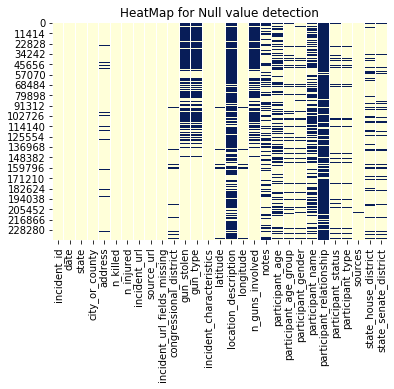

```python
#Investigating Dataset 1 for Null values for Data Cleaning using heatmap
sns.heatmap(df_crime.isnull(), cbar=False,cmap="YlGnBu");
plt.title('HeatMap for Null value detection')
plt.savefig("data_cleaning_1.png")
```

```python
# Find day from date column store as "day" field
def findDay(date):
    year, month, day = (int(i) for i in date.split('-'))
    born = datetime.date(year, month, day)
    return born.strftime("%A")
day=[]

for date in df_crime['date']:
    day.append(findDay(date))

df_crime['day']=day

# Find month from date column store as "month" field
def findMonth(date):
    year, month, day = (int(i) for i in date.split('-'))
    born = datetime.date(year, month, day)
    return born.strftime("%B")
month_value=[]
# Driver program
for date in df_crime['date']:
   month_value.append(findMonth(date))

df_crime['month']=month_value

# Find year from date column store as "year" field
def findYear(date):
    year, month, day = (int(i) for i in date.split('-'))
    born = datetime.date(year, month, day)
    return born.strftime("%Y")
year_value=[]
# Driver program
for date in df_crime['date']:
   year_value.append(findYear(date))

df_crime['year']=year_value
```

```python
# Calculate total persons involed in gun shooting incident as store as "total_person" field
df_crime['total_person']=df_crime.n_killed + df_crime.n_injured

df_crime.loc[df_crime['total_person'] == 0,'participant_gender'] = np.nan
```

```python
# Find Male participant count in incident and store as "male" filed
def findmalegender(gender):

    if type(gender)==str:
        count_value=gender.count("Male")
        if count_value == 0:
            return 0
        else:
            return count_value
    else:
        return 0
Male_value=[]


for gender in df_crime['participant_gender']:
   Male_value.append(findmalegender(gender))

df_crime['male']=Male_value

# Find Female participant count in incident and store as "Female" filed
def findfemalegender(gender):

    if type(gender)==str:
        count_value=gender.count("Female")
        if count_value == 0:
            return 0
        else:
            return count_value
    else:
        return 0
Female_value=[]


for gender in df_crime['participant_gender']:
   Female_value.append(findfemalegender(gender))

df_crime['Female']=Female_value

# Find  participant age in incident and store as "Age" filed
def findage(age):

    if type(age)==str:
        nested = re.findall('(?<=::)\d+',age)

        return list(map(int, nested))

age_value=[]


for age in df_crime['participant_age']:
   age_value.append(findage(age))

df_crime['Age']=age_value
```

```python
# Removing some mismatch values in male and female count.
df_crime.male=(df_crime.male-(df_crime.male-df_crime.total_person))-df_crime.Female
df_crime.loc[df_crime['male'] < 0, 'male'] = 0
df_crime.loc[df_crime['male'] == 0, 'Female']=df_crime['total_person']
```

```python
# Dropping unnessary field from dataset that we will not be using for analysis purpose.
df_crime.drop(labels=['incident_id','incident_url','latitude','longitude','gun_type','source_url','incident_url_fields_missing','location_description','congressional_district','notes','sources','state_house_district','participant_status','state_senate_district','participant_type','participant_relationship','participant_name','participant_gender','participant_age_group','participant_age','incident_characteristics','address','gun_stolen'],axis=1,inplace=True)
```

### Final Data set after Data cleaning and Imputation

After Data cleaning and data modification final dataset that will be used for answering data analytics Questions.

```python
# Final dataset after our data cleaning and investigating for data discrepancy.
# Final Dataset1 after our data cleaning this is the main dataset that we will be focusing on.
df_crime.info()
```

```
<class 'pandas.core.frame.DataFrame'>
RangeIndex: 239677 entries, 0 to 239676
Data columns (total 13 columns):
 #   Column           Non-Null Count   Dtype
---  ------           --------------   -----
 0   date             239677 non-null  object
 1   state            239677 non-null  object
 2   city_or_county   239677 non-null  object
 3   n_killed         239677 non-null  int64
 4   n_injured        239677 non-null  int64
 5   n_guns_involved  140226 non-null  float64
 6   day              239677 non-null  object
 7   month            239677 non-null  object
 8   year             239677 non-null  object
 9   total_person     239677 non-null  int64
 10  male             239677 non-null  int64
 11  Female           239677 non-null  int64
 12  Age              147379 non-null  object
dtypes: float64(1), int64(5), object(7)
memory usage: 23.8+ MB
```

```python
#Final dataset2 that we will be using for risk prediction analysis.
dataset2.info()
```

```
<class 'pandas.core.frame.DataFrame'>
RangeIndex: 52 entries, 0 to 51
Data columns (total 20 columns):
 #   Column           Non-Null Count  Dtype
---  ------           --------------  -----
 0   State            51 non-null     object
 1   Pop              51 non-null     float64
 2   Per_Capita_2018  51 non-null     float64
 3   Per_Capita_2017  51 non-null     float64
 4   Per_Capita_2016  51 non-null     float64
 5   Per_Capita_2015  51 non-null     float64
 6   Per_Capita_2014  51 non-null     float64
 7   Per_Capita_2013  51 non-null     float64
 8   Une_Rate_2018    51 non-null     float64
 9   Une_Rank_2018    51 non-null     float64
 10  Une_Rate_2017    51 non-null     float64
 11  Une_Rank_2017    51 non-null     float64
 12  Une_Rate_2016    51 non-null     float64
 13  Une_Rank_2016    51 non-null     float64
 14  Une_Rate_2015    51 non-null     float64
 15  Une_Rank_2015    51 non-null     float64
 16  Une_Rate_2014    51 non-null     float64
 17  Une_Rank_2014    51 non-null     float64
 18  Une_Rate_2013    51 non-null     float64
 19  Une_Rank_2013    51 non-null     float64
dtypes: float64(19), object(1)
memory usage: 8.2+ KB
```

## Data Analysis Interpretation

## Correlation between the Data

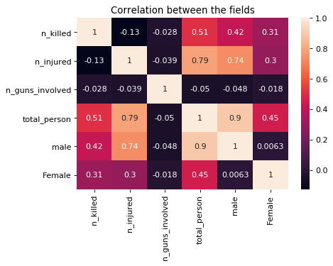

```python
#To find any relationship or correlation between the fields in our main dataset(Dataset1)
corrMatrix = df_crime[['n_killed','n_injured','n_guns_involved','total_person','male','Female']].corr()
plt.figure(figsize=(6,4), dpi= 80)
sns.heatmap(corrMatrix, annot=True)
plt.title('Correlation between the fields')
plt.savefig("Corr_data_1.png")
plt.show()
```

## What age group is most affected in USA Gun Shooting Data between 2013-2018?

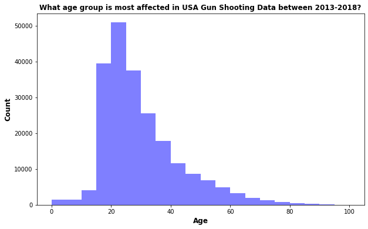

```python
#preliminary analysis of "Age" field in Dataset1
Age = []
def reemovNestings(l):
    for i in l:
        if type(i) == list:
            reemovNestings(i)
        else:
            Age.append(i)

# Driver code
reemovNestings(df_crime.Age)
df_Age = DataFrame(Age,columns=['Age'])
df_Age=df_Age.query('Age <=100')

fig, ax = plt.subplots(figsize=(10,6))

num_bins = 20
# the histogram of the "Age" filed.
ax.hist(df_Age['Age'], num_bins, facecolor='blue', alpha=0.5)
plt.xlabel('Age', fontsize = 12, weight = 'bold')
plt.ylabel('Count', fontsize = 12, weight = 'bold')
plt.title('What age group is most affected in USA Gun Shooting Data between 2013-2018?', fontsize = 12, weight = 'bold')

plt.savefig("Age_1.png");
plt.show()
```

```python
round(df_Age['Age'].mean())
```

```
29
```

```python
round(df_Age['Age'].median())
```

```
26
```

```python
round(df_Age['Age'].mode())
```

```
0    19.0
dtype: float64
```

```python
df_Age.describe()
```

|  | Age |
| --- | --- |
| count | 218374.000000 |
| mean | 29.470628 |
| std | 13.089155 |
| min | 0.000000 |
| 25% | 20.000000 |
| 50% | 26.000000 |
| 75% | 35.000000 |
| max | 100.000000 |

```python
#Highest numebr of victims are aged 19 and count of it calculated
df_Age.query('Age==19').count()
```

```
Age    11535
dtype: int64
```

```python
#Count of victims less than 20 years Age
df_Age.query('Age<20').count()
```

```
Age    46446
dtype: int64
```

```python
#Count of victims more than or equal to age 20 and less than 40 years Age
df_Age.query('Age>=20 and Age<40').count()
```

```
Age    131795
dtype: int64
```

```python
#Count of victims greater than 40 years Age
df_Age.query('Age>=40').count()
```

```
Age    40133
dtype: int64
```

## Which USA State is the Dangerous based on the Gun shooting Data from 2013-2018?

```python
#Group by "State" field and sum the values in each filed.
df_state=df_crime.groupby('state',as_index=False).sum()
```

```python
df_state.sort_values('total_person',ascending=True,inplace=True)
```

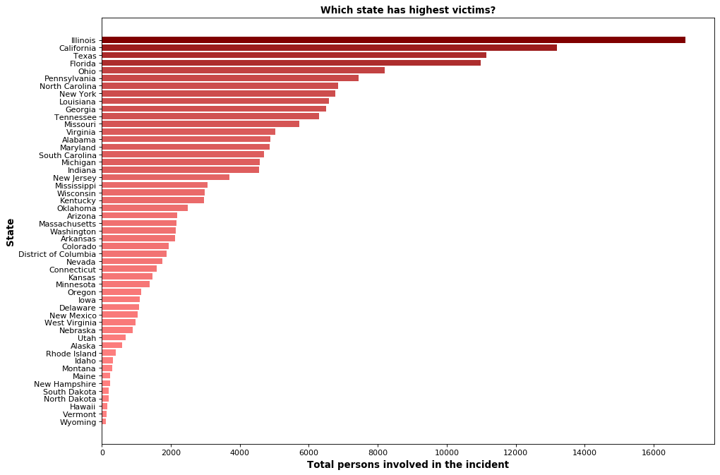

```python
# Colorize the graph based on likeability:
likeability_scores = np.array(df_state.total_person)

data_normalizer = mp.colors.Normalize()
color_map = mp.colors.LinearSegmentedColormap(
    "my_map",
    {
        "red": [(0, 1.0, 1.0),
                (1.0, .5, .5)],
        "green": [(0, 0.5, 0.5),
                  (1.0, 0, 0)],
        "blue": [(0, 0.50, 0.5),
                 (1.0, 0, 0)]
    }
)

plt.figure(figsize=(14,10), dpi= 80)
# Horizontal bar to dispaly the state wise victim count.
plt.barh(df_state.state, df_state.total_person, align='center',color=color_map(data_normalizer(likeability_scores)))


plt.ylabel('State', fontsize = 12, weight = 'bold')
plt.xlabel('Total persons involved in the incident', fontsize = 12, weight = 'bold')
plt.title('Which state has highest victims?', fontsize = 12, weight = 'bold')
plt.savefig("state_safe_1.png")
plt.show()
df_state.sort_values('total_person',ascending=False,inplace=True)
```

## Which Gender is most affected over the years from 2013 to 2018?

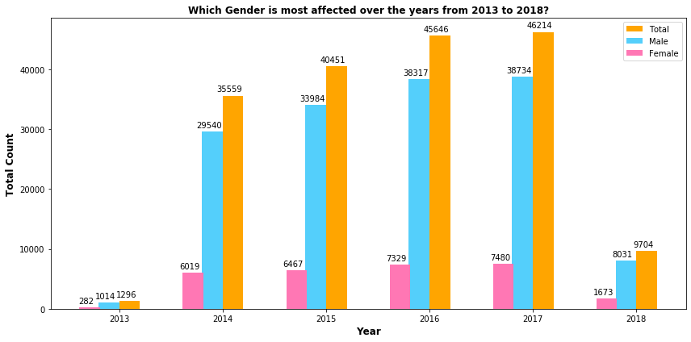

```python
#Group by "year" field and sum the values in each filed.
df_year=df_crime.groupby(['year'],as_index=False,observed= True).sum()
labels = [2013, 2014, 2015, 2016, 2017,2018]
men = df_year.male
women = df_year.Female
total = df_year.total_person

x = np.arange(len(labels))  # the label locations
width = 0.2  # the width of the bars

fig, ax = plt.subplots(figsize=(12,6))
# Bar chart for total victim count for each years from 2013 to 2018
rects1 = ax.bar(x + width/2, total, width, label='Total',color='orange')
# Bar chart for "Male" victim count for each years from 2013 to 2018
rects2 = ax.bar(x - width/2, men, width, label='Male',color='#54CFFB')
# Bar chart for "Female" victim count for each years from 2013 to 2018
rects3 = ax.bar(x - width/.7, women, width, label='Female',color='#ff77b4')

# Add some text for labels, title and custom x-axis tick labels, etc.
ax.set_xlabel('Year', fontsize = 12, weight = 'bold')
ax.set_ylabel('Total Count', fontsize = 12, weight = 'bold')
ax.set_title('Which Gender is most affected over the years from 2013 to 2018?', fontsize = 12, weight = 'bold')
ax.set_xticks(x)
ax.set_xticklabels(labels)
ax.legend()

# Display labels for victim counts
def autolabel(rects):
    """Attach a text label above each bar in *rects*, displaying its height."""
    for rect in rects:
        height = rect.get_height()
        ax.annotate('{}'.format(height),
                    xy=(rect.get_x() + rect.get_width() / 3, height),
                    xytext=(0, 3),  # 3 points vertical offset
                    textcoords="offset points",
                    ha='center', va='bottom')


autolabel(rects1)
autolabel(rects2)
autolabel(rects3)

fig.tight_layout()
plt.savefig("Gender_year_1.png")
plt.show()
```

# Prediction based on Kmeans clustering

## Which USA states are highly dangerous and safe from Gun violance?

```python
#Group by "State" field and sum the values in each filed.

df_state=df_crime.groupby('state',as_index=False)['date'].count()

df_state.drop(labels=['date'],axis=1,inplace=True)
#Spliting the victim count for each "state" and "year" and storing in new fields
x=df_crime.groupby(['state','year'],as_index=False).sum().query('year=="2013"')[['state','total_person']]
df_state=pd.merge(df_state,x, on='state',how = 'left')
df_state.rename(columns={'total_person': 'total_2013'}, inplace=True)
x=df_crime.groupby(['state','year'],as_index=False).sum().query('year=="2014"')[['state','total_person']]
df_state=pd.merge(df_state,x, on='state',how = 'left')
df_state.rename(columns={'total_person': 'total_2014'}, inplace=True)
x=df_crime.groupby(['state','year'],as_index=False).sum().query('year=="2015"')[['state','total_person']]
df_state=pd.merge(df_state,x, on='state',how = 'left')
df_state.rename(columns={'total_person': 'total_2015'}, inplace=True)
x=df_crime.groupby(['state','year'],as_index=False).sum().query('year=="2016"')[['state','total_person']]
df_state=pd.merge(df_state,x, on='state',how = 'left')
df_state.rename(columns={'total_person': 'total_2016'}, inplace=True)
x=df_crime.groupby(['state','year'],as_index=False).sum().query('year=="2017"')[['state','total_person']]
df_state=pd.merge(df_state,x, on='state',how = 'left')
df_state.rename(columns={'total_person': 'total_2017'}, inplace=True)
x=df_crime.groupby(['state','year'],as_index=False).sum().query('year=="2018"')[['state','total_person']]
df_state=pd.merge(df_state,x, on='state',how = 'left')
df_state.rename(columns={'total_person': 'total_2018'}, inplace=True)

#Spliting the incident count for each "state" and "year" and storing in new fields
x=df_crime.groupby(['state','year'],as_index=False).count().query('year=="2013"')[['state','total_person']]
df_state=pd.merge(df_state,x, on='state',how = 'left')
df_state.rename(columns={'total_person': 'incident_2013'}, inplace=True)
x=df_crime.groupby(['state','year'],as_index=False).count().query('year=="2014"')[['state','total_person']]
df_state=pd.merge(df_state,x, on='state',how = 'left')
df_state.rename(columns={'total_person': 'incident_2014'}, inplace=True)
x=df_crime.groupby(['state','year'],as_index=False).count().query('year=="2015"')[['state','total_person']]
df_state=pd.merge(df_state,x, on='state',how = 'left')
df_state.rename(columns={'total_person': 'incident_2015'}, inplace=True)
x=df_crime.groupby(['state','year'],as_index=False).count().query('year=="2016"')[['state','total_person']]
df_state=pd.merge(df_state,x, on='state',how = 'left')
df_state.rename(columns={'total_person': 'incident_2016'}, inplace=True)
x=df_crime.groupby(['state','year'],as_index=False).count().query('year=="2017"')[['state','total_person']]
df_state=pd.merge(df_state,x, on='state',how = 'left')
df_state.rename(columns={'total_person': 'incident_2017'}, inplace=True)
x=df_crime.groupby(['state','year'],as_index=False).count().query('year=="2018"')[['state','total_person']]
df_state=pd.merge(df_state,x, on='state',how = 'left')
df_state.rename(columns={'total_person': 'incident_2018'}, inplace=True)

df_state.fillna(0,inplace=True)
```

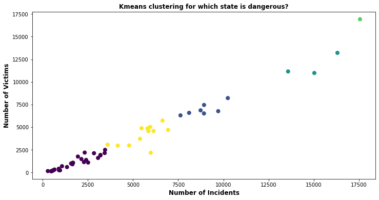

```python
#Kmeans clustering for predicting dangerous "state" based on total victims and total incident for each years.
kmeans = KMeans(n_clusters=5)
predict= kmeans.fit_predict(df_state[['incident_2013','incident_2014','incident_2015','incident_2016','incident_2017','incident_2018','total_2013','total_2014','total_2015','total_2016','total_2017','total_2018']])
# storing cluster number after kmeans fit.
df_state['cluster']=predict
incidents=df_crime.groupby('state',as_index=False)['date'].count()

df_state['incidents']=incidents['date']
total_victim=df_crime.groupby('state',as_index=False).sum()

df_state['total_victim']=total_victim['total_person']

fig, ax = plt.subplots(figsize=(12,6))
#Scatter plot for incident vs victims and kmeans cluster number.
ax.scatter(df_state['incidents'],df_state['total_victim'], c=predict, s=50, cmap='viridis');
plt.xlabel('Number of Incidents', fontsize = 12, weight = 'bold')
plt.ylabel('Number of Victims', fontsize = 12, weight = 'bold')
plt.title('Kmeans clustering for which state is dangerous?', fontsize = 12, weight = 'bold')
plt.savefig("kmeans_state_1.png")

plt.show()
```

```python
df_state.groupby('cluster',as_index=False).count()['state']
```

```
0    28
1     7
2     3
3     1
4    12
Name: state, dtype: int64
```

```python
# cluster 0
df_state.query('cluster==0')['state']
```

```
1                   Alaska
2                  Arizona
3                 Arkansas
5                 Colorado
6              Connecticut
7                 Delaware
8     District of Columbia
11                  Hawaii
12                   Idaho
15                    Iowa
16                  Kansas
19                   Maine
23               Minnesota
26                 Montana
27                Nebraska
28                  Nevada
29           New Hampshire
31              New Mexico
34            North Dakota
36                Oklahoma
37                  Oregon
39            Rhode Island
41            South Dakota
44                    Utah
45                 Vermont
47              Washington
48           West Virginia
50                 Wyoming
Name: state, dtype: object
```

```python
# cluster 1
df_state.query('cluster==1')['state']
```

```
10           Georgia
18         Louisiana
32          New York
33    North Carolina
35              Ohio
38      Pennsylvania
42         Tennessee
Name: state, dtype: object
```

```python
# cluster 2
df_state.query('cluster==2')['state']
```

```
4     California
9        Florida
43         Texas
Name: state, dtype: object
```

```python
# cluster 3
df_state.query('cluster==3')['state']
```

```
13    Illinois
Name: state, dtype: object
```

```python
# cluster 4
df_state.query('cluster==4')['state']
```

```
0            Alabama
14           Indiana
17          Kentucky
20          Maryland
21     Massachusetts
22          Michigan
24       Mississippi
25          Missouri
30        New Jersey
40    South Carolina
46          Virginia
49         Wisconsin
Name: state, dtype: object
```

```python
df_state
```

|  | state | total_2013 | total_2014 | total_2015 | total_2016 | total_2017 | total_2018 | incident_2013 | incident_2014 | incident_2015 | incident_2016 | incident_2017 | incident_2018 | cluster | incidents | total_victim |
| --- | --- | --- | --- | --- | --- | --- | --- | --- | --- | --- | --- | --- | --- | --- | --- | --- |
| 0 | Alabama | 12.0 | 916 | 947 | 1249 | 1400 | 354 | 2.0 | 1318 | 1034 | 1309 | 1461 | 347 | 4 | 5471 | 4878 |
| 1 | Alaska | 0.0 | 78 | 154 | 191 | 139 | 30 | 0.0 | 146 | 380 | 445 | 317 | 61 | 0 | 1349 | 592 |
| 2 | Arizona | 24.0 | 442 | 408 | 571 | 587 | 158 | 5.0 | 556 | 480 | 554 | 587 | 146 | 0 | 2328 | 2190 |
| 3 | Arkansas | 0.0 | 400 | 400 | 541 | 653 | 126 | 0.0 | 572 | 538 | 720 | 820 | 192 | 0 | 2842 | 2120 |
| 4 | California | 185.0 | 2927 | 2821 | 3161 | 3376 | 736 | 39.0 | 3732 | 3234 | 3617 | 4588 | 1096 | 2 | 16306 | 13206 |
| 5 | Colorado | 13.0 | 313 | 458 | 506 | 499 | 140 | 3.0 | 556 | 788 | 812 | 809 | 233 | 0 | 3201 | 1929 |
| 6 | Connecticut | 15.0 | 281 | 421 | 426 | 382 | 74 | 3.0 | 583 | 737 | 803 | 780 | 161 | 0 | 3067 | 1599 |
| 7 | Delaware | 13.0 | 231 | 264 | 229 | 297 | 36 | 3.0 | 493 | 366 | 328 | 389 | 106 | 0 | 1685 | 1070 |
| 8 | District of Columbia | 44.0 | 390 | 469 | 445 | 440 | 86 | 6.0 | 838 | 538 | 497 | 1142 | 174 | 0 | 3195 | 1874 |
| 9 | Florida | 58.0 | 2336 | 2343 | 2847 | 2751 | 646 | 13.0 | 3138 | 2702 | 4201 | 4156 | 819 | 2 | 15029 | 10981 |
| 10 | Georgia | 31.0 | 1339 | 1691 | 1405 | 1715 | 331 | 6.0 | 2032 | 2767 | 1708 | 1994 | 418 | 1 | 8925 | 6512 |
| 11 | Hawaii | 0.0 | 21 | 39 | 51 | 28 | 9 | 0.0 | 48 | 75 | 79 | 68 | 19 | 0 | 289 | 148 |
| 12 | Idaho | 0.0 | 57 | 76 | 78 | 81 | 23 | 0.0 | 115 | 177 | 155 | 163 | 51 | 0 | 661 | 315 |
| 13 | Illinois | 92.0 | 2913 | 3510 | 5083 | 4588 | 737 | 18.0 | 3095 | 3456 | 5055 | 5089 | 843 | 3 | 17556 | 16923 |
| 14 | Indiana | 29.0 | 930 | 1049 | 1185 | 1144 | 227 | 7.0 | 1203 | 1320 | 1511 | 1483 | 328 | 4 | 5852 | 4564 |
| 15 | Iowa | 0.0 | 231 | 253 | 264 | 300 | 46 | 0.0 | 569 | 587 | 659 | 586 | 116 | 0 | 2517 | 1094 |
| 16 | Kansas | 20.0 | 252 | 317 | 375 | 416 | 93 | 4.0 | 381 | 461 | 572 | 578 | 149 | 0 | 2145 | 1473 |
| 17 | Kentucky | 13.0 | 512 | 655 | 787 | 791 | 202 | 3.0 | 977 | 914 | 1021 | 1030 | 212 | 4 | 4157 | 2960 |
| 18 | Louisiana | 60.0 | 1386 | 1399 | 1630 | 1733 | 369 | 9.0 | 1906 | 1692 | 2070 | 1987 | 439 | 1 | 8103 | 6577 |
| 19 | Maine | 0.0 | 47 | 62 | 55 | 69 | 11 | 0.0 | 183 | 231 | 232 | 203 | 58 | 0 | 907 | 244 |
| 20 | Maryland | 21.0 | 896 | 1187 | 1177 | 1335 | 242 | 5.0 | 1266 | 1284 | 1293 | 1579 | 371 | 4 | 5798 | 4858 |
| 21 | Massachusetts | 0.0 | 416 | 491 | 580 | 584 | 102 | 0.0 | 968 | 1338 | 1544 | 1761 | 370 | 4 | 5981 | 2173 |
| 22 | Michigan | 71.0 | 977 | 995 | 1085 | 1140 | 310 | 14.0 | 1447 | 1268 | 1316 | 1360 | 731 | 4 | 6136 | 4578 |
| 23 | Minnesota | 8.0 | 279 | 278 | 325 | 397 | 90 | 2.0 | 450 | 410 | 468 | 759 | 319 | 0 | 2408 | 1377 |
| 24 | Mississippi | 8.0 | 548 | 557 | 787 | 917 | 242 | 2.0 | 784 | 661 | 852 | 1029 | 271 | 4 | 3599 | 3059 |
| 25 | Missouri | 48.0 | 1030 | 1413 | 1357 | 1530 | 343 | 10.0 | 1272 | 1702 | 1552 | 1730 | 365 | 4 | 6631 | 5721 |
| 26 | Montana | 0.0 | 62 | 72 | 64 | 74 | 18 | 0.0 | 128 | 140 | 162 | 167 | 41 | 0 | 638 | 290 |
| 27 | Nebraska | 4.0 | 199 | 236 | 219 | 199 | 42 | 1.0 | 347 | 374 | 381 | 439 | 109 | 0 | 1651 | 899 |
| 28 | Nevada | 4.0 | 303 | 417 | 491 | 418 | 117 | 1.0 | 376 | 491 | 536 | 437 | 111 | 0 | 1952 | 1750 |
| 29 | New Hampshire | 0.0 | 60 | 48 | 60 | 53 | 11 | 0.0 | 230 | 209 | 272 | 206 | 47 | 0 | 964 | 232 |
| 30 | New Jersey | 44.0 | 906 | 740 | 951 | 938 | 129 | 14.0 | 1521 | 1062 | 1224 | 1342 | 224 | 4 | 5387 | 3708 |
| 31 | New Mexico | 9.0 | 172 | 275 | 255 | 266 | 61 | 2.0 | 320 | 395 | 399 | 448 | 81 | 0 | 1645 | 1038 |
| 32 | New York | 71.0 | 1362 | 1984 | 1691 | 1439 | 217 | 16.0 | 1903 | 2903 | 2522 | 2031 | 337 | 1 | 9712 | 6764 |
| 33 | North Carolina | 52.0 | 1371 | 1589 | 1781 | 1709 | 352 | 12.0 | 2165 | 1856 | 2101 | 2141 | 464 | 1 | 8739 | 6854 |
| 34 | North Dakota | 0.0 | 39 | 51 | 51 | 48 | 10 | 0.0 | 110 | 149 | 150 | 133 | 31 | 0 | 573 | 199 |
| 35 | Ohio | 40.0 | 1614 | 1841 | 2083 | 2217 | 416 | 10.0 | 2368 | 2132 | 2442 | 2701 | 591 | 1 | 10244 | 8211 |
| 36 | Oklahoma | 26.0 | 409 | 630 | 657 | 633 | 136 | 6.0 | 642 | 840 | 898 | 866 | 203 | 0 | 3455 | 2491 |
| 37 | Oregon | 0.0 | 222 | 316 | 263 | 269 | 70 | 0.0 | 398 | 686 | 552 | 511 | 139 | 0 | 2286 | 1140 |
| 38 | Pennsylvania | 71.0 | 1835 | 1572 | 1776 | 1823 | 374 | 20.0 | 2267 | 1789 | 2185 | 2172 | 496 | 1 | 8929 | 7451 |
| 39 | Rhode Island | 8.0 | 94 | 101 | 98 | 90 | 18 | 2.0 | 189 | 226 | 237 | 191 | 50 | 0 | 895 | 409 |
| 40 | South Carolina | 23.0 | 970 | 1121 | 1113 | 1186 | 281 | 5.0 | 1660 | 1696 | 1490 | 1721 | 367 | 4 | 6939 | 4694 |
| 41 | South Dakota | 0.0 | 36 | 53 | 55 | 40 | 20 | 0.0 | 72 | 103 | 144 | 199 | 26 | 0 | 544 | 204 |
| 42 | Tennessee | 43.0 | 1209 | 1416 | 1633 | 1693 | 308 | 10.0 | 1590 | 1763 | 2014 | 1874 | 375 | 1 | 7626 | 6302 |
| 43 | Texas | 65.0 | 2251 | 2491 | 2927 | 2734 | 684 | 11.0 | 3133 | 3276 | 3606 | 2875 | 676 | 2 | 13577 | 11152 |
| 44 | Utah | 5.0 | 131 | 169 | 156 | 180 | 43 | 1.0 | 217 | 324 | 250 | 224 | 56 | 0 | 1072 | 684 |
| 45 | Vermont | 0.0 | 47 | 33 | 23 | 20 | 7 | 0.0 | 170 | 117 | 94 | 71 | 20 | 0 | 472 | 130 |
| 46 | Virginia | 32.0 | 862 | 1099 | 1449 | 1324 | 259 | 6.0 | 1273 | 1326 | 1578 | 1473 | 293 | 4 | 5949 | 5025 |
| 47 | Washington | 20.0 | 417 | 500 | 484 | 582 | 137 | 4.0 | 656 | 925 | 768 | 881 | 200 | 0 | 3434 | 2140 |
| 48 | West Virginia | 10.0 | 189 | 217 | 274 | 237 | 57 | 2.0 | 362 | 342 | 399 | 390 | 80 | 0 | 1575 | 984 |
| 49 | Wisconsin | 4.0 | 624 | 787 | 672 | 728 | 164 | 1.0 | 1065 | 1117 | 859 | 1369 | 376 | 4 | 4787 | 2979 |
| 50 | Wyoming | 0.0 | 27 | 36 | 30 | 22 | 10 | 0.0 | 64 | 198 | 127 | 91 | 14 | 0 | 494 | 125 |

## Which USA Cities are Dangerous and safe from Gun violance?

```python
#Group by "city_or_county" field and sum the values in each filed.
df_city=df_crime.groupby('city_or_county',as_index=False)['date'].count()

df_city.drop(labels=['date'],axis=1,inplace=True)
#Spliting the victim count for each "city_or_county" and "year" and storing in new fields
x=df_crime.groupby(['city_or_county','year'],as_index=False).sum().query('year=="2013"')[['city_or_county','total_person']]
df_city=pd.merge(df_city,x, on='city_or_county',how = 'left')
df_city.rename(columns={'total_person': 'total_2013'}, inplace=True)
x=df_crime.groupby(['city_or_county','year'],as_index=False).sum().query('year=="2014"')[['city_or_county','total_person']]
df_city=pd.merge(df_city,x, on='city_or_county',how = 'left')
df_city.rename(columns={'total_person': 'total_2014'}, inplace=True)
x=df_crime.groupby(['city_or_county','year'],as_index=False).sum().query('year=="2015"')[['city_or_county','total_person']]
df_city=pd.merge(df_city,x, on='city_or_county',how = 'left')
df_city.rename(columns={'total_person': 'total_2015'}, inplace=True)
x=df_crime.groupby(['city_or_county','year'],as_index=False).sum().query('year=="2016"')[['city_or_county','total_person']]
df_city=pd.merge(df_city,x, on='city_or_county',how = 'left')
df_city.rename(columns={'total_person': 'total_2016'}, inplace=True)
x=df_crime.groupby(['city_or_county','year'],as_index=False).sum().query('year=="2017"')[['city_or_county','total_person']]
df_city=pd.merge(df_city,x, on='city_or_county',how = 'left')
df_city.rename(columns={'total_person': 'total_2017'}, inplace=True)
x=df_crime.groupby(['city_or_county','year'],as_index=False).sum().query('year=="2018"')[['city_or_county','total_person']]
df_city=pd.merge(df_city,x, on='city_or_county',how = 'left')
df_city.rename(columns={'total_person': 'total_2018'}, inplace=True)

#Spliting the incident count for each "city_or_county" and "year" and storing in new fields
x=df_crime.groupby(['city_or_county','year'],as_index=False).count().query('year=="2013"')[['city_or_county','total_person']]
df_city=pd.merge(df_city,x, on='city_or_county',how = 'left')
df_city.rename(columns={'total_person': 'incident_2013'}, inplace=True)
x=df_crime.groupby(['city_or_county','year'],as_index=False).count().query('year=="2014"')[['city_or_county','total_person']]
df_city=pd.merge(df_city,x, on='city_or_county',how = 'left')
df_city.rename(columns={'total_person': 'incident_2014'}, inplace=True)
x=df_crime.groupby(['city_or_county','year'],as_index=False).count().query('year=="2015"')[['city_or_county','total_person']]
df_city=pd.merge(df_city,x, on='city_or_county',how = 'left')
df_city.rename(columns={'total_person': 'incident_2015'}, inplace=True)
x=df_crime.groupby(['city_or_county','year'],as_index=False).count().query('year=="2016"')[['city_or_county','total_person']]
df_city=pd.merge(df_city,x, on='city_or_county',how = 'left')
df_city.rename(columns={'total_person': 'incident_2016'}, inplace=True)
x=df_crime.groupby(['city_or_county','year'],as_index=False).count().query('year=="2017"')[['city_or_county','total_person']]
df_city=pd.merge(df_city,x, on='city_or_county',how = 'left')
df_city.rename(columns={'total_person': 'incident_2017'}, inplace=True)
x=df_crime.groupby(['city_or_county','year'],as_index=False).count().query('year=="2018"')[['city_or_county','total_person']]
df_city=pd.merge(df_city,x, on='city_or_county',how = 'left')
df_city.rename(columns={'total_person': 'incident_2018'}, inplace=True)

df_city.fillna(0,inplace=True)
```

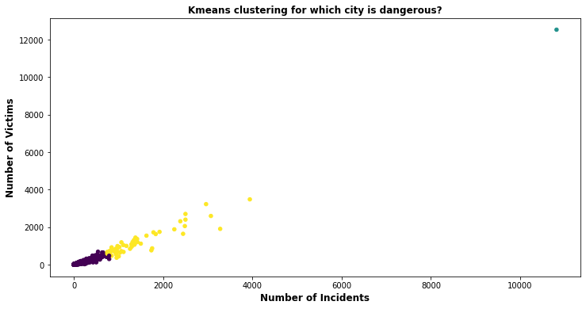

```python
#Kmeans clustering for predicting dangerous "city_or_county" based on total victims and total incident for each years.
kmeans = KMeans(n_clusters=3)
predict= kmeans.fit_predict(df_city[['incident_2013','incident_2014','incident_2015','incident_2016','incident_2017','incident_2018','total_2013','total_2014','total_2015','total_2016','total_2017','total_2018']])
# storing cluster number after kmeans fit.
df_city['cluster']=predict
incidents=df_crime.groupby('city_or_county',as_index=False)['date'].count()

df_city['incidents']=incidents['date']
total_victim=df_crime.groupby('city_or_county',as_index=False).sum()

df_city['total_victim']=total_victim['total_person']
fig, ax = plt.subplots(figsize=(12,6))

#Scatter plot for incident vs victims and kmeans cluster number.
ax.scatter(df_city['incidents'],df_city['total_victim'] , c=predict, s=20, cmap='viridis')
plt.xlabel('Number of Incidents', fontsize = 12, weight = 'bold')
plt.ylabel('Number of Victims', fontsize = 12, weight = 'bold')
plt.title('Kmeans clustering for which city is dangerous?', fontsize = 12, weight = 'bold')
plt.savefig("kmeans_city_1.png")
plt.show()
```

```python
df_city.groupby('cluster').count()['city_or_county']
```

```
cluster
0    12842
1        1
2       55
Name: city_or_county, dtype: int64
```

```python
# cluster 1
#Most dangerous city or county in USA
df_city.query('cluster==1')
```

|  | city_or_county | total_2013 | total_2014 | total_2015 | total_2016 | total_2017 | total_2018 | incident_2013 | incident_2014 | incident_2015 | incident_2016 | incident_2017 | incident_2018 | cluster | incidents | total_victim |
| --- | --- | --- | --- | --- | --- | --- | --- | --- | --- | --- | --- | --- | --- | --- | --- | --- |
| 2019 | Chicago | 77.0 | 2307.0 | 2771.0 | 3553.0 | 3304.0 | 519.0 | 15.0 | 2042.0 | 2369.0 | 3075.0 | 2812.0 | 501.0 | 1 | 10814 | 12531 |

```python
# cluster 2
#Second and third dangerous city or county in USA with highest victim
df_city.query('cluster==2').sort_values(['total_victim'],ascending=False).head(2)
```

|  | city_or_county | total_2013 | total_2014 | total_2015 | total_2016 | total_2017 | total_2018 | incident_2013 | incident_2014 | incident_2015 | incident_2016 | incident_2017 | incident_2018 | cluster | incidents | total_victim |
| --- | --- | --- | --- | --- | --- | --- | --- | --- | --- | --- | --- | --- | --- | --- | --- | --- |
| 530 | Baltimore | 21.0 | 614.0 | 877.0 | 846.0 | 955.0 | 169.0 | 5.0 | 760.0 | 911.0 | 919.0 | 1113.0 | 235.0 | 2 | 3943 | 3482 |
| 9018 | Philadelphia | 29.0 | 1030.0 | 619.0 | 712.0 | 683.0 | 154.0 | 9.0 | 1049.0 | 535.0 | 659.0 | 581.0 | 130.0 | 2 | 2963 | 3227 |

```python
# cluster 2
#Second and third dangerous city or county in USA with highest incident
df_city.query('cluster==2').sort_values(['incidents'],ascending=False).head(2)
```

|  | city_or_county | total_2013 | total_2014 | total_2015 | total_2016 | total_2017 | total_2018 | incident_2013 | incident_2014 | incident_2015 | incident_2016 | incident_2017 | incident_2018 | cluster | incidents | total_victim |
| --- | --- | --- | --- | --- | --- | --- | --- | --- | --- | --- | --- | --- | --- | --- | --- | --- |
| 530 | Baltimore | 21.0 | 614.0 | 877.0 | 846.0 | 955.0 | 169.0 | 5.0 | 760.0 | 911.0 | 919.0 | 1113.0 | 235.0 | 2 | 3943 | 3482 |
| 12154 | Washington | 30.0 | 400.0 | 480.0 | 455.0 | 453.0 | 89.0 | 5.0 | 850.0 | 553.0 | 521.0 | 1171.0 | 179.0 | 2 | 3279 | 1907 |

# Prediction based on linkage clustering

## Which Day of week has high chances of Gun violance?

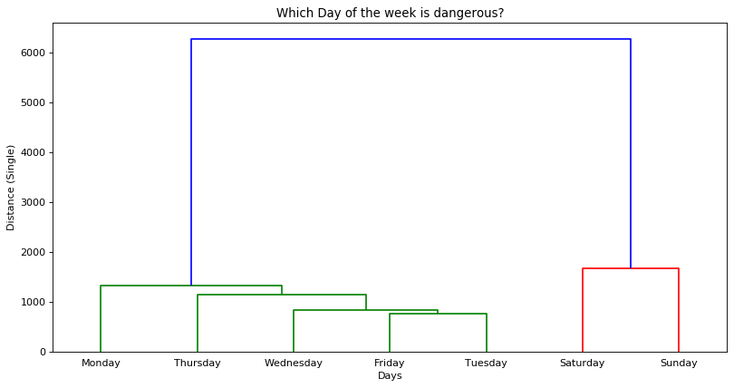

```python
#Group by "Day" field and sum the values in each filed.
df_day2=df_crime.groupby('day').sum()
df_day2.drop(labels=['n_killed','n_injured','n_guns_involved','male','Female'],axis=1,inplace=True)
incidents=df_crime.groupby('day')['date'].count()

df_day2['incidents']=incidents
Z = linkage(df_day2, 'single')
plt.figure(figsize=(12,6), dpi= 80)
#Dendrogram for to display which day of the week is dangerous.
dendrogram(Z, labels=df_day2.index,leaf_font_size=10);
plt.xlabel('Days')
plt.ylabel('Distance (Single)');
plt.title("Which Day of the week is dangerous?")
plt.savefig("Linkage_day_1.png");
```

## Which Month of year has high chances of Gun violance?

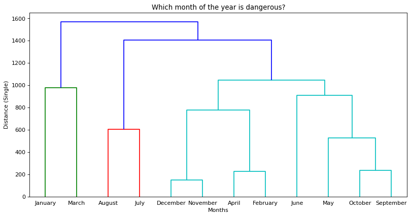

```python
#Group by "Month" field and sum the values in each filed.
df_month2=df_crime.groupby('month').sum()
df_month2.drop(labels=['n_killed','n_injured','n_guns_involved','male','Female'],axis=1,inplace=True)
incidents=df_crime.groupby('month')['date'].count()

df_month2['incidents']=incidents
Z = linkage(df_month2, 'single')
plt.figure(figsize=(12,6), dpi= 80)

#Dendrogram for to display which month of the year is dangerous.
dendrogram(Z, labels=df_month2.index,leaf_font_size=10);
plt.xlabel('Months')
plt.ylabel('Distance (Single)');
plt.title("Which month of the year is dangerous?");
plt.savefig("Linkage_year_1.png") ;
```

## Which Top 3 US state has Highest and Lowest Kills, Injured, Guns Involved, Incidents and Total Victms?

```python
df_state['Guns_involved']=df_crime.groupby('state',as_index=False).sum()['n_guns_involved']
```

```python
#Top 3 USA states with highest victims
df_state.sort_values(['total_victim'],ascending=False).head(3)
```

|  | state | total_2013 | total_2014 | total_2015 | total_2016 | total_2017 | total_2018 | incident_2013 | incident_2014 | incident_2015 | incident_2016 | incident_2017 | incident_2018 | cluster | incidents | total_victim | Guns_involved |
| --- | --- | --- | --- | --- | --- | --- | --- | --- | --- | --- | --- | --- | --- | --- | --- | --- | --- |
| 13 | Illinois | 92.0 | 2913 | 3510 | 5083 | 4588 | 737 | 18.0 | 3095 | 3456 | 5055 | 5089 | 843 | 3 | 17556 | 16923 | 13524.0 |
| 4 | California | 185.0 | 2927 | 2821 | 3161 | 3376 | 736 | 39.0 | 3732 | 3234 | 3617 | 4588 | 1096 | 2 | 16306 | 13206 | 16969.0 |
| 43 | Texas | 65.0 | 2251 | 2491 | 2927 | 2734 | 684 | 11.0 | 3133 | 3276 | 3606 | 2875 | 676 | 2 | 13577 | 11152 | 9785.0 |

```python
#Top 3 USA states with highest incidents
df_state.sort_values(['incidents'],ascending=False).head(3)
```

|  | state | total_2013 | total_2014 | total_2015 | total_2016 | total_2017 | total_2018 | incident_2013 | incident_2014 | incident_2015 | incident_2016 | incident_2017 | incident_2018 | cluster | incidents | total_victim | Guns_involved |
| --- | --- | --- | --- | --- | --- | --- | --- | --- | --- | --- | --- | --- | --- | --- | --- | --- | --- |
| 13 | Illinois | 92.0 | 2913 | 3510 | 5083 | 4588 | 737 | 18.0 | 3095 | 3456 | 5055 | 5089 | 843 | 3 | 17556 | 16923 | 13524.0 |
| 4 | California | 185.0 | 2927 | 2821 | 3161 | 3376 | 736 | 39.0 | 3732 | 3234 | 3617 | 4588 | 1096 | 2 | 16306 | 13206 | 16969.0 |
| 9 | Florida | 58.0 | 2336 | 2343 | 2847 | 2751 | 646 | 13.0 | 3138 | 2702 | 4201 | 4156 | 819 | 2 | 15029 | 10981 | 13207.0 |

```python
#Top 3 USA states with least incidents
df_state.sort_values(['incidents'],ascending=True).head(3)
```

|  | state | total_2013 | total_2014 | total_2015 | total_2016 | total_2017 | total_2018 | incident_2013 | incident_2014 | incident_2015 | incident_2016 | incident_2017 | incident_2018 | cluster | incidents | total_victim | Guns_involved |
| --- | --- | --- | --- | --- | --- | --- | --- | --- | --- | --- | --- | --- | --- | --- | --- | --- | --- |
| 11 | Hawaii | 0.0 | 21 | 39 | 51 | 28 | 9 | 0.0 | 48 | 75 | 79 | 68 | 19 | 0 | 289 | 148 | 223.0 |
| 45 | Vermont | 0.0 | 47 | 33 | 23 | 20 | 7 | 0.0 | 170 | 117 | 94 | 71 | 20 | 0 | 472 | 130 | 371.0 |
| 50 | Wyoming | 0.0 | 27 | 36 | 30 | 22 | 10 | 0.0 | 64 | 198 | 127 | 91 | 14 | 0 | 494 | 125 | 276.0 |

```python
#Top 3 USA states with least victims
df_state.sort_values(['total_victim'],ascending=True).head(3)
```

|  | state | total_2013 | total_2014 | total_2015 | total_2016 | total_2017 | total_2018 | incident_2013 | incident_2014 | incident_2015 | incident_2016 | incident_2017 | incident_2018 | cluster | incidents | total_victim | Guns_involved |
| --- | --- | --- | --- | --- | --- | --- | --- | --- | --- | --- | --- | --- | --- | --- | --- | --- | --- |
| 50 | Wyoming | 0.0 | 27 | 36 | 30 | 22 | 10 | 0.0 | 64 | 198 | 127 | 91 | 14 | 0 | 494 | 125 | 276.0 |
| 45 | Vermont | 0.0 | 47 | 33 | 23 | 20 | 7 | 0.0 | 170 | 117 | 94 | 71 | 20 | 0 | 472 | 130 | 371.0 |
| 11 | Hawaii | 0.0 | 21 | 39 | 51 | 28 | 9 | 0.0 | 48 | 75 | 79 | 68 | 19 | 0 | 289 | 148 | 223.0 |

```python
#Top 3 USA states with highest Guns involved
df_state.sort_values(['Guns_involved'],ascending=False).head(3)
```

|  | state | total_2013 | total_2014 | total_2015 | total_2016 | total_2017 | total_2018 | incident_2013 | incident_2014 | incident_2015 | incident_2016 | incident_2017 | incident_2018 | cluster | incidents | total_victim | Guns_involved |
| --- | --- | --- | --- | --- | --- | --- | --- | --- | --- | --- | --- | --- | --- | --- | --- | --- | --- |
| 4 | California | 185.0 | 2927 | 2821 | 3161 | 3376 | 736 | 39.0 | 3732 | 3234 | 3617 | 4588 | 1096 | 2 | 16306 | 13206 | 16969.0 |
| 13 | Illinois | 92.0 | 2913 | 3510 | 5083 | 4588 | 737 | 18.0 | 3095 | 3456 | 5055 | 5089 | 843 | 3 | 17556 | 16923 | 13524.0 |
| 9 | Florida | 58.0 | 2336 | 2343 | 2847 | 2751 | 646 | 13.0 | 3138 | 2702 | 4201 | 4156 | 819 | 2 | 15029 | 10981 | 13207.0 |

```python
#Top 3 USA states with least Guns involved
df_state.sort_values(['Guns_involved'],ascending=True).head(3)
```

|  | state | total_2013 | total_2014 | total_2015 | total_2016 | total_2017 | total_2018 | incident_2013 | incident_2014 | incident_2015 | incident_2016 | incident_2017 | incident_2018 | cluster | incidents | total_victim | Guns_involved |
| --- | --- | --- | --- | --- | --- | --- | --- | --- | --- | --- | --- | --- | --- | --- | --- | --- | --- |
| 11 | Hawaii | 0.0 | 21 | 39 | 51 | 28 | 9 | 0.0 | 48 | 75 | 79 | 68 | 19 | 0 | 289 | 148 | 223.0 |
| 50 | Wyoming | 0.0 | 27 | 36 | 30 | 22 | 10 | 0.0 | 64 | 198 | 127 | 91 | 14 | 0 | 494 | 125 | 276.0 |
| 45 | Vermont | 0.0 | 47 | 33 | 23 | 20 | 7 | 0.0 | 170 | 117 | 94 | 71 | 20 | 0 | 472 | 130 | 371.0 |

```python
df_kills_inj=df_crime.groupby('state',as_index=False).sum()
```

```python
df_kills_inj.info()
```

```
<class 'pandas.core.frame.DataFrame'>
Int64Index: 51 entries, 0 to 50
Data columns (total 7 columns):
 #   Column           Non-Null Count  Dtype
---  ------           --------------  -----
 0   state            51 non-null     object
 1   n_killed         51 non-null     int64
 2   n_injured        51 non-null     int64
 3   n_guns_involved  51 non-null     float64
 4   total_person     51 non-null     int64
 5   male             51 non-null     int64
 6   Female           51 non-null     int64
dtypes: float64(1), int64(5), object(1)
memory usage: 3.2+ KB
```

```python
#Top 3 USA states with Highest kills
df_kills_inj.sort_values(['n_killed'],ascending=False).head(3)
```

|  | state | n_killed | n_injured | n_guns_involved | total_person | male | Female |
| --- | --- | --- | --- | --- | --- | --- | --- |
| 4 | California | 5562 | 7644 | 16969.0 | 13206 | 11337 | 1869 |
| 43 | Texas | 5046 | 6106 | 9785.0 | 11152 | 8912 | 2240 |
| 9 | Florida | 3909 | 7072 | 13207.0 | 10981 | 9049 | 1932 |

```python
#Top 3 USA states with Highest injured
df_kills_inj.sort_values(['n_injured'],ascending=False).head(3)
```

|  | state | n_killed | n_injured | n_guns_involved | total_person | male | Female |
| --- | --- | --- | --- | --- | --- | --- | --- |
| 13 | Illinois | 3409 | 13514 | 13524.0 | 16923 | 14967 | 1956 |
| 4 | California | 5562 | 7644 | 16969.0 | 13206 | 11337 | 1869 |
| 9 | Florida | 3909 | 7072 | 13207.0 | 10981 | 9049 | 1932 |

```python
#Top 3 USA states with least kills
df_kills_inj.sort_values(['n_killed'],ascending=True).head(3)
```

|  | state | n_killed | n_injured | n_guns_involved | total_person | male | Female |
| --- | --- | --- | --- | --- | --- | --- | --- |
| 45 | Vermont | 57 | 73 | 371.0 | 130 | 98 | 32 |
| 39 | Rhode Island | 63 | 346 | 700.0 | 409 | 351 | 58 |
| 11 | Hawaii | 63 | 85 | 223.0 | 148 | 122 | 26 |

```python
#Top 3 USA states with least injured
df_kills_inj.sort_values(['n_injured'],ascending=True).head(3)
```

|  | state | n_killed | n_injured | n_guns_involved | total_person | male | Female |
| --- | --- | --- | --- | --- | --- | --- | --- |
| 50 | Wyoming | 73 | 52 | 276.0 | 125 | 90 | 35 |
| 45 | Vermont | 57 | 73 | 371.0 | 130 | 98 | 32 |
| 11 | Hawaii | 63 | 85 | 223.0 | 148 | 122 | 26 |

## Does number of Gun shooting incidents and Guns involved affect the number of fatalities?

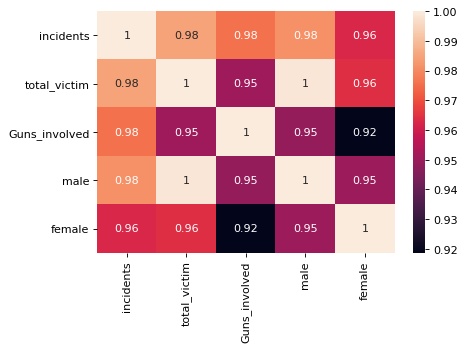

```python
#Correlation matrix how Gun shooting incidents and Guns involved affect the number of fatalities
df_state['male']=df_crime.groupby('state',as_index=False).sum()['male']
df_state['female']=df_crime.groupby('state',as_index=False).sum()['Female']
corrMatrix = df_state[['incidents','total_victim','Guns_involved','male','female']].corr()
plt.figure(figsize=(6,4), dpi= 80)
sns.heatmap(corrMatrix, annot=True)
plt.savefig("Corr_Inci_involed_2.png")
plt.show()
```

```python
df_state.describe()
```

|  | total_2013 | total_2014 | total_2015 | total_2016 | total_2017 | total_2018 | incident_2013 | incident_2014 | incident_2015 | incident_2016 | incident_2017 | incident_2018 | cluster | incidents | total_victim | Guns_involved | male | female |
| --- | --- | --- | --- | --- | --- | --- | --- | --- | --- | --- | --- | --- | --- | --- | --- | --- | --- | --- |
| count | 51.000000 | 51.000000 | 51.000000 | 51.000000 | 51.000000 | 51.000000 | 51.000000 | 51.000000 | 51.000000 | 51.000000 | 51.000000 | 51.000000 | 51.000000 | 51.000000 | 51.000000 | 51.000000 | 51.000000 | 51.000000 |
| mean | 25.411765 | 697.235294 | 793.156863 | 895.019608 | 906.156863 | 190.274510 | 5.450980 | 1016.745098 | 1050.568627 | 1152.215686 | 1203.941176 | 270.627451 | 1.254902 | 4699.549020 | 3507.254902 | 3773.568627 | 2933.725490 | 573.529412 |
| std | 33.336572 | 740.121330 | 805.849449 | 989.859293 | 957.373644 | 192.851868 | 7.150703 | 930.509277 | 921.828167 | 1111.246351 | 1134.288877 | 241.414495 | 1.671444 | 4263.348179 | 3685.123682 | 3604.166585 | 3144.826031 | 564.090608 |
| min | 0.000000 | 21.000000 | 33.000000 | 23.000000 | 20.000000 | 7.000000 | 0.000000 | 48.000000 | 75.000000 | 79.000000 | 68.000000 | 14.000000 | 0.000000 | 289.000000 | 125.000000 | 223.000000 | 90.000000 | 26.000000 |
| 25% | 0.000000 | 180.500000 | 226.500000 | 224.000000 | 218.000000 | 42.500000 | 0.000000 | 333.500000 | 370.000000 | 390.000000 | 389.500000 | 80.500000 | 0.000000 | 1610.000000 | 941.500000 | 1204.500000 | 749.000000 | 160.000000 |
| 50% | 13.000000 | 409.000000 | 469.000000 | 541.000000 | 584.000000 | 129.000000 | 3.000000 | 642.000000 | 737.000000 | 803.000000 | 866.000000 | 203.000000 | 0.000000 | 3201.000000 | 2140.000000 | 2657.000000 | 1722.000000 | 398.000000 |
| 75% | 41.500000 | 973.500000 | 1154.000000 | 1303.000000 | 1367.500000 | 294.500000 | 8.000000 | 1484.000000 | 1515.000000 | 1548.000000 | 1725.500000 | 370.500000 | 2.500000 | 6383.500000 | 4951.500000 | 5285.000000 | 4265.500000 | 901.000000 |
| max | 185.000000 | 2927.000000 | 3510.000000 | 5083.000000 | 4588.000000 | 737.000000 | 39.000000 | 3732.000000 | 3456.000000 | 5055.000000 | 5089.000000 | 1096.000000 | 4.000000 | 17556.000000 | 16923.000000 | 16969.000000 | 14967.000000 | 2240.000000 |

# Risk Score Calculation involving number of fatalities, incidents and Guns involved

```python
# Setting up dataset for Risk score calculation for US states
x=df_crime.query('total_person == 0').groupby(['state'],as_index=False).count()[['state','date']]
df_state = pd.merge(df_state,x, on='state',how = 'left')
df_state.rename(columns={'date': 'harmless_incident'}, inplace=True)
df_state['fatal_incident']=df_state['incidents']-df_state['harmless_incident']

x=df_crime.groupby(['state'],as_index=False).sum()[['state','n_killed','n_injured']]
df_state = pd.merge(df_state,x, on='state',how = 'left')

df_risk=df_state[['state','harmless_incident','fatal_incident','n_killed','n_injured','Guns_involved']]
```

```python
#Risk score calculation on our created Dataset
risk_harmless= .15*df_risk['harmless_incident']
risk_fatal= .30*df_risk['fatal_incident']
risk_killed= .30*df_risk['n_killed']
risk_injured= .15*df_risk['n_injured']
risk_gun= .10*df_risk['Guns_involved']
risk_score=(risk_harmless+risk_fatal+risk_killed+risk_injured+risk_gun)/5
df_risk['risk_score']=risk_score
df_risk['risk_score']=round((df_risk['risk_score']/max(df_risk['risk_score']))*100)

df_risk.sort_values('risk_score',ascending=False,inplace=True)
```

```python
df_state.sort_values('total_victim',ascending=False,inplace=True)
```

```python
# Providing Rank to Datasets
rank=list(range(1, 52))
df_risk['Rank']=rank
df_state['Rank']=rank
```

```python
x=df_state[['state','Rank']]
df_risk.rename(columns={'Rank': 'Risk_Rank'}, inplace=True)
# Merging to calculate change in Rank for dangerous US state
df_risk = pd.merge(df_risk,x, on='state',how = 'left')
df_risk.rename(columns={'Rank': 'Previous_Rank'}, inplace=True)
df_risk['Rank_Change']=-(df_risk['Risk_Rank']-df_risk['Previous_Rank'])
```

```python
df_risk
```

|  | state | harmless_incident | fatal_incident | n_killed | n_injured | Guns_involved | risk_score | Risk_Rank | Previous_Rank | Rank_Change |
| --- | --- | --- | --- | --- | --- | --- | --- | --- | --- | --- |
| 0 | Illinois | 4014 | 13542 | 3409 | 13514 | 13524.0 | 100.0 | 1 | 1 | 0 |
| 1 | California | 6335 | 9971 | 5562 | 7644 | 16969.0 | 93.0 | 2 | 2 | 0 |
| 2 | Florida | 6680 | 8349 | 3909 | 7072 | 13207.0 | 78.0 | 3 | 4 | 1 |
| 3 | Texas | 4947 | 8630 | 5046 | 6106 | 9785.0 | 74.0 | 4 | 3 | -1 |
| 4 | Ohio | 3554 | 6690 | 2508 | 5703 | 9065.0 | 56.0 | 5 | 5 | 0 |
| 5 | Pennsylvania | 2973 | 5956 | 2395 | 5056 | 7007.0 | 49.0 | 6 | 6 | 0 |
| 6 | New York | 4298 | 5414 | 1705 | 5059 | 8125.0 | 48.0 | 7 | 8 | 1 |
| 7 | North Carolina | 3227 | 5512 | 2225 | 4629 | 5734.0 | 45.0 | 8 | 7 | -1 |
| 8 | Georgia | 3811 | 5114 | 2456 | 4056 | 5887.0 | 45.0 | 9 | 10 | 1 |
| 9 | Louisiana | 2847 | 5256 | 2179 | 4398 | 5443.0 | 43.0 | 10 | 9 | -1 |
| 10 | Tennessee | 2546 | 5080 | 1824 | 4478 | 5355.0 | 40.0 | 11 | 11 | 0 |
| 11 | Missouri | 2208 | 4423 | 2136 | 3585 | 4894.0 | 37.0 | 12 | 12 | 0 |
| 12 | South Carolina | 3118 | 3821 | 1610 | 3084 | 4713.0 | 33.0 | 13 | 16 | 3 |
| 13 | Indiana | 2174 | 3678 | 1608 | 2956 | 5552.0 | 32.0 | 14 | 18 | 4 |
| 14 | Michigan | 2592 | 3544 | 1588 | 2990 | 5215.0 | 32.0 | 15 | 17 | 2 |
| 15 | Maryland | 1780 | 4018 | 1691 | 3167 | 4542.0 | 32.0 | 16 | 15 | -1 |
| 16 | Virginia | 1899 | 4050 | 1459 | 3566 | 3602.0 | 31.0 | 17 | 13 | -4 |
| 17 | Alabama | 1521 | 3950 | 1880 | 2998 | 3720.0 | 31.0 | 18 | 14 | -4 |
| 18 | New Jersey | 2462 | 2925 | 1168 | 2540 | 3911.0 | 26.0 | 19 | 19 | 0 |
| 19 | Massachusetts | 4173 | 1808 | 472 | 1701 | 5738.0 | 24.0 | 20 | 25 | 5 |
| 20 | Wisconsin | 2298 | 2489 | 862 | 2117 | 3175.0 | 22.0 | 21 | 21 | 0 |
| 21 | Kentucky | 1744 | 2413 | 1066 | 1894 | 3220.0 | 21.0 | 22 | 22 | 0 |
| 22 | Mississippi | 1131 | 2468 | 1176 | 1883 | 2322.0 | 20.0 | 23 | 20 | -3 |
| 23 | Oklahoma | 1409 | 2046 | 941 | 1550 | 2978.0 | 18.0 | 24 | 23 | -1 |
| 24 | Washington | 1718 | 1716 | 853 | 1287 | 3796.0 | 18.0 | 25 | 26 | 1 |
| 25 | Colorado | 1647 | 1554 | 796 | 1133 | 2986.0 | 16.0 | 26 | 28 | 2 |
| 26 | Arkansas | 1140 | 1702 | 773 | 1347 | 2116.0 | 15.0 | 27 | 27 | 0 |
| 27 | District of Columbia | 1714 | 1481 | 459 | 1415 | 2418.0 | 14.0 | 28 | 29 | 1 |
| 28 | Arizona | 628 | 1700 | 1094 | 1096 | 1807.0 | 14.0 | 29 | 24 | -5 |
| 29 | Connecticut | 1734 | 1333 | 341 | 1258 | 2649.0 | 13.0 | 30 | 31 | 1 |
| 30 | Nevada | 556 | 1396 | 799 | 951 | 1577.0 | 11.0 | 31 | 30 | -1 |
| 31 | Minnesota | 1369 | 1039 | 461 | 916 | 2169.0 | 11.0 | 32 | 33 | 1 |
| 32 | Oregon | 1367 | 919 | 446 | 694 | 2657.0 | 11.0 | 33 | 34 | 1 |
| 33 | Iowa | 1577 | 940 | 273 | 821 | 1899.0 | 10.0 | 34 | 35 | 1 |
| 34 | Kansas | 958 | 1187 | 542 | 931 | 1489.0 | 10.0 | 35 | 32 | -3 |
| 35 | New Mexico | 805 | 840 | 495 | 543 | 1448.0 | 8.0 | 36 | 37 | 1 |
| 36 | Delaware | 772 | 913 | 217 | 853 | 1221.0 | 8.0 | 37 | 36 | -1 |
| 37 | Nebraska | 898 | 753 | 225 | 674 | 1284.0 | 7.0 | 38 | 39 | 1 |
| 38 | West Virginia | 757 | 818 | 335 | 649 | 1182.0 | 7.0 | 39 | 38 | -1 |
| 39 | Alaska | 850 | 499 | 267 | 325 | 1188.0 | 6.0 | 40 | 41 | 1 |
| 40 | Utah | 523 | 549 | 282 | 402 | 1027.0 | 5.0 | 41 | 40 | -1 |
| 41 | Rhode Island | 568 | 327 | 63 | 346 | 700.0 | 4.0 | 42 | 42 | 0 |
| 42 | Montana | 404 | 234 | 154 | 136 | 665.0 | 3.0 | 43 | 44 | 1 |
| 43 | Maine | 714 | 193 | 112 | 132 | 806.0 | 3.0 | 44 | 45 | 1 |
| 44 | New Hampshire | 756 | 208 | 88 | 144 | 901.0 | 3.0 | 45 | 46 | 1 |
| 45 | Idaho | 400 | 261 | 166 | 149 | 763.0 | 3.0 | 46 | 43 | -3 |
| 46 | North Dakota | 401 | 172 | 69 | 130 | 465.0 | 2.0 | 47 | 48 | 1 |
| 47 | Vermont | 360 | 112 | 57 | 73 | 371.0 | 2.0 | 48 | 50 | 2 |
| 48 | South Dakota | 373 | 171 | 90 | 114 | 686.0 | 2.0 | 49 | 47 | -2 |
| 49 | Wyoming | 389 | 105 | 73 | 52 | 276.0 | 2.0 | 50 | 51 | 1 |
| 50 | Hawaii | 168 | 121 | 63 | 85 | 223.0 | 1.0 | 51 | 49 | -2 |

```python
# Setting up dataset for Risk score calculation for Month of Year
df_month_risk=df_crime.query('total_person == 0').groupby('month',as_index=False).count()[['month','date']]
df_month_risk.rename(columns={'date': 'harmless_incident'}, inplace=True)
df_month_risk['fatal_incident']=df_crime.query('total_person > 0').groupby('month',as_index=False).count()['date']
x=df_crime.groupby('month',as_index=False).sum()[['month','n_killed','n_injured','n_guns_involved']]
df_month_risk= pd.merge(df_month_risk,x, on='month',how = 'left')

#Risk score calculation on our created Dataset
risk_harmless= .15*df_month_risk['harmless_incident']
risk_fatal= .30*df_month_risk['fatal_incident']
risk_killed= .30*df_month_risk['n_killed']
risk_injured= .15*df_month_risk['n_injured']
risk_gun= .10*df_month_risk['n_guns_involved']
risk_score=(risk_harmless+risk_fatal+risk_killed+risk_injured+risk_gun)/5
df_month_risk['risk_score']=risk_score
df_month_risk['risk_score']=round((df_month_risk['risk_score']/max(df_month_risk['risk_score']))*100)
df_month_risk.sort_values('risk_score',ascending=False,inplace=True)
x=df_crime.groupby('month',as_index=False).sum()[['month','total_person']]
x.sort_values('total_person',ascending=False,inplace=True)

# Providing Rank to Datasets
rank=list(range(1, 13))
df_month_risk['Risk_Rank']=rank
x['Rank']=rank
df_month_risk['Previous_Rank']=x['Rank']

# calculate change in Rank for dangerous Month of year
df_month_risk['Rank_Change']=-(df_month_risk['Risk_Rank']-df_month_risk['Previous_Rank'])
```

```python
df_month_risk
```

|  | month | harmless_incident | fatal_incident | n_killed | n_injured | n_guns_involved | risk_score | Risk_Rank | Previous_Rank | Rank_Change |
| --- | --- | --- | --- | --- | --- | --- | --- | --- | --- | --- |
| 4 | January | 9339 | 13752 | 6035 | 10946 | 18258.0 | 100.0 | 1 | 1 | 0 |
| 7 | March | 9832 | 12808 | 5641 | 10475 | 18789.0 | 97.0 | 2 | 3 | 1 |
| 1 | August | 8536 | 12504 | 5127 | 10809 | 17234.0 | 92.0 | 3 | 4 | 1 |
| 5 | July | 8185 | 12941 | 5276 | 11259 | 14333.0 | 91.0 | 4 | 2 | -2 |
| 8 | May | 7944 | 11986 | 4830 | 10244 | 15060.0 | 86.0 | 5 | 5 | 0 |
| 10 | October | 8222 | 11668 | 4791 | 9756 | 16755.0 | 86.0 | 6 | 7 | 1 |
| 11 | September | 8157 | 11499 | 4779 | 9766 | 15468.0 | 84.0 | 7 | 8 | 1 |
| 2 | December | 6804 | 11302 | 4927 | 8936 | 17775.0 | 83.0 | 8 | 10 | 2 |
| 6 | June | 7259 | 11496 | 4886 | 9797 | 13402.0 | 82.0 | 9 | 6 | -3 |
| 3 | February | 8169 | 10672 | 4945 | 8420 | 16192.0 | 81.0 | 10 | 11 | 1 |
| 9 | November | 6866 | 11108 | 4848 | 9087 | 16053.0 | 81.0 | 11 | 9 | -2 |
| 0 | April | 7974 | 10654 | 4383 | 8907 | 13133.0 | 77.0 | 12 | 12 | 0 |

```python
# Setting up dataset for Risk score calculation for Day of Week
df_day_risk=df_crime.query('total_person == 0').groupby('day',as_index=False).count()[['day','date']]
df_day_risk.rename(columns={'date': 'harmless_incident'}, inplace=True)
df_day_risk['fatal_incident']=df_crime.query('total_person > 0').groupby('day',as_index=False).count()['date']
x=df_crime.groupby('day',as_index=False).sum()[['day','n_killed','n_injured','n_guns_involved']]
df_day_risk= pd.merge(df_day_risk,x, on='day',how = 'left')

#Risk score calculation on our created Dataset
risk_harmless= .15*df_day_risk['harmless_incident']
risk_fatal= .30*df_day_risk['fatal_incident']
risk_killed= .30*df_day_risk['n_killed']
risk_injured= .15*df_day_risk['n_injured']
risk_gun= .10*df_day_risk['n_guns_involved']
risk_score=(risk_harmless+risk_fatal+risk_killed+risk_injured+risk_gun)/5
df_day_risk['risk_score']=risk_score
df_day_risk['risk_score']=round((df_day_risk['risk_score']/max(df_day_risk['risk_score']))*100)
df_day_risk.sort_values('risk_score',ascending=False,inplace=True)
x=df_crime.groupby('day',as_index=False).sum()[['day','total_person']]
x.sort_values('total_person',ascending=False,inplace=True)

# Providing Rank to Datasets
rank=list(range(1,8))
df_day_risk['Risk_Rank']=rank
x['Rank']=rank
df_day_risk['Previous_Rank']=x['Rank']

# calculate change in Rank for dangerous Day of week
df_day_risk['Rank_Change']=-(df_day_risk['Risk_Rank']-df_day_risk['Previous_Rank'])
```

```python
df_day_risk
```

|  | day | harmless_incident | fatal_incident | n_killed | n_injured | n_guns_involved | risk_score | Risk_Rank | Previous_Rank | Rank_Change |
| --- | --- | --- | --- | --- | --- | --- | --- | --- | --- | --- |
| 2 | Saturday | 12555 | 23541 | 9813 | 20559 | 29359.0 | 100.0 | 1 | 2 | 1 |
| 3 | Sunday | 12979 | 24073 | 10187 | 21562 | 25387.0 | 100.0 | 2 | 1 | -1 |
| 1 | Monday | 13885 | 19875 | 8383 | 16164 | 26158.0 | 87.0 | 3 | 3 | 0 |
| 6 | Wednesday | 15191 | 18935 | 8083 | 15193 | 29157.0 | 87.0 | 4 | 5 | 1 |
| 5 | Tuesday | 14430 | 18877 | 7917 | 15168 | 27990.0 | 85.0 | 5 | 6 | 1 |
| 0 | Friday | 13753 | 19022 | 8353 | 15275 | 25728.0 | 84.0 | 6 | 4 | -2 |
| 4 | Thursday | 14494 | 18067 | 7732 | 14481 | 28673.0 | 83.0 | 7 | 7 | 0 |

## Which Day of week can see high Gun violance based on Risk score?

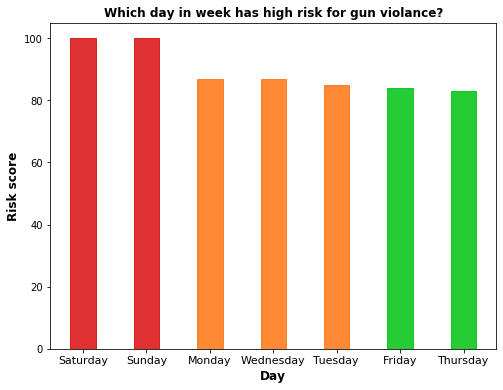

```python
# Bar chart to show which day of week is safer and dangerous
fig, ax = plt.subplots(figsize=(8,6))
barplot = plt.bar(df_day_risk.day, df_day_risk.risk_score, color = 'green', alpha = 0.85,width=0.4)
barplot[0].set_color('#DA0D0D')
barplot[1].set_color('#DA0D0D')
barplot[2].set_color('#FF7511')
barplot[3].set_color('#FF7511')
barplot[4].set_color('#FF7511')
barplot[5].set_color('#00C411')
barplot[6].set_color('#00C411')
plt.xticks(ticks=df_day_risk.day,fontsize = 11)
plt.xlabel('Day', fontsize = 12, weight = 'bold')
plt.ylabel('Risk score', fontsize = 12, weight = 'bold')
plt.title('Which day in week has high risk for gun violance?', fontsize = 12, weight = 'bold')
plt.savefig("Risk_Rank_day_1.png")

plt.show()
```

## Which Month of year can see high Gun violance based on Risk score?

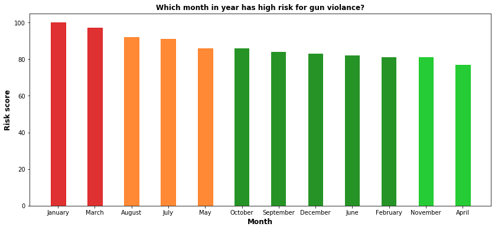

```python
# Bar chart to show which month of year is safer and dangerous
fig, ax = plt.subplots(figsize=(14,6))
barplot = plt.bar(df_month_risk.month, df_month_risk.risk_score, color = 'green', alpha = .85,width=0.4)
barplot[0].set_color('#DA0D0D')
barplot[1].set_color('#DA0D0D')
barplot[2].set_color('#FF7511')
barplot[3].set_color('#FF7511')
barplot[4].set_color('#FF7511')
barplot[10].set_color('#00C411')
barplot[11].set_color('#00C411')
plt.xticks(ticks=df_month_risk.month,fontsize = 10)
plt.xlabel('Month', fontsize = 12, weight = 'bold')
plt.ylabel('Risk score', fontsize = 12, weight = 'bold')
plt.title('Which month in year has high risk for gun violance?', fontsize = 12, weight = 'bold')
plt.savefig("Risk_Rank_month_1.png")
plt.show()
```

## Which USA State has high chance of Gun violance based on Risk score generated?

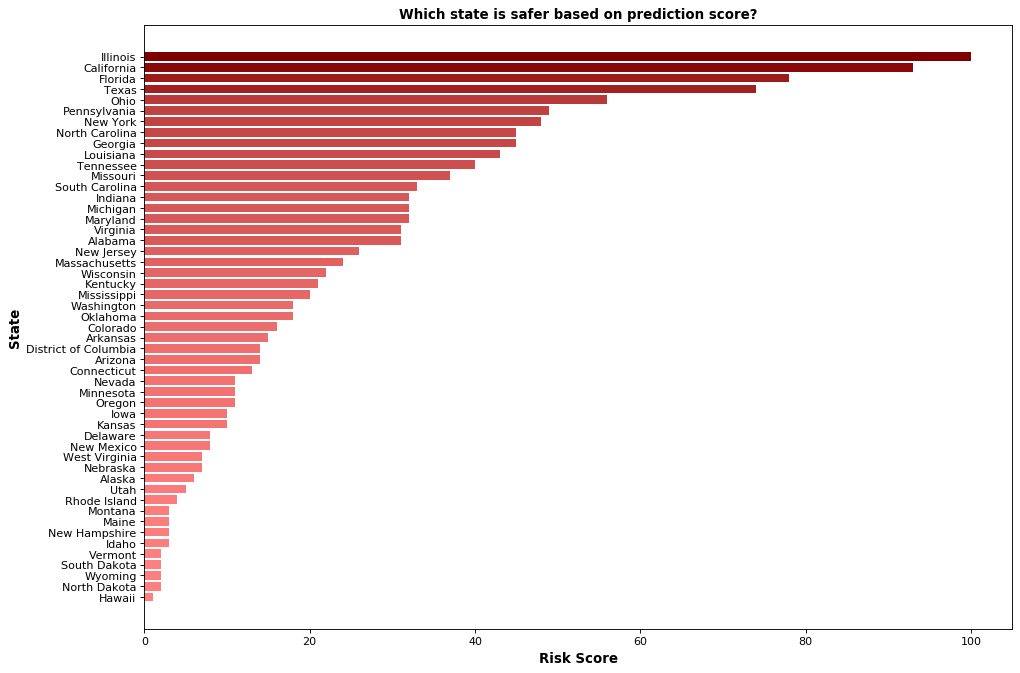

```python
# Bar chart to show which state is safer and dangerous
df_risk.sort_values('risk_score', inplace=True,ascending=True)

likeability_scores = np.array(df_risk.risk_score)

data_normalizer = mp.colors.Normalize()
color_map = mp.colors.LinearSegmentedColormap(
    "my_map",
    {
        "red": [(0, 1.0, 1.0),
                (1.0, .5, .5)],
        "green": [(0, 0.5, 0.5),
                  (1.0, 0, 0)],
        "blue": [(0, 0.50, 0.5),
                 (1.0, 0, 0)]
    }
)


plt.figure(figsize=(14,10), dpi= 80)
plt.barh(df_risk.state, df_risk.risk_score, align='center',color=color_map(data_normalizer(likeability_scores)))


plt.ylabel('State', fontsize = 12, weight = 'bold')
plt.xlabel('Risk Score', fontsize = 12, weight = 'bold')
plt.title('Which state is safer based on prediction score?', fontdict={'size':12},weight = 'bold')
plt.savefig("Risk_Rank_state_1.png",dpi='figure',quality=100)
plt.show()
```

## How Does the safety ranking of USA state affect based on Risk score generated?

```python
# Safety ranking of USA state affect based on Risk score generated
# Prepare Data

df_risk['colors'] = ['red' if x < 0 else 'green' for x in df_risk['Rank_Change']]
df_risk1=df_risk.copy()
df_risk1.sort_values('Rank_Change', inplace=True)
```

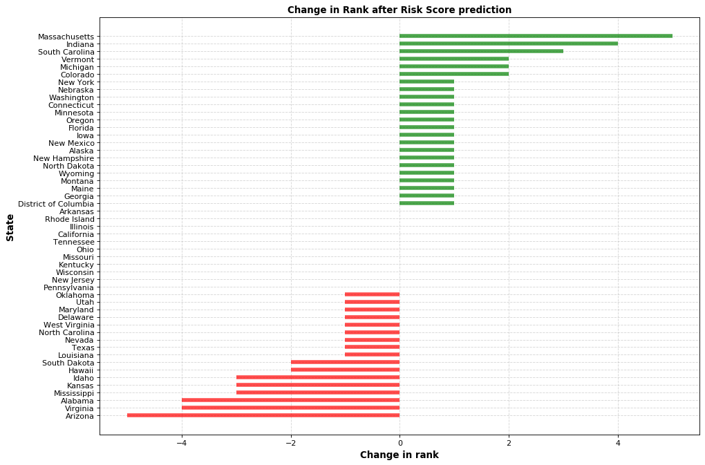

```python
# Draw plot
plt.figure(figsize=(14,10), dpi= 80)
plt.hlines(y=df_risk1.state, xmin=0, xmax=df_risk1.Rank_Change, color=df_risk1['colors'], alpha=0.7, linewidth=5)

# Decorations
plt.gca().set(ylabel='State', xlabel='Change in Rank')
plt.yticks(df_risk1.state, fontsize=10)
plt.ylabel('State', fontsize = 12, weight = 'bold')
plt.xlabel('Change in rank', fontsize = 12, weight = 'bold')
plt.title('Change in Rank after Risk Score prediction', fontsize = 12, weight = 'bold')
plt.grid(linestyle='--', alpha=0.5)
plt.savefig("Risk_Rank_change_1.png")
plt.show()
```

# Risk calculation involving Population, Per-capita income and Un-employment in US States.

```python
# Prepare dataset from main DATASET(Dataset1)
df_state_risk=df_risk[['state','harmless_incident','fatal_incident','n_killed','n_injured','Guns_involved','Previous_Rank']]
df_state_risk['harmless_incident']=(df_state_risk['harmless_incident']/max(df_state_risk['harmless_incident']))*100
df_state_risk['fatal_incident']=(df_state_risk['fatal_incident']/max(df_state_risk['fatal_incident']))*100
df_state_risk['n_killed']=(df_state_risk['n_killed']/max(df_state_risk['n_killed']))*100
df_state_risk['n_injured']=(df_state_risk['n_injured']/max(df_state_risk['n_injured']))*100
df_state_risk['Guns_involved']=(df_state_risk['Guns_involved']/max(df_state_risk['Guns_involved']))*100
```

```python
# Prepare datset from Population_Un-Employment_Per-capita(Dataset2)
df_state_risk.rename(columns={'state': 'State'}, inplace=True)
x=df_capita[['State','Pop']]
y=df_state_risk['State']
df_capita_state=pd.merge(y,x, on='State',how = 'left')
x=df_risk[['state','n_killed']]
x.rename(columns={'state': 'State'}, inplace=True)

df_capita_state=pd.merge(df_capita_state,x, on='State',how = 'left')

df_capita_state['Avg_Death_Rate']=((df_capita_state['n_killed']/df_capita_state['Pop'])*100000)

x=df_capita[['State','Per_Capita_2018','Per_Capita_2017','Per_Capita_2016','Per_Capita_2015','Per_Capita_2014','Per_Capita_2013','Une_Rate_2018','Une_Rate_2017','Une_Rate_2016','Une_Rate_2015','Une_Rate_2014','Une_Rate_2013']]
x['Avg_per_capita']=(x['Per_Capita_2018']+x['Per_Capita_2017']+x['Per_Capita_2016']+x['Per_Capita_2015']+x['Per_Capita_2014']+x['Per_Capita_2013'])/6
x['Avg_Un_Emp']=(x['Une_Rate_2018']+x['Une_Rate_2017']+x['Une_Rate_2016']+x['Une_Rate_2015']+x['Une_Rate_2014']+x['Une_Rate_2013'])/6

y=x[['State','Avg_per_capita','Avg_Un_Emp']]

df_capita_state=pd.merge(df_capita_state,y, on='State',how = 'left')
```

```python
df_capita=df_capita_state.copy()
```

```python
df_capita.sort_values('Avg_Un_Emp',inplace=True)
df_capita.reset_index(inplace=True,drop=True)
df_capita
```

|  | State | Pop | n_killed | Avg_Death_Rate | Avg_per_capita | Avg_Un_Emp |
| --- | --- | --- | --- | --- | --- | --- |
| 0 | North Dakota | 761723.0 | 69 | 9.058411 | 58691.666667 | 2.800000 |
| 1 | Nebraska | 1952570.0 | 225 | 11.523274 | 54688.166667 | 3.166667 |
| 2 | South Dakota | 903027.0 | 90 | 9.966479 | 52345.333333 | 3.266667 |
| 3 | Vermont | 628061.0 | 57 | 9.075552 | 55420.333333 | 3.416667 |
| 4 | Hawaii | 1412687.0 | 63 | 4.459587 | 69656.500000 | 3.466667 |
| 5 | New Hampshire | 1371246.0 | 88 | 6.417521 | 67797.833333 | 3.500000 |
| 6 | Utah | 3282115.0 | 282 | 8.592021 | 60046.500000 | 3.616667 |
| 7 | Iowa | 3179849.0 | 273 | 8.585313 | 54052.833333 | 3.666667 |
| 8 | Minnesota | 5700671.0 | 461 | 8.086767 | 56784.666667 | 3.850000 |
| 9 | Idaho | 1826156.0 | 166 | 9.090132 | 48351.000000 | 4.150000 |
| 10 | Kansas | 2910357.0 | 542 | 18.623145 | 53149.000000 | 4.150000 |
| 11 | Colorado | 5845526.0 | 796 | 13.617252 | 62613.833333 | 4.183333 |
| 12 | Montana | 1086759.0 | 154 | 14.170575 | 48890.333333 | 4.316667 |
| 13 | Virginia | 8626207.0 | 1459 | 16.913575 | 65071.833333 | 4.366667 |
| 14 | Wyoming | 567025.0 | 73 | 12.874212 | 59405.333333 | 4.416667 |
| 15 | Oklahoma | 3954821.0 | 941 | 23.793744 | 47857.000000 | 4.433333 |
| 16 | Wisconsin | 5851754.0 | 862 | 14.730626 | 54433.166667 | 4.483333 |
| 17 | Maine | 1345790.0 | 112 | 8.322249 | 50754.500000 | 4.500000 |
| 18 | Massachusetts | 6976597.0 | 472 | 6.765476 | 68937.833333 | 4.700000 |
| 19 | Texas | 29472295.0 | 5046 | 17.121164 | 54220.666667 | 4.750000 |
| 20 | Missouri | 6169270.0 | 2136 | 34.623221 | 49581.833333 | 4.883333 |
| 21 | Arkansas | 3038999.0 | 773 | 25.436007 | 42756.166667 | 4.916667 |
| 22 | Indiana | 6745354.0 | 1608 | 23.838630 | 50108.000000 | 5.000000 |
| 23 | Delaware | 982895.0 | 217 | 22.077638 | 59145.833333 | 5.016667 |
| 24 | Maryland | 6083116.0 | 1691 | 27.798253 | 74156.000000 | 5.016667 |
| 25 | Florida | 21992985.0 | 3909 | 17.773849 | 49299.333333 | 5.266667 |
| 26 | Tennessee | 6897576.0 | 1824 | 26.444073 | 47166.500000 | 5.333333 |
| 27 | Ohio | 11747694.0 | 2508 | 21.348871 | 50511.833333 | 5.450000 |
| 28 | South Carolina | 5210095.0 | 1610 | 30.901548 | 46574.333333 | 5.483333 |
| 29 | New York | 19440469.0 | 1705 | 8.770365 | 62261.166667 | 5.500000 |
| 30 | Pennsylvania | 12820878.0 | 2395 | 18.680468 | 55384.000000 | 5.516667 |
| 31 | Washington | 7797095.0 | 853 | 10.939972 | 63794.333333 | 5.533333 |
| 32 | Oregon | 4301089.0 | 446 | 10.369467 | 53854.333333 | 5.550000 |
| 33 | North Carolina | 10611862.0 | 2225 | 20.967103 | 48243.666667 | 5.600000 |
| 34 | Connecticut | 3563077.0 | 341 | 9.570380 | 71775.666667 | 5.666667 |
| 35 | Kentucky | 4499692.0 | 1066 | 23.690510 | 42702.666667 | 5.683333 |
| 36 | Alabama | 4908621.0 | 1880 | 38.299962 | 44526.333333 | 5.700000 |
| 37 | New Jersey | 8936574.0 | 1168 | 13.069886 | 73021.500000 | 5.750000 |
| 38 | Michigan | 10045029.0 | 1588 | 15.808814 | 55847.500000 | 5.850000 |
| 39 | Georgia | 10736059.0 | 2456 | 22.876178 | 50646.833333 | 5.883333 |
| 40 | Louisiana | 4645184.0 | 2179 | 46.908798 | 45213.166667 | 5.916667 |
| 41 | Arizona | 7378494.0 | 1094 | 14.826874 | 50643.166667 | 5.933333 |
| 42 | West Virginia | 1778070.0 | 335 | 18.840653 | 41960.500000 | 6.100000 |
| 43 | Rhode Island | 1056161.0 | 63 | 5.965000 | 57975.833333 | 6.100000 |
| 44 | Illinois | 12659682.0 | 3409 | 26.928007 | 59021.166667 | 6.183333 |
| 45 | California | 39937489.0 | 5562 | 13.926764 | 64792.166667 | 6.200000 |
| 46 | New Mexico | 2096640.0 | 495 | 23.609203 | 44791.166667 | 6.250000 |
| 47 | Mississippi | 2989260.0 | 1176 | 39.340840 | 43633.666667 | 6.350000 |
| 48 | Nevada | 3139658.0 | 799 | 25.448632 | 52753.166667 | 6.550000 |
| 49 | Alaska | 734002.0 | 267 | 36.375923 | 71080.500000 | 6.783333 |
| 50 | District of Columbia | 720687.0 | 459 | 63.689230 | 52171.000000 | 6.850000 |

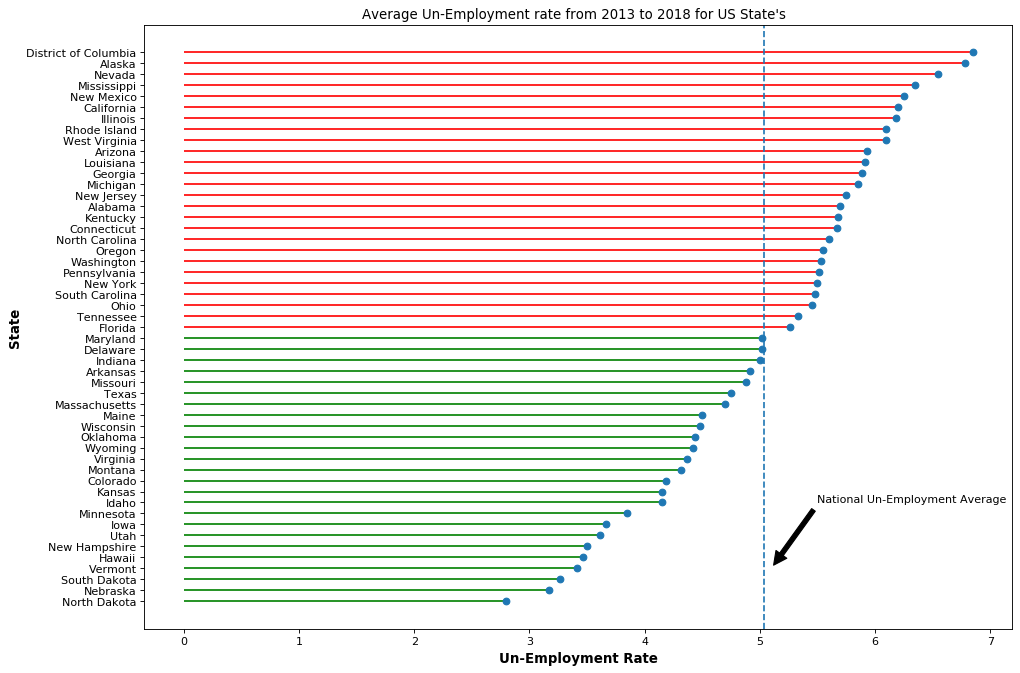

```python
plt.figure(figsize=(14,10), dpi= 80)
df_capita['colors'] = ['red' if x >= df_capita.Avg_Un_Emp.mean() else 'green' for x in df_capita.Avg_Un_Emp]
plt.hlines(y=df_capita.State, xmin=0, xmax=df_capita.Avg_Un_Emp, color=df_capita['colors'])
plt.plot(df_capita.Avg_Un_Emp, df_capita.State, "o")
plt.axvline(x = df_capita.Avg_Un_Emp.mean(),linestyle='--')
plt.annotate('National Un-Employment Average', xy=(5.1, 3), xytext=(5.5, 9),
            arrowprops=dict(facecolor='black', shrink=0.05),fontsize = 10)
# Add titles and axis names
plt.yticks(df_capita.State,fontsize = 10)
plt.title("Average Un-Employment rate from 2013 to 2018 for US State's  ")
plt.xlabel('Un-Employment Rate',fontsize = 12, weight = 'bold')
plt.ylabel('State',fontsize = 12, weight = 'bold')
plt.savefig("US_Un_Emp.png",dpi='figure',quality=100);
```

```python
df_capita.sort_values('Avg_per_capita',inplace=True)
df_capita.reset_index(inplace=True,drop=True)
```

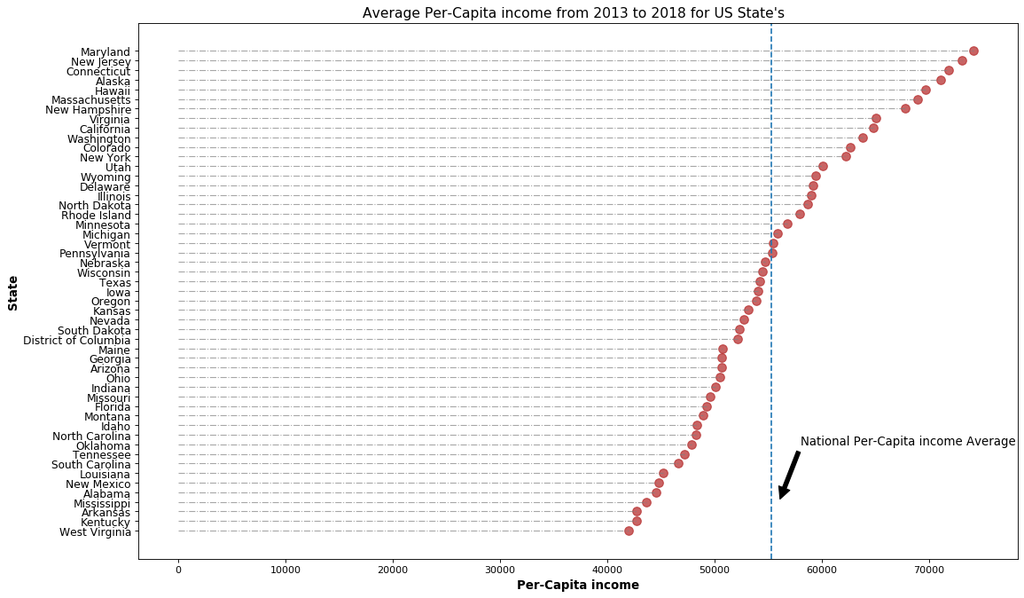

```python
df_capita['colors'] = ['red' if x >= df_capita.Avg_per_capita.mean() else 'green' for x in df_capita.Avg_per_capita]
fig, ax = plt.subplots(figsize=(16,10), dpi= 80)
plt.hlines(y=df_capita.State, xmin=0, xmax=df_capita.Avg_per_capita, color='gray', alpha=0.7, linewidth=1, linestyles='dashdot')
plt.scatter(y=df_capita.State, x=df_capita.Avg_per_capita, s=75, color='firebrick', alpha=0.7)
plt.axvline(x = df_capita.Avg_per_capita.mean(),linestyle='--')
plt.annotate('National Per-Capita income Average', xy=(56000, 3), xytext=(58000, 9),
            arrowprops=dict(facecolor='black', shrink=0.05),fontsize = 12)
# Title, Label, Ticks and Ylim
plt.yticks(df_capita.State,fontsize = 11)
plt.title("Average Per-Capita income from 2013 to 2018 for US State's  ",fontsize = 14)
plt.xlabel('Per-Capita income',fontsize = 12, weight = 'bold')
plt.ylabel('State',fontsize = 12, weight = 'bold')
plt.savefig("US_Per_capita.png",dpi='figure',quality=100);
```

```python
df_capita.Avg_per_capita.mean()
```

```
55265.91503267975
```

```python
df_capita.Avg_Un_Emp.mean()
```

```
5.039542483660131
```

```python
df_capita['Not_Safe'] = ['Yes' if x >= df_capita.Avg_Death_Rate.mean() else 'No' for x in df_capita.Avg_Death_Rate]
```

```python
df_capita['More_than_per_capita'] = ['Yes' if x >= df_capita.Avg_per_capita.mean() else 'No' for x in df_capita.Avg_per_capita]
```

```python
df_capita['More_than_Un_Emp'] = ['Yes' if x >= df_capita.Avg_Un_Emp.mean() else 'No' for x in df_capita.Avg_Un_Emp]
```

```python
df_capita
```

|  | State | Pop | n_killed | Avg_Death_Rate | Avg_per_capita | Avg_Un_Emp | colors | Not_Safe | More_than_per_capita | More_than_Un_Emp |
| --- | --- | --- | --- | --- | --- | --- | --- | --- | --- | --- |
| 0 | West Virginia | 1778070.0 | 335 | 18.840653 | 41960.500000 | 6.100000 | green | No | No | Yes |
| 1 | Kentucky | 4499692.0 | 1066 | 23.690510 | 42702.666667 | 5.683333 | green | Yes | No | Yes |
| 2 | Arkansas | 3038999.0 | 773 | 25.436007 | 42756.166667 | 4.916667 | green | Yes | No | No |
| 3 | Mississippi | 2989260.0 | 1176 | 39.340840 | 43633.666667 | 6.350000 | green | Yes | No | Yes |
| 4 | Alabama | 4908621.0 | 1880 | 38.299962 | 44526.333333 | 5.700000 | green | Yes | No | Yes |
| 5 | New Mexico | 2096640.0 | 495 | 23.609203 | 44791.166667 | 6.250000 | green | Yes | No | Yes |
| 6 | Louisiana | 4645184.0 | 2179 | 46.908798 | 45213.166667 | 5.916667 | green | Yes | No | Yes |
| 7 | South Carolina | 5210095.0 | 1610 | 30.901548 | 46574.333333 | 5.483333 | green | Yes | No | Yes |
| 8 | Tennessee | 6897576.0 | 1824 | 26.444073 | 47166.500000 | 5.333333 | green | Yes | No | Yes |
| 9 | Oklahoma | 3954821.0 | 941 | 23.793744 | 47857.000000 | 4.433333 | green | Yes | No | No |
| 10 | North Carolina | 10611862.0 | 2225 | 20.967103 | 48243.666667 | 5.600000 | green | Yes | No | Yes |
| 11 | Idaho | 1826156.0 | 166 | 9.090132 | 48351.000000 | 4.150000 | green | No | No | No |
| 12 | Montana | 1086759.0 | 154 | 14.170575 | 48890.333333 | 4.316667 | green | No | No | No |
| 13 | Florida | 21992985.0 | 3909 | 17.773849 | 49299.333333 | 5.266667 | green | No | No | Yes |
| 14 | Missouri | 6169270.0 | 2136 | 34.623221 | 49581.833333 | 4.883333 | green | Yes | No | No |
| 15 | Indiana | 6745354.0 | 1608 | 23.838630 | 50108.000000 | 5.000000 | green | Yes | No | No |
| 16 | Ohio | 11747694.0 | 2508 | 21.348871 | 50511.833333 | 5.450000 | green | Yes | No | Yes |
| 17 | Arizona | 7378494.0 | 1094 | 14.826874 | 50643.166667 | 5.933333 | green | No | No | Yes |
| 18 | Georgia | 10736059.0 | 2456 | 22.876178 | 50646.833333 | 5.883333 | green | Yes | No | Yes |
| 19 | Maine | 1345790.0 | 112 | 8.322249 | 50754.500000 | 4.500000 | green | No | No | No |
| 20 | District of Columbia | 720687.0 | 459 | 63.689230 | 52171.000000 | 6.850000 | green | Yes | No | Yes |
| 21 | South Dakota | 903027.0 | 90 | 9.966479 | 52345.333333 | 3.266667 | green | No | No | No |
| 22 | Nevada | 3139658.0 | 799 | 25.448632 | 52753.166667 | 6.550000 | green | Yes | No | Yes |
| 23 | Kansas | 2910357.0 | 542 | 18.623145 | 53149.000000 | 4.150000 | green | No | No | No |
| 24 | Oregon | 4301089.0 | 446 | 10.369467 | 53854.333333 | 5.550000 | green | No | No | Yes |
| 25 | Iowa | 3179849.0 | 273 | 8.585313 | 54052.833333 | 3.666667 | green | No | No | No |
| 26 | Texas | 29472295.0 | 5046 | 17.121164 | 54220.666667 | 4.750000 | green | No | No | No |
| 27 | Wisconsin | 5851754.0 | 862 | 14.730626 | 54433.166667 | 4.483333 | green | No | No | No |
| 28 | Nebraska | 1952570.0 | 225 | 11.523274 | 54688.166667 | 3.166667 | green | No | No | No |
| 29 | Pennsylvania | 12820878.0 | 2395 | 18.680468 | 55384.000000 | 5.516667 | red | No | Yes | Yes |
| 30 | Vermont | 628061.0 | 57 | 9.075552 | 55420.333333 | 3.416667 | red | No | Yes | No |
| 31 | Michigan | 10045029.0 | 1588 | 15.808814 | 55847.500000 | 5.850000 | red | No | Yes | Yes |
| 32 | Minnesota | 5700671.0 | 461 | 8.086767 | 56784.666667 | 3.850000 | red | No | Yes | No |
| 33 | Rhode Island | 1056161.0 | 63 | 5.965000 | 57975.833333 | 6.100000 | red | No | Yes | Yes |
| 34 | North Dakota | 761723.0 | 69 | 9.058411 | 58691.666667 | 2.800000 | red | No | Yes | No |
| 35 | Illinois | 12659682.0 | 3409 | 26.928007 | 59021.166667 | 6.183333 | red | Yes | Yes | Yes |
| 36 | Delaware | 982895.0 | 217 | 22.077638 | 59145.833333 | 5.016667 | red | Yes | Yes | No |
| 37 | Wyoming | 567025.0 | 73 | 12.874212 | 59405.333333 | 4.416667 | red | No | Yes | No |
| 38 | Utah | 3282115.0 | 282 | 8.592021 | 60046.500000 | 3.616667 | red | No | Yes | No |
| 39 | New York | 19440469.0 | 1705 | 8.770365 | 62261.166667 | 5.500000 | red | No | Yes | Yes |
| 40 | Colorado | 5845526.0 | 796 | 13.617252 | 62613.833333 | 4.183333 | red | No | Yes | No |
| 41 | Washington | 7797095.0 | 853 | 10.939972 | 63794.333333 | 5.533333 | red | No | Yes | Yes |
| 42 | California | 39937489.0 | 5562 | 13.926764 | 64792.166667 | 6.200000 | red | No | Yes | Yes |
| 43 | Virginia | 8626207.0 | 1459 | 16.913575 | 65071.833333 | 4.366667 | red | No | Yes | No |
| 44 | New Hampshire | 1371246.0 | 88 | 6.417521 | 67797.833333 | 3.500000 | red | No | Yes | No |
| 45 | Massachusetts | 6976597.0 | 472 | 6.765476 | 68937.833333 | 4.700000 | red | No | Yes | No |
| 46 | Hawaii | 1412687.0 | 63 | 4.459587 | 69656.500000 | 3.466667 | red | No | Yes | No |
| 47 | Alaska | 734002.0 | 267 | 36.375923 | 71080.500000 | 6.783333 | red | Yes | Yes | Yes |
| 48 | Connecticut | 3563077.0 | 341 | 9.570380 | 71775.666667 | 5.666667 | red | No | Yes | Yes |
| 49 | New Jersey | 8936574.0 | 1168 | 13.069886 | 73021.500000 | 5.750000 | red | No | Yes | Yes |
| 50 | Maryland | 6083116.0 | 1691 | 27.798253 | 74156.000000 | 5.016667 | red | Yes | Yes | No |

```python
df_capita['Avg_Death_Rate'].mean()
```

```
19.03788618840494
```

```python
#proportion of states more than National per capita average
More_than_per_capita_yes = df_capita[df_capita["More_than_per_capita"]=="Yes"]
total = df_capita.shape[0]
More_than_per_capita_yes.shape[0]/total
```

```
0.43137254901960786
```

```python
More_than_per_capita_yes['Avg_Death_Rate'].mean()
```

```
13.898720092283982
```

```python
prop = []
for _ in range(1000):
    sample = df_capita.sample(20,replace=True)
    More_than_per_capita_yes = sample[sample["More_than_per_capita"]=="Yes"]
    prop.append(More_than_per_capita_yes['Avg_Death_Rate'].mean())
```

```python
prop = np.array(prop)
prop.mean()
```

```
13.816073214984723
```

```python
np.percentile(prop,5),np.percentile(prop,95)
```

```
(9.531667686582015, 19.093735414578465)
```

```python
#proportion of states less than National per capita average
More_than_per_capita_no = df_capita[df_capita["More_than_per_capita"]=="No"]
total = df_capita.shape[0]
More_than_per_capita_no.shape[0]/total
```

```
0.5686274509803921
```

```python
More_than_per_capita_no['Avg_Death_Rate'].mean()
```

```
22.9365639164967
```

```python
prop = []
for _ in range(1000):
    sample = df_capita.sample(20,replace=True)
    More_than_per_capita_no = sample[sample["More_than_per_capita"]=="No"]
    prop.append(More_than_per_capita_no['Avg_Death_Rate'].mean())
```

```python
prop = np.array(prop)
prop.mean()
```

```
23.054251241797118
```

```python
np.percentile(prop,5),np.percentile(prop,95)
```

```
(17.434630229752937, 29.644323009547634)
```

```python
#proportion of states more than National Un-Employment average
More_than_Un_Emp_yes = df_capita[df_capita["More_than_Un_Emp"]=="Yes"]
total = df_capita.shape[0]
More_than_Un_Emp_yes.shape[0]/total
```

```
0.5098039215686274
```

```python
More_than_Un_Emp_yes['Avg_Death_Rate'].mean()
```

```
23.28351418957728
```

```python
prop = []
for _ in range(1000):
    sample = df_capita.sample(20,replace=True)
    More_than_Un_Emp_yes = sample[sample["More_than_Un_Emp"]=="Yes"]
    prop.append(More_than_Un_Emp_yes['Avg_Death_Rate'].mean())
```

```python
prop = np.array(prop)
prop.mean()
```

```
23.428655952610242
```

```python
np.percentile(prop,5),np.percentile(prop,95)
```

```
(16.996665102207068, 31.075031888914275)
```

```python
#proportion of states less than National Un-Employment average
More_than_Un_Emp_no = df_capita[df_capita["More_than_Un_Emp"]=="No"]
total = df_capita.shape[0]
More_than_Un_Emp_no.shape[0]/total
```

```
0.49019607843137253
```

```python
More_than_Un_Emp_no['Avg_Death_Rate'].mean()
```

```
14.622433067185703
```

```python
prop = []
for _ in range(1000):
    sample = df_capita.sample(20,replace=True)
    More_than_Un_Emp_no = sample[sample["More_than_Un_Emp"]=="No"]
    prop.append(More_than_Un_Emp_no['Avg_Death_Rate'].mean())
```

```python
prop = np.array(prop)
prop.mean()
```

```
14.518910518866052
```

```python
np.percentile(prop,5),np.percentile(prop,95)
```

```
(10.357278188191819, 18.843193702630085)
```

```python
#proportion of states more than National death average
Not_safe_yes = df_capita[df_capita["Not_Safe"]=="Yes"]
total = df_capita.shape[0]
Not_safe_yes.shape[0]/total
```

```
0.39215686274509803
```

```python
#proportion of states less than National death average
Not_safe_No = df_capita[df_capita["Not_Safe"]=="No"]
total = df_capita.shape[0]
Not_safe_No.shape[0]/total
```

```
0.6078431372549019
```

```python
Not_safe_yes['Avg_Un_Emp'].mean()
```

```
5.664166666666666
```

```python
Not_safe_yes['Avg_per_capita'].mean()
```

```
51132.04166666667
```

```python
Not_safe_No['Avg_Un_Emp'].mean()
```

```
4.636559139784945
```

```python
Not_safe_No['Avg_per_capita'].mean()
```

```
57932.930107526874
```

```python
prop = []
for _ in range(1000):
    sample = df_capita.sample(20,replace=True)
    Not_safe_no = sample[sample["Not_Safe"]=="No"]
    prop.append(Not_safe_no['Avg_Un_Emp'].mean())
```

```python
prop = np.array(prop)
prop.mean()
```

```
4.634126796836777
```

```python
np.percentile(prop,5),np.percentile(prop,95)
```

```
(4.142948232323231, 5.09175)
```

```python
prop = []
for _ in range(1000):
    sample = df_capita.sample(20,replace=True)
    Not_safe_yes = sample[sample["Not_Safe"]=="Yes"]
    prop.append(Not_safe_yes['Avg_Un_Emp'].mean())
```

```python
prop = np.array(prop)
prop.mean()
```

```
nan
```

```python
np.percentile(prop,5),np.percentile(prop,95)
```

```
(nan, nan)
```

```python
prop = []
for _ in range(1000):
    sample = df_capita.sample(20,replace=True)
    Not_safe_no = sample[sample["Not_Safe"]=="No"]
    prop.append(Not_safe_no['Avg_per_capita'].mean())
```

```python
prop = np.array(prop)
prop.mean()
```

```
57866.840770941126
```

```python
np.percentile(prop,5),np.percentile(prop,95)
```

```
(54453.2641025641, 61314.594760101)
```

```python
prop = []
for _ in range(1000):
    sample = df_capita.sample(20,replace=True)
    Not_safe_yes = sample[sample["Not_Safe"]=="Yes"]
    prop.append(Not_safe_yes['Avg_per_capita'].mean())
```

```python
prop = np.array(prop)
prop.mean()
```

```
51099.16868659165
```

```python
np.percentile(prop,5),np.percentile(prop,95)
```

```
(46571.346666666665, 56604.48214285715)
```

```python
# Prepare dataset for Risk calculation
df_capita_state['Avg_per_capita']=(df_capita_state['Avg_per_capita']/max(df_capita_state['Avg_per_capita']))*100

df_capita_state['Avg_Un_Emp']=(df_capita_state['Avg_Un_Emp']/max(df_capita_state['Avg_Un_Emp']))*100
df_capita_state['Pop']=(df_capita_state['Pop']/max(df_capita_state['Pop']))*100
df_capita_state['Death_Rate']=(df_capita_state['Avg_Death_Rate']/max(df_capita_state['Avg_Death_Rate']))*100
df_capita_state.dropna(inplace=True)
```

```python
# Prepare datset from Population_Gun-permit_Eduction_Sucide-Rate(Dataset3)
for item in df_Gun_Edu['Permit'].index:
    if(df_Gun_Edu['Permit'][item]=="Yes"):
        df_Gun_Edu['Permit'][item]=100
    else:
        df_Gun_Edu['Permit'][item]=0

df_Gun_Edu['Permit']=df_Gun_Edu['Permit'].astype(int)
```

```python
# Prepare dataset for Risk calculation
df_state_permit=df_Gun_Edu[['State','Permit','High school graduate or higher','Sucide Death Rate']]
df_state_permit['High school graduate or higher']=(df_state_permit['High school graduate or higher']/max(df_state_permit['High school graduate or higher']))*100
df_state_permit['Sucide Death Rate']=(df_state_permit['Sucide Death Rate']/max(df_state_permit['Sucide Death Rate']))*100
```

```python
# Merging Dataset created from Population_Un-Employment_Per-capita(Dataset2) and dataset from main dataset(dataset1)
df_state_risk= pd.merge(df_state_risk,df_capita_state, on='State',how = 'left')
# Merging Dataset created from Population_Gun-permit_Eduction_Sucide-Rate(Dataset3) and dataset from main dataset(dataset1)
df_state_risk= pd.merge(df_state_risk,df_state_permit, on='State',how = 'left')

# Copying created dataset for Risk calculation
df_state_pop=df_state_risk.copy()
df_state_all=df_state_risk.copy()
df_state_emp=df_state_risk.copy()
df_state_per=df_state_risk.copy()
df_state_edu=df_state_risk.copy()
df_state_suc=df_state_risk.copy()
```

```python
df_state_risk
```

|  | State | harmless_incident | fatal_incident | n_killed_x | n_injured | Guns_involved | Previous_Rank | Pop | n_killed_y | Avg_Death_Rate | Avg_per_capita | Avg_Un_Emp | Death_Rate | Permit | High school graduate or higher | Sucide Death Rate |
| --- | --- | --- | --- | --- | --- | --- | --- | --- | --- | --- | --- | --- | --- | --- | --- | --- |
| 0 | Hawaii | 2.514970 | 0.893516 | 1.132686 | 0.628977 | 1.314161 | 49 | 3.537245 | 63 | 4.459587 | 93.932386 | 50.608273 | 7.002105 | 100 | 98.494624 | 51.590380 |
| 1 | North Dakota | 6.002994 | 1.270123 | 1.240561 | 0.961965 | 2.740291 | 48 | 1.907288 | 69 | 9.058411 | 79.146214 | 40.875912 | 14.222830 | 0 | 99.247312 | 72.614430 |
| 2 | Wyoming | 5.823353 | 0.775366 | 1.312478 | 0.384786 | 1.626495 | 51 | 1.419781 | 73 | 12.874212 | 80.108600 | 64.476886 | 20.214111 | 0 | 99.784946 | 97.672614 |
| 3 | South Dakota | 5.583832 | 1.262738 | 1.618123 | 0.843570 | 4.042666 | 47 | 2.261101 | 90 | 9.966479 | 70.588130 | 47.688564 | 15.648610 | 0 | 98.279570 | 77.191621 |
| 4 | Vermont | 5.389222 | 0.827057 | 1.024811 | 0.540181 | 2.186340 | 50 | 1.572610 | 57 | 9.075552 | 74.734793 | 49.878345 | 14.249743 | 0 | 99.247312 | 68.192397 |
| 5 | Idaho | 5.988024 | 1.927337 | 2.984538 | 1.102560 | 4.496435 | 43 | 4.572536 | 166 | 9.090132 | 65.201737 | 60.583942 | 14.272637 | 0 | 96.989247 | 85.802948 |
| 6 | New Hampshire | 11.317365 | 1.535962 | 1.582165 | 1.065562 | 5.309682 | 46 | 3.433481 | 88 | 6.417521 | 91.425958 | 51.094891 | 10.076305 | 0 | 99.784946 | 69.666408 |
| 7 | Maine | 10.688623 | 1.425196 | 2.013664 | 0.976765 | 4.749838 | 45 | 3.369741 | 112 | 8.322249 | 68.442877 | 65.693431 | 13.066965 | 0 | 99.032258 | 65.942591 |
| 8 | Montana | 6.047904 | 1.727957 | 2.768788 | 1.006364 | 3.918911 | 44 | 2.721150 | 154 | 14.170575 | 65.929032 | 63.017032 | 22.249563 | 0 | 100.000000 | 100.000000 |
| 9 | Rhode Island | 8.502994 | 2.414710 | 1.132686 | 2.560308 | 4.125169 | 42 | 2.644535 | 63 | 5.965000 | 78.180907 | 89.051095 | 9.365790 | 100 | 93.870968 | 41.737781 |
| 10 | Utah | 7.829341 | 4.054054 | 5.070119 | 2.974693 | 6.052213 | 40 | 8.218131 | 282 | 8.592021 | 80.973219 | 52.798054 | 13.490539 | 0 | 98.709677 | 85.027153 |
| 11 | Alaska | 12.724551 | 3.684832 | 4.800431 | 2.404913 | 7.001002 | 41 | 1.837877 | 267 | 36.375923 | 95.852662 | 99.026764 | 57.114716 | 0 | 99.354839 | 98.060512 |
| 12 | Nebraska | 13.443114 | 5.560479 | 4.045307 | 4.987420 | 7.566739 | 39 | 4.889066 | 225 | 11.523274 | 73.747460 | 46.228710 | 18.092972 | 100 | 97.741935 | 51.435221 |
| 13 | West Virginia | 11.332335 | 6.040467 | 6.023013 | 4.802427 | 6.965643 | 38 | 4.452133 | 335 | 18.840653 | 56.584093 | 89.051095 | 29.582165 | 0 | 92.365591 | 75.329713 |
| 14 | New Mexico | 12.050898 | 6.202924 | 8.899676 | 4.018055 | 8.533208 | 37 | 5.249804 | 495 | 23.609203 | 60.401271 | 91.240876 | 37.069381 | 0 | 91.397849 | 89.604344 |
| 15 | Delaware | 11.556886 | 6.741988 | 3.901474 | 6.311973 | 7.195474 | 36 | 2.461084 | 217 | 22.077638 | 79.758662 | 73.236010 | 34.664633 | 0 | 96.021505 | 46.780450 |
| 16 | Kansas | 14.341317 | 8.765323 | 9.744696 | 6.889152 | 8.774825 | 32 | 7.287281 | 542 | 18.623145 | 71.671881 | 60.583942 | 29.240650 | 0 | 97.311828 | 68.502715 |
| 17 | Iowa | 23.607784 | 6.941368 | 4.908306 | 6.075181 | 11.190995 | 35 | 7.962065 | 273 | 8.585313 | 72.890708 | 53.527981 | 13.480008 | 100 | 98.709677 | 55.779674 |
| 18 | Oregon | 20.464072 | 6.786294 | 8.018698 | 5.135415 | 15.657965 | 34 | 10.769553 | 446 | 10.369467 | 72.623029 | 81.021898 | 16.281351 | 0 | 96.989247 | 71.528317 |
| 19 | Minnesota | 20.494012 | 7.672427 | 8.288385 | 6.778156 | 12.782132 | 33 | 14.273985 | 461 | 8.086767 | 76.574608 | 56.204380 | 12.697229 | 100 | 99.784946 | 50.814585 |
| 20 | Nevada | 8.323353 | 10.308669 | 14.365336 | 7.037147 | 9.293417 | 30 | 7.861431 | 799 | 25.448632 | 71.138096 | 95.620438 | 39.957512 | 0 | 92.258065 | 77.967417 |
| 21 | Connecticut | 25.958084 | 9.843450 | 6.130888 | 9.308865 | 15.610820 | 31 | 8.921635 | 341 | 9.570380 | 96.790100 | 82.725061 | 15.026685 | 100 | 96.989247 | 39.487975 |
| 22 | Arizona | 9.401198 | 12.553537 | 19.669184 | 8.110108 | 10.648830 | 24 | 18.475107 | 1094 | 14.826874 | 68.292743 | 86.618005 | 23.280033 | 0 | 93.010753 | 70.830101 |
| 23 | District of Columbia | 25.658683 | 10.936346 | 8.252427 | 10.470623 | 14.249514 | 29 | 1.804538 | 459 | 63.689230 | 70.353040 | 100.000000 | 100.000000 | 100 | 97.096774 | 23.855702 |
| 24 | Arkansas | 17.065868 | 12.568306 | 13.897878 | 9.967441 | 12.469798 | 27 | 7.609389 | 773 | 25.436007 | 57.657056 | 71.776156 | 39.937690 | 0 | 92.043011 | 72.692009 |
| 25 | Colorado | 24.655689 | 11.475410 | 14.311399 | 8.383898 | 17.596794 | 28 | 14.636689 | 796 | 13.617252 | 84.435290 | 61.070560 | 21.380777 | 0 | 98.817204 | 79.208689 |
| 26 | Oklahoma | 21.092814 | 15.108551 | 16.918375 | 11.469587 | 17.549649 | 23 | 9.902528 | 941 | 23.793744 | 64.535574 | 64.720195 | 37.359133 | 0 | 94.086022 | 77.191621 |
| 27 | Washington | 25.718563 | 12.671688 | 15.336210 | 9.523457 | 22.370204 | 26 | 19.523248 | 853 | 10.939972 | 86.027204 | 80.778589 | 17.177114 | 100 | 97.634409 | 60.744763 |
| 28 | Mississippi | 16.931138 | 18.224782 | 21.143474 | 13.933698 | 13.683776 | 20 | 7.484847 | 1176 | 39.340840 | 58.840373 | 92.700730 | 61.770005 | 0 | 89.677419 | 52.754073 |
| 29 | Kentucky | 26.107784 | 17.818638 | 19.165768 | 14.015095 | 18.975779 | 22 | 11.266838 | 1066 | 23.690510 | 57.584911 | 82.968370 | 37.197043 | 0 | 91.612903 | 65.321955 |
| 30 | Wisconsin | 34.401198 | 18.379855 | 15.498022 | 15.665236 | 18.710590 | 21 | 14.652283 | 862 | 14.730626 | 73.403591 | 65.450122 | 23.128912 | 100 | 98.602151 | 56.400310 |
| 31 | Massachusetts | 62.470060 | 13.351056 | 8.486156 | 12.586947 | 33.814603 | 25 | 17.468792 | 472 | 6.765476 | 92.963258 | 68.613139 | 10.622638 | 100 | 97.096774 | 35.143522 |
| 32 | New Jersey | 36.856287 | 21.599468 | 20.999640 | 18.795323 | 23.047911 | 19 | 22.376404 | 1168 | 13.069886 | 98.470117 | 83.941606 | 20.521343 | 100 | 95.913978 | 31.342126 |
| 33 | Alabama | 22.769461 | 29.168513 | 33.800791 | 22.184401 | 21.922329 | 14 | 12.290760 | 1880 | 38.299962 | 60.044141 | 83.211679 | 60.135697 | 0 | 91.720430 | 60.667184 |
| 34 | Virginia | 28.428144 | 29.906956 | 26.231571 | 26.387450 | 21.226943 | 13 | 21.599272 | 1459 | 16.913575 | 87.749924 | 63.746959 | 26.556413 | 0 | 95.698925 | 51.357642 |
| 35 | Maryland | 26.646707 | 29.670654 | 30.402733 | 23.434956 | 26.766456 | 15 | 15.231594 | 1691 | 27.798253 | 100.000000 | 73.236010 | 43.646710 | 100 | 96.559140 | 37.238169 |
| 36 | Michigan | 38.802395 | 26.170433 | 28.550881 | 22.125203 | 30.732512 | 17 | 25.151879 | 1588 | 15.808814 | 75.310831 | 85.401460 | 24.821802 | 0 | 96.989247 | 53.917766 |
| 37 | Indiana | 32.544910 | 27.159947 | 28.910464 | 21.873613 | 32.718487 | 18 | 16.889780 | 1608 | 23.838630 | 67.571066 | 72.992701 | 37.429610 | 0 | 94.946237 | 59.270753 |
| 38 | South Carolina | 46.676647 | 28.215921 | 28.946422 | 22.820778 | 27.774176 | 16 | 13.045625 | 1610 | 30.901548 | 62.805887 | 80.048662 | 48.519268 | 0 | 93.010753 | 60.046548 |
| 39 | Missouri | 33.053892 | 32.661350 | 38.403452 | 26.528045 | 28.840827 | 12 | 15.447316 | 2136 | 34.623221 | 66.861526 | 71.289538 | 54.362757 | 0 | 95.913978 | 69.666408 |
| 40 | Tennessee | 38.113772 | 37.512923 | 32.793959 | 33.136007 | 31.557546 | 11 | 17.270931 | 1824 | 26.444073 | 63.604429 | 77.858881 | 41.520478 | 100 | 93.010753 | 61.675718 |
| 41 | Louisiana | 42.619760 | 38.812583 | 39.176555 | 32.544028 | 32.076139 | 9 | 11.631137 | 2179 | 46.908798 | 60.970342 | 86.374696 | 73.652639 | 0 | 90.645161 | 57.408844 |
| 42 | Georgia | 57.050898 | 37.763994 | 44.156778 | 30.013320 | 34.692675 | 10 | 26.882158 | 2456 | 22.876178 | 68.297688 | 85.888078 | 35.918441 | 0 | 92.795699 | 51.823119 |
| 43 | North Carolina | 48.308383 | 40.702998 | 40.003596 | 34.253367 | 33.791031 | 7 | 26.571180 | 2225 | 20.967103 | 65.056997 | 81.751825 | 32.920955 | 100 | 93.440860 | 52.288596 |
| 44 | New York | 64.341317 | 39.979324 | 30.654441 | 37.435252 | 47.881431 | 8 | 48.677244 | 1705 | 8.770365 | 83.959716 | 80.291971 | 13.770561 | 100 | 92.580645 | 31.342126 |
| 45 | Pennsylvania | 44.505988 | 43.981687 | 43.060050 | 37.413053 | 41.292946 | 6 | 32.102364 | 2395 | 18.680468 | 74.685798 | 80.535280 | 29.330654 | 0 | 96.666667 | 55.779674 |
| 46 | Ohio | 53.203593 | 49.401861 | 45.091694 | 42.200681 | 53.420944 | 5 | 29.415204 | 2508 | 21.348871 | 68.115639 | 79.562044 | 33.520378 | 0 | 96.559140 | 54.926299 |
| 47 | Texas | 74.056886 | 63.727662 | 90.722762 | 45.182773 | 57.663975 | 3 | 73.796064 | 5046 | 17.121164 | 73.117033 | 69.343066 | 26.882354 | 0 | 89.032258 | 49.961210 |
| 48 | Florida | 100.000000 | 61.652636 | 70.280475 | 52.330916 | 77.830161 | 4 | 55.068522 | 3909 | 17.773849 | 66.480572 | 76.885645 | 27.907151 | 0 | 94.193548 | 55.469356 |
| 49 | California | 94.835329 | 73.630188 | 100.000000 | 56.563564 | 100.000000 | 2 | 100.000000 | 5562 | 13.926764 | 87.372791 | 90.510949 | 21.866750 | 100 | 88.709677 | 40.884407 |
| 50 | Illinois | 60.089820 | 100.000000 | 61.290903 | 100.000000 | 79.698273 | 1 | 31.698743 | 3409 | 26.928007 | 79.590548 | 90.267640 | 42.280314 | 100 | 95.268817 | 41.892940 |

```python
#Risk score calculation on our created Dataset
risk_harmless= .05*df_state_pop['harmless_incident']
risk_fatal= .10*df_state_pop['fatal_incident']
risk_Death_Rate= .35*df_state_pop['Death_Rate']
risk_gun= .10*df_state_pop['Guns_involved']
risk_injured= .05*df_state_pop['n_injured']
risk_capita= .35*df_state_pop['Avg_per_capita']
risk_score=(risk_harmless+risk_fatal+risk_Death_Rate+risk_injured+risk_gun-risk_capita)/6
df_state_pop['risk_score']=risk_score
df_state_pop['risk_score']=round((df_state_pop['risk_score']/max(df_state_pop['risk_score']))*100)
df_state_pop.sort_values('risk_score',ascending=False,inplace=True)

rank=list(range(1,52))
df_state_pop['Risk_Rank']=rank


df_state_pop['Rank_Change']=-(df_state_pop['Risk_Rank']-df_state_pop['Previous_Rank'])
```

```python
df_state_pop
```

|  | State | harmless_incident | fatal_incident | n_killed_x | n_injured | Guns_involved | Previous_Rank | Pop | n_killed_y | Avg_Death_Rate | Avg_per_capita | Avg_Un_Emp | Death_Rate | Permit | High school graduate or higher | Sucide Death Rate | risk_score | Risk_Rank | Rank_Change |
| --- | --- | --- | --- | --- | --- | --- | --- | --- | --- | --- | --- | --- | --- | --- | --- | --- | --- | --- | --- |
| 41 | Louisiana | 42.619760 | 38.812583 | 39.176555 | 32.544028 | 32.076139 | 9 | 11.631137 | 2179 | 46.908798 | 60.970342 | 86.374696 | 73.652639 | 0 | 90.645161 | 57.408844 | 100.0 | 1 | 8 |
| 23 | District of Columbia | 25.658683 | 10.936346 | 8.252427 | 10.470623 | 14.249514 | 29 | 1.804538 | 459 | 63.689230 | 70.353040 | 100.000000 | 100.000000 | 100 | 97.096774 | 23.855702 | 96.0 | 2 | 27 |
| 50 | Illinois | 60.089820 | 100.000000 | 61.290903 | 100.000000 | 79.698273 | 1 | 31.698743 | 3409 | 26.928007 | 79.590548 | 90.267640 | 42.280314 | 100 | 95.268817 | 41.892940 | 84.0 | 3 | -2 |
| 48 | Florida | 100.000000 | 61.652636 | 70.280475 | 52.330916 | 77.830161 | 4 | 55.068522 | 3909 | 17.773849 | 66.480572 | 76.885645 | 27.907151 | 0 | 94.193548 | 55.469356 | 53.0 | 4 | 0 |
| 33 | Alabama | 22.769461 | 29.168513 | 33.800791 | 22.184401 | 21.922329 | 14 | 12.290760 | 1880 | 38.299962 | 60.044141 | 83.211679 | 60.135697 | 0 | 91.720430 | 60.667184 | 48.0 | 5 | 9 |
| 28 | Mississippi | 16.931138 | 18.224782 | 21.143474 | 13.933698 | 13.683776 | 20 | 7.484847 | 1176 | 39.340840 | 58.840373 | 92.700730 | 61.770005 | 0 | 89.677419 | 52.754073 | 38.0 | 6 | 14 |
| 39 | Missouri | 33.053892 | 32.661350 | 38.403452 | 26.528045 | 28.840827 | 12 | 15.447316 | 2136 | 34.623221 | 66.861526 | 71.289538 | 54.362757 | 0 | 95.913978 | 69.666408 | 31.0 | 7 | 5 |
| 38 | South Carolina | 46.676647 | 28.215921 | 28.946422 | 22.820778 | 27.774176 | 16 | 13.045625 | 1610 | 30.901548 | 62.805887 | 80.048662 | 48.519268 | 0 | 93.010753 | 60.046548 | 27.0 | 8 | 8 |
| 46 | Ohio | 53.203593 | 49.401861 | 45.091694 | 42.200681 | 53.420944 | 5 | 29.415204 | 2508 | 21.348871 | 68.115639 | 79.562044 | 33.520378 | 0 | 96.559140 | 54.926299 | 19.0 | 9 | -4 |
| 40 | Tennessee | 38.113772 | 37.512923 | 32.793959 | 33.136007 | 31.557546 | 11 | 17.270931 | 1824 | 26.444073 | 63.604429 | 77.858881 | 41.520478 | 100 | 93.010753 | 61.675718 | 18.0 | 10 | 1 |
| 49 | California | 94.835329 | 73.630188 | 100.000000 | 56.563564 | 100.000000 | 2 | 100.000000 | 5562 | 13.926764 | 87.372791 | 90.510949 | 21.866750 | 100 | 88.709677 | 40.884407 | 13.0 | 11 | -9 |
| 47 | Texas | 74.056886 | 63.727662 | 90.722762 | 45.182773 | 57.663975 | 3 | 73.796064 | 5046 | 17.121164 | 73.117033 | 69.343066 | 26.882354 | 0 | 89.032258 | 49.961210 | 13.0 | 12 | -9 |
| 43 | North Carolina | 48.308383 | 40.702998 | 40.003596 | 34.253367 | 33.791031 | 7 | 26.571180 | 2225 | 20.967103 | 65.056997 | 81.751825 | 32.920955 | 100 | 93.440860 | 52.288596 | 2.0 | 13 | -6 |
| 42 | Georgia | 57.050898 | 37.763994 | 44.156778 | 30.013320 | 34.692675 | 10 | 26.882158 | 2456 | 22.876178 | 68.297688 | 85.888078 | 35.918441 | 0 | 92.795699 | 51.823119 | 2.0 | 14 | -4 |
| 29 | Kentucky | 26.107784 | 17.818638 | 19.165768 | 14.015095 | 18.975779 | 22 | 11.266838 | 1066 | 23.690510 | 57.584911 | 82.968370 | 37.197043 | 0 | 91.612903 | 65.321955 | -9.0 | 15 | 7 |
| 37 | Indiana | 32.544910 | 27.159947 | 28.910464 | 21.873613 | 32.718487 | 18 | 16.889780 | 1608 | 23.838630 | 67.571066 | 72.992701 | 37.429610 | 0 | 94.946237 | 59.270753 | -12.0 | 16 | 2 |
| 24 | Arkansas | 17.065868 | 12.568306 | 13.897878 | 9.967441 | 12.469798 | 27 | 7.609389 | 773 | 25.436007 | 57.657056 | 71.776156 | 39.937690 | 0 | 92.043011 | 72.692009 | -15.0 | 17 | 10 |
| 45 | Pennsylvania | 44.505988 | 43.981687 | 43.060050 | 37.413053 | 41.292946 | 6 | 32.102364 | 2395 | 18.680468 | 74.685798 | 80.535280 | 29.330654 | 0 | 96.666667 | 55.779674 | -21.0 | 18 | -12 |
| 26 | Oklahoma | 21.092814 | 15.108551 | 16.918375 | 11.469587 | 17.549649 | 23 | 9.902528 | 941 | 23.793744 | 64.535574 | 64.720195 | 37.359133 | 0 | 94.086022 | 77.191621 | -30.0 | 19 | 4 |
| 14 | New Mexico | 12.050898 | 6.202924 | 8.899676 | 4.018055 | 8.533208 | 37 | 5.249804 | 495 | 23.609203 | 60.401271 | 91.240876 | 37.069381 | 0 | 91.397849 | 89.604344 | -39.0 | 20 | 17 |
| 13 | West Virginia | 11.332335 | 6.040467 | 6.023013 | 4.802427 | 6.965643 | 38 | 4.452133 | 335 | 18.840653 | 56.584093 | 89.051095 | 29.582165 | 0 | 92.365591 | 75.329713 | -48.0 | 21 | 17 |
| 20 | Nevada | 8.323353 | 10.308669 | 14.365336 | 7.037147 | 9.293417 | 30 | 7.861431 | 799 | 25.448632 | 71.138096 | 95.620438 | 39.957512 | 0 | 92.258065 | 77.967417 | -54.0 | 22 | 8 |
| 36 | Michigan | 38.802395 | 26.170433 | 28.550881 | 22.125203 | 30.732512 | 17 | 25.151879 | 1588 | 15.808814 | 75.310831 | 85.401460 | 24.821802 | 0 | 96.989247 | 53.917766 | -58.0 | 23 | -6 |
| 44 | New York | 64.341317 | 39.979324 | 30.654441 | 37.435252 | 47.881431 | 8 | 48.677244 | 1705 | 8.770365 | 83.959716 | 80.291971 | 13.770561 | 100 | 92.580645 | 31.342126 | -70.0 | 24 | -16 |
| 30 | Wisconsin | 34.401198 | 18.379855 | 15.498022 | 15.665236 | 18.710590 | 21 | 14.652283 | 862 | 14.730626 | 73.403591 | 65.450122 | 23.128912 | 100 | 98.602151 | 56.400310 | -74.0 | 25 | -4 |
| 35 | Maryland | 26.646707 | 29.670654 | 30.402733 | 23.434956 | 26.766456 | 15 | 15.231594 | 1691 | 27.798253 | 100.000000 | 73.236010 | 43.646710 | 100 | 96.559140 | 37.238169 | -76.0 | 26 | -11 |
| 11 | Alaska | 12.724551 | 3.684832 | 4.800431 | 2.404913 | 7.001002 | 41 | 1.837877 | 267 | 36.375923 | 95.852662 | 99.026764 | 57.114716 | 0 | 99.354839 | 98.060512 | -77.0 | 27 | 14 |
| 16 | Kansas | 14.341317 | 8.765323 | 9.744696 | 6.889152 | 8.774825 | 32 | 7.287281 | 542 | 18.623145 | 71.671881 | 60.583942 | 29.240650 | 0 | 97.311828 | 68.502715 | -79.0 | 28 | 4 |
| 22 | Arizona | 9.401198 | 12.553537 | 19.669184 | 8.110108 | 10.648830 | 24 | 18.475107 | 1094 | 14.826874 | 68.292743 | 86.618005 | 23.280033 | 0 | 93.010753 | 70.830101 | -82.0 | 29 | -5 |
| 15 | Delaware | 11.556886 | 6.741988 | 3.901474 | 6.311973 | 7.195474 | 36 | 2.461084 | 217 | 22.077638 | 79.758662 | 73.236010 | 34.664633 | 0 | 96.021505 | 46.780450 | -88.0 | 30 | 6 |
| 34 | Virginia | 28.428144 | 29.906956 | 26.231571 | 26.387450 | 21.226943 | 13 | 21.599272 | 1459 | 16.913575 | 87.749924 | 63.746959 | 26.556413 | 0 | 95.698925 | 51.357642 | -89.0 | 31 | -18 |
| 8 | Montana | 6.047904 | 1.727957 | 2.768788 | 1.006364 | 3.918911 | 44 | 2.721150 | 154 | 14.170575 | 65.929032 | 63.017032 | 22.249563 | 0 | 100.000000 | 100.000000 | -94.0 | 32 | 12 |
| 18 | Oregon | 20.464072 | 6.786294 | 8.018698 | 5.135415 | 15.657965 | 34 | 10.769553 | 446 | 10.369467 | 72.623029 | 81.021898 | 16.281351 | 0 | 96.989247 | 71.528317 | -106.0 | 33 | 1 |
| 5 | Idaho | 5.988024 | 1.927337 | 2.984538 | 1.102560 | 4.496435 | 43 | 4.572536 | 166 | 9.090132 | 65.201737 | 60.583942 | 14.272637 | 0 | 96.989247 | 85.802948 | -110.0 | 34 | 9 |
| 12 | Nebraska | 13.443114 | 5.560479 | 4.045307 | 4.987420 | 7.566739 | 39 | 4.889066 | 225 | 11.523274 | 73.747460 | 46.228710 | 18.092972 | 100 | 97.741935 | 51.435221 | -113.0 | 35 | 4 |
| 17 | Iowa | 23.607784 | 6.941368 | 4.908306 | 6.075181 | 11.190995 | 35 | 7.962065 | 273 | 8.585313 | 72.890708 | 53.527981 | 13.480008 | 100 | 98.709677 | 55.779674 | -114.0 | 36 | -1 |
| 25 | Colorado | 24.655689 | 11.475410 | 14.311399 | 8.383898 | 17.596794 | 28 | 14.636689 | 796 | 13.617252 | 84.435290 | 61.070560 | 21.380777 | 0 | 98.817204 | 79.208689 | -115.0 | 37 | -9 |
| 7 | Maine | 10.688623 | 1.425196 | 2.013664 | 0.976765 | 4.749838 | 45 | 3.369741 | 112 | 8.322249 | 68.442877 | 65.693431 | 13.066965 | 0 | 99.032258 | 65.942591 | -119.0 | 38 | 7 |
| 3 | South Dakota | 5.583832 | 1.262738 | 1.618123 | 0.843570 | 4.042666 | 47 | 2.261101 | 90 | 9.966479 | 70.588130 | 47.688564 | 15.648610 | 0 | 98.279570 | 77.191621 | -120.0 | 39 | 8 |
| 27 | Washington | 25.718563 | 12.671688 | 15.336210 | 9.523457 | 22.370204 | 26 | 19.523248 | 853 | 10.939972 | 86.027204 | 80.778589 | 17.177114 | 100 | 97.634409 | 60.744763 | -123.0 | 40 | -14 |
| 19 | Minnesota | 20.494012 | 7.672427 | 8.288385 | 6.778156 | 12.782132 | 33 | 14.273985 | 461 | 8.086767 | 76.574608 | 56.204380 | 12.697229 | 100 | 99.784946 | 50.814585 | -124.0 | 41 | -8 |
| 32 | New Jersey | 36.856287 | 21.599468 | 20.999640 | 18.795323 | 23.047911 | 19 | 22.376404 | 1168 | 13.069886 | 98.470117 | 83.941606 | 20.521343 | 100 | 95.913978 | 31.342126 | -131.0 | 42 | -23 |
| 31 | Massachusetts | 62.470060 | 13.351056 | 8.486156 | 12.586947 | 33.814603 | 25 | 17.468792 | 472 | 6.765476 | 92.963258 | 68.613139 | 10.622638 | 100 | 97.096774 | 35.143522 | -133.0 | 43 | -18 |
| 2 | Wyoming | 5.823353 | 0.775366 | 1.312478 | 0.384786 | 1.626495 | 51 | 1.419781 | 73 | 12.874212 | 80.108600 | 64.476886 | 20.214111 | 0 | 99.784946 | 97.672614 | -134.0 | 44 | 7 |
| 4 | Vermont | 5.389222 | 0.827057 | 1.024811 | 0.540181 | 2.186340 | 50 | 1.572610 | 57 | 9.075552 | 74.734793 | 49.878345 | 14.249743 | 0 | 99.247312 | 68.192397 | -135.0 | 45 | 5 |
| 1 | North Dakota | 6.002994 | 1.270123 | 1.240561 | 0.961965 | 2.740291 | 48 | 1.907288 | 69 | 9.058411 | 79.146214 | 40.875912 | 14.222830 | 0 | 99.247312 | 72.614430 | -144.0 | 46 | 2 |
| 10 | Utah | 7.829341 | 4.054054 | 5.070119 | 2.974693 | 6.052213 | 40 | 8.218131 | 282 | 8.592021 | 80.973219 | 52.798054 | 13.490539 | 0 | 98.709677 | 85.027153 | -144.0 | 47 | -7 |
| 9 | Rhode Island | 8.502994 | 2.414710 | 1.132686 | 2.560308 | 4.125169 | 42 | 2.644535 | 63 | 5.965000 | 78.180907 | 89.051095 | 9.365790 | 100 | 93.870968 | 41.737781 | -150.0 | 48 | -6 |
| 21 | Connecticut | 25.958084 | 9.843450 | 6.130888 | 9.308865 | 15.610820 | 31 | 8.921635 | 341 | 9.570380 | 96.790100 | 82.725061 | 15.026685 | 100 | 96.989247 | 39.487975 | -159.0 | 49 | -18 |
| 6 | New Hampshire | 11.317365 | 1.535962 | 1.582165 | 1.065562 | 5.309682 | 46 | 3.433481 | 88 | 6.417521 | 91.425958 | 51.094891 | 10.076305 | 0 | 99.784946 | 69.666408 | -178.0 | 50 | -4 |
| 0 | Hawaii | 2.514970 | 0.893516 | 1.132686 | 0.628977 | 1.314161 | 49 | 3.537245 | 63 | 4.459587 | 93.932386 | 50.608273 | 7.002105 | 100 | 98.494624 | 51.590380 | -197.0 | 51 | -2 |

```python
#Risk score calculation on our created Dataset
risk_harmless= .05*df_state_emp['harmless_incident']
risk_fatal= .10*df_state_emp['fatal_incident']
risk_Death_Rate= .35*df_state_emp['Death_Rate']
risk_gun= .10*df_state_emp['Guns_involved']
risk_injured= .05*df_state_emp['n_injured']
risk_emp= .35*df_state_emp['Avg_Un_Emp']
risk_score=(risk_harmless+risk_fatal+risk_Death_Rate+risk_injured+risk_gun+risk_emp)/6
df_state_emp['risk_score']=risk_score
df_state_emp['risk_score']=round((df_state_emp['risk_score']/max(df_state_emp['risk_score']))*100)
df_state_emp.sort_values('risk_score',ascending=False,inplace=True)

rank=list(range(1,52))
df_state_emp['Risk_Rank']=rank


df_state_emp['Rank_Change']=-(df_state_emp['Risk_Rank']-df_state_emp['Previous_Rank'])
```

```python
df_state_emp
```

|  | State | harmless_incident | fatal_incident | n_killed_x | n_injured | Guns_involved | Previous_Rank | Pop | n_killed_y | Avg_Death_Rate | Avg_per_capita | Avg_Un_Emp | Death_Rate | Permit | High school graduate or higher | Sucide Death Rate | risk_score | Risk_Rank | Rank_Change |
| --- | --- | --- | --- | --- | --- | --- | --- | --- | --- | --- | --- | --- | --- | --- | --- | --- | --- | --- | --- |
| 23 | District of Columbia | 25.658683 | 10.936346 | 8.252427 | 10.470623 | 14.249514 | 29 | 1.804538 | 459 | 63.689230 | 70.353040 | 100.000000 | 100.000000 | 100 | 97.096774 | 23.855702 | 100.0 | 1 | 28 |
| 50 | Illinois | 60.089820 | 100.000000 | 61.290903 | 100.000000 | 79.698273 | 1 | 31.698743 | 3409 | 26.928007 | 79.590548 | 90.267640 | 42.280314 | 100 | 95.268817 | 41.892940 | 97.0 | 2 | -1 |
| 41 | Louisiana | 42.619760 | 38.812583 | 39.176555 | 32.544028 | 32.076139 | 9 | 11.631137 | 2179 | 46.908798 | 60.970342 | 86.374696 | 73.652639 | 0 | 90.645161 | 57.408844 | 90.0 | 3 | 6 |
| 49 | California | 94.835329 | 73.630188 | 100.000000 | 56.563564 | 100.000000 | 2 | 100.000000 | 5562 | 13.926764 | 87.372791 | 90.510949 | 21.866750 | 100 | 88.709677 | 40.884407 | 86.0 | 4 | -2 |
| 28 | Mississippi | 16.931138 | 18.224782 | 21.143474 | 13.933698 | 13.683776 | 20 | 7.484847 | 1176 | 39.340840 | 58.840373 | 92.700730 | 61.770005 | 0 | 89.677419 | 52.754073 | 79.0 | 5 | 15 |
| 48 | Florida | 100.000000 | 61.652636 | 70.280475 | 52.330916 | 77.830161 | 4 | 55.068522 | 3909 | 17.773849 | 66.480572 | 76.885645 | 27.907151 | 0 | 94.193548 | 55.469356 | 78.0 | 6 | -2 |
| 33 | Alabama | 22.769461 | 29.168513 | 33.800791 | 22.184401 | 21.922329 | 14 | 12.290760 | 1880 | 38.299962 | 60.044141 | 83.211679 | 60.135697 | 0 | 91.720430 | 60.667184 | 77.0 | 7 | 7 |
| 11 | Alaska | 12.724551 | 3.684832 | 4.800431 | 2.404913 | 7.001002 | 41 | 1.837877 | 267 | 36.375923 | 95.852662 | 99.026764 | 57.114716 | 0 | 99.354839 | 98.060512 | 76.0 | 8 | 33 |
| 46 | Ohio | 53.203593 | 49.401861 | 45.091694 | 42.200681 | 53.420944 | 5 | 29.415204 | 2508 | 21.348871 | 68.115639 | 79.562044 | 33.520378 | 0 | 96.559140 | 54.926299 | 74.0 | 9 | -4 |
| 42 | Georgia | 57.050898 | 37.763994 | 44.156778 | 30.013320 | 34.692675 | 10 | 26.882158 | 2456 | 22.876178 | 68.297688 | 85.888078 | 35.918441 | 0 | 92.795699 | 51.823119 | 73.0 | 10 | 0 |
| 38 | South Carolina | 46.676647 | 28.215921 | 28.946422 | 22.820778 | 27.774176 | 16 | 13.045625 | 1610 | 30.901548 | 62.805887 | 80.048662 | 48.519268 | 0 | 93.010753 | 60.046548 | 73.0 | 11 | 5 |
| 39 | Missouri | 33.053892 | 32.661350 | 38.403452 | 26.528045 | 28.840827 | 12 | 15.447316 | 2136 | 34.623221 | 66.861526 | 71.289538 | 54.362757 | 0 | 95.913978 | 69.666408 | 71.0 | 12 | 0 |
| 43 | North Carolina | 48.308383 | 40.702998 | 40.003596 | 34.253367 | 33.791031 | 7 | 26.571180 | 2225 | 20.967103 | 65.056997 | 81.751825 | 32.920955 | 100 | 93.440860 | 52.288596 | 70.0 | 13 | -6 |
| 47 | Texas | 74.056886 | 63.727662 | 90.722762 | 45.182773 | 57.663975 | 3 | 73.796064 | 5046 | 17.121164 | 73.117033 | 69.343066 | 26.882354 | 0 | 89.032258 | 49.961210 | 70.0 | 14 | -11 |
| 40 | Tennessee | 38.113772 | 37.512923 | 32.793959 | 33.136007 | 31.557546 | 11 | 17.270931 | 1824 | 26.444073 | 63.604429 | 77.858881 | 41.520478 | 100 | 93.010753 | 61.675718 | 70.0 | 15 | -4 |
| 45 | Pennsylvania | 44.505988 | 43.981687 | 43.060050 | 37.413053 | 41.292946 | 6 | 32.102364 | 2395 | 18.680468 | 74.685798 | 80.535280 | 29.330654 | 0 | 96.666667 | 55.779674 | 69.0 | 16 | -10 |
| 20 | Nevada | 8.323353 | 10.308669 | 14.365336 | 7.037147 | 9.293417 | 30 | 7.861431 | 799 | 25.448632 | 71.138096 | 95.620438 | 39.957512 | 0 | 92.258065 | 77.967417 | 68.0 | 17 | 13 |
| 35 | Maryland | 26.646707 | 29.670654 | 30.402733 | 23.434956 | 26.766456 | 15 | 15.231594 | 1691 | 27.798253 | 100.000000 | 73.236010 | 43.646710 | 100 | 96.559140 | 37.238169 | 66.0 | 18 | -3 |
| 29 | Kentucky | 26.107784 | 17.818638 | 19.165768 | 14.015095 | 18.975779 | 22 | 11.266838 | 1066 | 23.690510 | 57.584911 | 82.968370 | 37.197043 | 0 | 91.612903 | 65.321955 | 64.0 | 19 | 3 |
| 36 | Michigan | 38.802395 | 26.170433 | 28.550881 | 22.125203 | 30.732512 | 17 | 25.151879 | 1588 | 15.808814 | 75.310831 | 85.401460 | 24.821802 | 0 | 96.989247 | 53.917766 | 64.0 | 20 | -3 |
| 37 | Indiana | 32.544910 | 27.159947 | 28.910464 | 21.873613 | 32.718487 | 18 | 16.889780 | 1608 | 23.838630 | 67.571066 | 72.992701 | 37.429610 | 0 | 94.946237 | 59.270753 | 64.0 | 21 | -3 |
| 44 | New York | 64.341317 | 39.979324 | 30.654441 | 37.435252 | 47.881431 | 8 | 48.677244 | 1705 | 8.770365 | 83.959716 | 80.291971 | 13.770561 | 100 | 92.580645 | 31.342126 | 63.0 | 22 | -14 |
| 14 | New Mexico | 12.050898 | 6.202924 | 8.899676 | 4.018055 | 8.533208 | 37 | 5.249804 | 495 | 23.609203 | 60.401271 | 91.240876 | 37.069381 | 0 | 91.397849 | 89.604344 | 63.0 | 23 | 14 |
| 13 | West Virginia | 11.332335 | 6.040467 | 6.023013 | 4.802427 | 6.965643 | 38 | 4.452133 | 335 | 18.840653 | 56.584093 | 89.051095 | 29.582165 | 0 | 92.365591 | 75.329713 | 59.0 | 24 | 14 |
| 32 | New Jersey | 36.856287 | 21.599468 | 20.999640 | 18.795323 | 23.047911 | 19 | 22.376404 | 1168 | 13.069886 | 98.470117 | 83.941606 | 20.521343 | 100 | 95.913978 | 31.342126 | 59.0 | 25 | -6 |
| 24 | Arkansas | 17.065868 | 12.568306 | 13.897878 | 9.967441 | 12.469798 | 27 | 7.609389 | 773 | 25.436007 | 57.657056 | 71.776156 | 39.937690 | 0 | 92.043011 | 72.692009 | 58.0 | 26 | 1 |
| 22 | Arizona | 9.401198 | 12.553537 | 19.669184 | 8.110108 | 10.648830 | 24 | 18.475107 | 1094 | 14.826874 | 68.292743 | 86.618005 | 23.280033 | 0 | 93.010753 | 70.830101 | 56.0 | 27 | -3 |
| 26 | Oklahoma | 21.092814 | 15.108551 | 16.918375 | 11.469587 | 17.549649 | 23 | 9.902528 | 941 | 23.793744 | 64.535574 | 64.720195 | 37.359133 | 0 | 94.086022 | 77.191621 | 55.0 | 28 | -5 |
| 15 | Delaware | 11.556886 | 6.741988 | 3.901474 | 6.311973 | 7.195474 | 36 | 2.461084 | 217 | 22.077638 | 79.758662 | 73.236010 | 34.664633 | 0 | 96.021505 | 46.780450 | 54.0 | 29 | 7 |
| 27 | Washington | 25.718563 | 12.671688 | 15.336210 | 9.523457 | 22.370204 | 26 | 19.523248 | 853 | 10.939972 | 86.027204 | 80.778589 | 17.177114 | 100 | 97.634409 | 60.744763 | 53.0 | 30 | -4 |
| 34 | Virginia | 28.428144 | 29.906956 | 26.231571 | 26.387450 | 21.226943 | 13 | 21.599272 | 1459 | 16.913575 | 87.749924 | 63.746959 | 26.556413 | 0 | 95.698925 | 51.357642 | 53.0 | 31 | -18 |
| 21 | Connecticut | 25.958084 | 9.843450 | 6.130888 | 9.308865 | 15.610820 | 31 | 8.921635 | 341 | 9.570380 | 96.790100 | 82.725061 | 15.026685 | 100 | 96.989247 | 39.487975 | 52.0 | 32 | -1 |
| 18 | Oregon | 20.464072 | 6.786294 | 8.018698 | 5.135415 | 15.657965 | 34 | 10.769553 | 446 | 10.369467 | 72.623029 | 81.021898 | 16.281351 | 0 | 96.989247 | 71.528317 | 51.0 | 33 | 1 |
| 30 | Wisconsin | 34.401198 | 18.379855 | 15.498022 | 15.665236 | 18.710590 | 21 | 14.652283 | 862 | 14.730626 | 73.403591 | 65.450122 | 23.128912 | 100 | 98.602151 | 56.400310 | 50.0 | 34 | -13 |
| 31 | Massachusetts | 62.470060 | 13.351056 | 8.486156 | 12.586947 | 33.814603 | 25 | 17.468792 | 472 | 6.765476 | 92.963258 | 68.613139 | 10.622638 | 100 | 97.096774 | 35.143522 | 49.0 | 35 | -10 |
| 9 | Rhode Island | 8.502994 | 2.414710 | 1.132686 | 2.560308 | 4.125169 | 42 | 2.644535 | 63 | 5.965000 | 78.180907 | 89.051095 | 9.365790 | 100 | 93.870968 | 41.737781 | 48.0 | 36 | 6 |
| 16 | Kansas | 14.341317 | 8.765323 | 9.744696 | 6.889152 | 8.774825 | 32 | 7.287281 | 542 | 18.623145 | 71.671881 | 60.583942 | 29.240650 | 0 | 97.311828 | 68.502715 | 46.0 | 37 | -5 |
| 25 | Colorado | 24.655689 | 11.475410 | 14.311399 | 8.383898 | 17.596794 | 28 | 14.636689 | 796 | 13.617252 | 84.435290 | 61.070560 | 21.380777 | 0 | 98.817204 | 79.208689 | 45.0 | 38 | -10 |
| 8 | Montana | 6.047904 | 1.727957 | 2.768788 | 1.006364 | 3.918911 | 44 | 2.721150 | 154 | 14.170575 | 65.929032 | 63.017032 | 22.249563 | 0 | 100.000000 | 100.000000 | 41.0 | 39 | 5 |
| 2 | Wyoming | 5.823353 | 0.775366 | 1.312478 | 0.384786 | 1.626495 | 51 | 1.419781 | 73 | 12.874212 | 80.108600 | 64.476886 | 20.214111 | 0 | 99.784946 | 97.672614 | 41.0 | 40 | 11 |
| 7 | Maine | 10.688623 | 1.425196 | 2.013664 | 0.976765 | 4.749838 | 45 | 3.369741 | 112 | 8.322249 | 68.442877 | 65.693431 | 13.066965 | 0 | 99.032258 | 65.942591 | 39.0 | 41 | 4 |
| 19 | Minnesota | 20.494012 | 7.672427 | 8.288385 | 6.778156 | 12.782132 | 33 | 14.273985 | 461 | 8.086767 | 76.574608 | 56.204380 | 12.697229 | 100 | 99.784946 | 50.814585 | 37.0 | 42 | -9 |
| 5 | Idaho | 5.988024 | 1.927337 | 2.984538 | 1.102560 | 4.496435 | 43 | 4.572536 | 166 | 9.090132 | 65.201737 | 60.583942 | 14.272637 | 0 | 96.989247 | 85.802948 | 37.0 | 43 | 0 |
| 17 | Iowa | 23.607784 | 6.941368 | 4.908306 | 6.075181 | 11.190995 | 35 | 7.962065 | 273 | 8.585313 | 72.890708 | 53.527981 | 13.480008 | 100 | 98.709677 | 55.779674 | 36.0 | 44 | -9 |
| 12 | Nebraska | 13.443114 | 5.560479 | 4.045307 | 4.987420 | 7.566739 | 39 | 4.889066 | 225 | 11.523274 | 73.747460 | 46.228710 | 18.092972 | 100 | 97.741935 | 51.435221 | 33.0 | 45 | -6 |
| 10 | Utah | 7.829341 | 4.054054 | 5.070119 | 2.974693 | 6.052213 | 40 | 8.218131 | 282 | 8.592021 | 80.973219 | 52.798054 | 13.490539 | 0 | 98.709677 | 85.027153 | 33.0 | 46 | -6 |
| 6 | New Hampshire | 11.317365 | 1.535962 | 1.582165 | 1.065562 | 5.309682 | 46 | 3.433481 | 88 | 6.417521 | 91.425958 | 51.094891 | 10.076305 | 0 | 99.784946 | 69.666408 | 31.0 | 47 | -1 |
| 4 | Vermont | 5.389222 | 0.827057 | 1.024811 | 0.540181 | 2.186340 | 50 | 1.572610 | 57 | 9.075552 | 74.734793 | 49.878345 | 14.249743 | 0 | 99.247312 | 68.192397 | 31.0 | 48 | 2 |
| 3 | South Dakota | 5.583832 | 1.262738 | 1.618123 | 0.843570 | 4.042666 | 47 | 2.261101 | 90 | 9.966479 | 70.588130 | 47.688564 | 15.648610 | 0 | 98.279570 | 77.191621 | 31.0 | 49 | -2 |
| 0 | Hawaii | 2.514970 | 0.893516 | 1.132686 | 0.628977 | 1.314161 | 49 | 3.537245 | 63 | 4.459587 | 93.932386 | 50.608273 | 7.002105 | 100 | 98.494624 | 51.590380 | 28.0 | 50 | -1 |
| 1 | North Dakota | 6.002994 | 1.270123 | 1.240561 | 0.961965 | 2.740291 | 48 | 1.907288 | 69 | 9.058411 | 79.146214 | 40.875912 | 14.222830 | 0 | 99.247312 | 72.614430 | 27.0 | 51 | -3 |

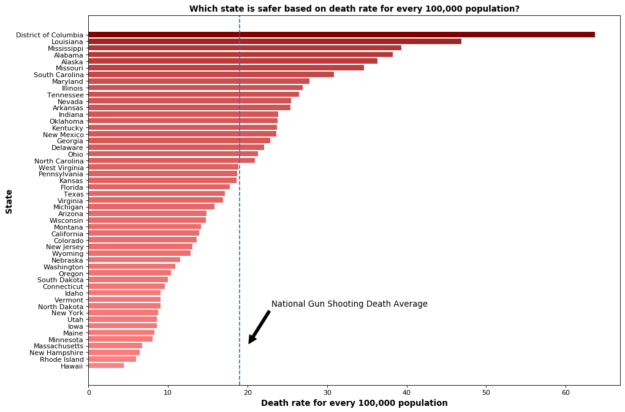

```python
# Bar chart to show which state is safer and dangerous based on death rate for every 100,000 population
df_state_pop.sort_values('Avg_Death_Rate', inplace=True,ascending=True)

likeability_scores = np.array(df_state_pop.Avg_Death_Rate)

data_normalizer = mp.colors.Normalize()
color_map = mp.colors.LinearSegmentedColormap(
    "my_map",
    {
        "red": [(0, 1.0, 1.0),
                (1.0, .5, .5)],
        "green": [(0, 0.5, 0.5),
                  (1.0, 0, 0)],
        "blue": [(0, 0.50, 0.5),
                 (1.0, 0, 0)]
    }
)


plt.figure(figsize=(14,10), dpi= 80)
plt.barh(df_state_pop.State, df_state_pop.Avg_Death_Rate, align='center',color=color_map(data_normalizer(likeability_scores)))

plt.axvline(x = df_state_pop.Avg_Death_Rate.mean(),linestyle='--')
plt.annotate('National Gun Shooting Death Average', xy=(20, 3), xytext=(23, 9),
            arrowprops=dict(facecolor='black', shrink=0.05),fontsize = 12)
plt.ylabel('State', fontsize = 12, weight = 'bold')
plt.xlabel('Death rate for every 100,000 population', fontsize = 12, weight = 'bold')
plt.title('Which state is safer based on death rate for every 100,000 population?', fontdict={'size':12},weight = 'bold')
plt.savefig("Death_state.png",dpi='figure',quality=100)
plt.show()
```

```python
df_state_pop.Avg_Death_Rate.mean()
```

```
19.037886188404936
```

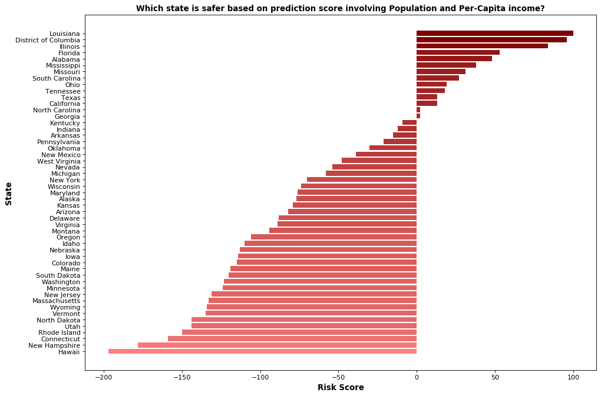

```python
# Bar chart to show which state is safer and dangerous based on involving Population and Per-Capita income
df_state_pop.sort_values('risk_score', inplace=True,ascending=True)

likeability_scores = np.array(df_state_pop.risk_score)

data_normalizer = mp.colors.Normalize()
color_map = mp.colors.LinearSegmentedColormap(
    "my_map",
    {
        "red": [(0, 1.0, 1.0),
                (1.0, .5, .5)],
        "green": [(0, 0.5, 0.5),
                  (1.0, 0, 0)],
        "blue": [(0, 0.50, 0.5),
                 (1.0, 0, 0)]
    }
)


plt.figure(figsize=(14,10), dpi= 80)
plt.barh(df_state_pop.State, df_state_pop.risk_score, align='center',color=color_map(data_normalizer(likeability_scores)))


plt.ylabel('State', fontsize = 12, weight = 'bold')
plt.xlabel('Risk Score', fontsize = 12, weight = 'bold')
plt.title('Which state is safer based on prediction score involving Population and Per-Capita income?', fontdict={'size':12},weight = 'bold')
plt.savefig("Risk_Rank_state_2.png",dpi='figure',quality=100)
plt.show()
```

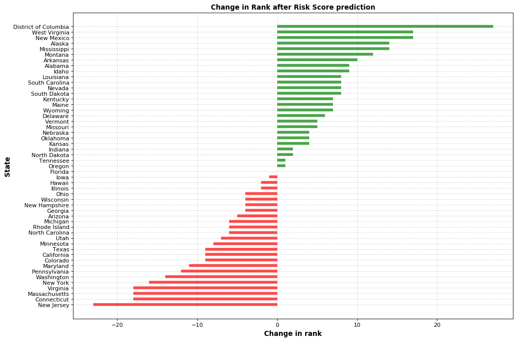

```python
# Safety ranking of USA state affect based on Risk score generated
# Prepare Data

df_state_pop['colors'] = ['red' if x < 0 else 'green' for x in df_state_pop['Rank_Change']]
df_state_pop.sort_values('Rank_Change', inplace=True)
df_state_pop.reset_index(inplace=True)
# Draw plot
plt.figure(figsize=(14,10), dpi= 80)
plt.hlines(y=df_state_pop.State, xmin=0, xmax=df_state_pop.Rank_Change, color=df_state_pop['colors'], alpha=0.7, linewidth=5)

# Decorations
plt.gca().set(ylabel='State', xlabel='Change in Rank')
plt.yticks(df_state_pop.State, fontsize=10)
plt.ylabel('State', fontsize = 12, weight = 'bold')
plt.xlabel('Change in rank', fontsize = 12, weight = 'bold')
plt.title('Change in Rank after Risk Score prediction', fontsize = 12, weight = 'bold')
plt.grid(linestyle='--', alpha=0.5)
plt.savefig("Risk_Rank_change_2.png")
plt.show()
```

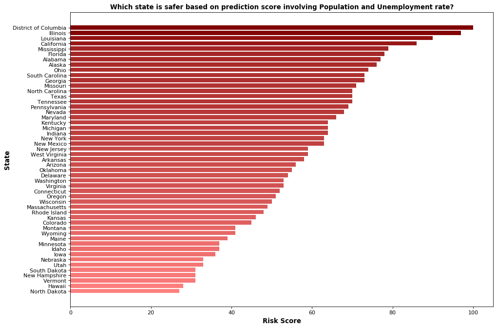

```python
# Bar chart to show which state is safer and dangerous based on involving Population and Unemployment rate
df_state_emp.sort_values('risk_score', inplace=True,ascending=True)

likeability_scores = np.array(df_state_emp.risk_score)

data_normalizer = mp.colors.Normalize()
color_map = mp.colors.LinearSegmentedColormap(
    "my_map",
    {
        "red": [(0, 1.0, 1.0),
                (1.0, .5, .5)],
        "green": [(0, 0.5, 0.5),
                  (1.0, 0, 0)],
        "blue": [(0, 0.50, 0.5),
                 (1.0, 0, 0)]
    }
)


plt.figure(figsize=(14,10), dpi= 80)
plt.barh(df_state_emp.State, df_state_emp.risk_score, align='center',color=color_map(data_normalizer(likeability_scores)))


plt.ylabel('State', fontsize = 12, weight = 'bold')
plt.xlabel('Risk Score', fontsize = 12, weight = 'bold')
plt.title('Which state is safer based on prediction score involving Population and Unemployment rate?', fontdict={'size':12},weight = 'bold')
plt.savefig("Risk_Rank_state_3.png",dpi='figure',quality=100)
plt.show()
```

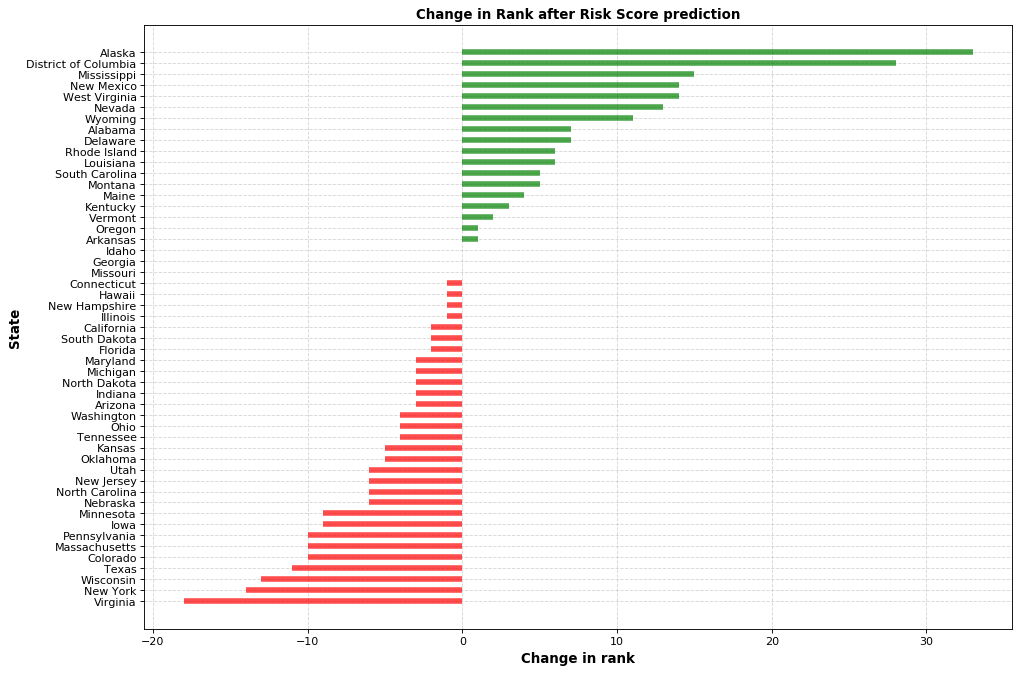

```python
# Safety ranking of USA state affect based on Risk score generated
# Prepare Data

df_state_emp['colors'] = ['red' if x < 0 else 'green' for x in df_state_emp['Rank_Change']]
df_state_emp.sort_values('Rank_Change', inplace=True)
df_state_emp.reset_index(inplace=True)
# Draw plot
plt.figure(figsize=(14,10), dpi= 80)
plt.hlines(y=df_state_emp.State, xmin=0, xmax=df_state_emp.Rank_Change, color=df_state_emp['colors'], alpha=0.7, linewidth=5)

# Decorations
plt.gca().set(ylabel='State', xlabel='Change in Rank')
plt.yticks(df_state_emp.State, fontsize=10)
plt.ylabel('State', fontsize = 12, weight = 'bold')
plt.xlabel('Change in rank', fontsize = 12, weight = 'bold')
plt.title('Change in Rank after Risk Score prediction', fontsize = 12, weight = 'bold')
plt.grid(linestyle='--', alpha=0.5)
plt.savefig("Risk_Rank_change_3.png")
plt.show()
```

```python
df_state_risk[['State','Avg_Death_Rate']].sort_values('Avg_Death_Rate',ascending=False).head(10)
```

|  | State | Avg_Death_Rate |
| --- | --- | --- |
| 23 | District of Columbia | 63.689230 |
| 41 | Louisiana | 46.908798 |
| 28 | Mississippi | 39.340840 |
| 33 | Alabama | 38.299962 |
| 11 | Alaska | 36.375923 |
| 39 | Missouri | 34.623221 |
| 38 | South Carolina | 30.901548 |
| 35 | Maryland | 27.798253 |
| 50 | Illinois | 26.928007 |
| 40 | Tennessee | 26.444073 |

```python
df_state_risk[['State','Avg_Death_Rate']].sort_values('Avg_Death_Rate',ascending=False).tail(10)
```

|  | State | Avg_Death_Rate |
| --- | --- | --- |
| 1 | North Dakota | 9.058411 |
| 44 | New York | 8.770365 |
| 10 | Utah | 8.592021 |
| 17 | Iowa | 8.585313 |
| 7 | Maine | 8.322249 |
| 19 | Minnesota | 8.086767 |
| 31 | Massachusetts | 6.765476 |
| 6 | New Hampshire | 6.417521 |
| 9 | Rhode Island | 5.965000 |
| 0 | Hawaii | 4.459587 |

```python
df_capita[['State','Avg_per_capita']].sort_values('Avg_per_capita',ascending=False).tail(10)
```

|  | State | Avg_per_capita |
| --- | --- | --- |
| 9 | Oklahoma | 47857.000000 |
| 8 | Tennessee | 47166.500000 |
| 7 | South Carolina | 46574.333333 |
| 6 | Louisiana | 45213.166667 |
| 5 | New Mexico | 44791.166667 |
| 4 | Alabama | 44526.333333 |
| 3 | Mississippi | 43633.666667 |
| 2 | Arkansas | 42756.166667 |
| 1 | Kentucky | 42702.666667 |
| 0 | West Virginia | 41960.500000 |

```python
df_capita
```

|  | State | Pop | n_killed | Avg_Death_Rate | Avg_per_capita | Avg_Un_Emp | colors | Not_Safe | More_than_per_capita | More_than_Un_Emp |
| --- | --- | --- | --- | --- | --- | --- | --- | --- | --- | --- |
| 0 | West Virginia | 1778070.0 | 335 | 18.840653 | 41960.500000 | 6.100000 | green | No | No | Yes |
| 1 | Kentucky | 4499692.0 | 1066 | 23.690510 | 42702.666667 | 5.683333 | green | Yes | No | Yes |
| 2 | Arkansas | 3038999.0 | 773 | 25.436007 | 42756.166667 | 4.916667 | green | Yes | No | No |
| 3 | Mississippi | 2989260.0 | 1176 | 39.340840 | 43633.666667 | 6.350000 | green | Yes | No | Yes |
| 4 | Alabama | 4908621.0 | 1880 | 38.299962 | 44526.333333 | 5.700000 | green | Yes | No | Yes |
| 5 | New Mexico | 2096640.0 | 495 | 23.609203 | 44791.166667 | 6.250000 | green | Yes | No | Yes |
| 6 | Louisiana | 4645184.0 | 2179 | 46.908798 | 45213.166667 | 5.916667 | green | Yes | No | Yes |
| 7 | South Carolina | 5210095.0 | 1610 | 30.901548 | 46574.333333 | 5.483333 | green | Yes | No | Yes |
| 8 | Tennessee | 6897576.0 | 1824 | 26.444073 | 47166.500000 | 5.333333 | green | Yes | No | Yes |
| 9 | Oklahoma | 3954821.0 | 941 | 23.793744 | 47857.000000 | 4.433333 | green | Yes | No | No |
| 10 | North Carolina | 10611862.0 | 2225 | 20.967103 | 48243.666667 | 5.600000 | green | Yes | No | Yes |
| 11 | Idaho | 1826156.0 | 166 | 9.090132 | 48351.000000 | 4.150000 | green | No | No | No |
| 12 | Montana | 1086759.0 | 154 | 14.170575 | 48890.333333 | 4.316667 | green | No | No | No |
| 13 | Florida | 21992985.0 | 3909 | 17.773849 | 49299.333333 | 5.266667 | green | No | No | Yes |
| 14 | Missouri | 6169270.0 | 2136 | 34.623221 | 49581.833333 | 4.883333 | green | Yes | No | No |
| 15 | Indiana | 6745354.0 | 1608 | 23.838630 | 50108.000000 | 5.000000 | green | Yes | No | No |
| 16 | Ohio | 11747694.0 | 2508 | 21.348871 | 50511.833333 | 5.450000 | green | Yes | No | Yes |
| 17 | Arizona | 7378494.0 | 1094 | 14.826874 | 50643.166667 | 5.933333 | green | No | No | Yes |
| 18 | Georgia | 10736059.0 | 2456 | 22.876178 | 50646.833333 | 5.883333 | green | Yes | No | Yes |
| 19 | Maine | 1345790.0 | 112 | 8.322249 | 50754.500000 | 4.500000 | green | No | No | No |
| 20 | District of Columbia | 720687.0 | 459 | 63.689230 | 52171.000000 | 6.850000 | green | Yes | No | Yes |
| 21 | South Dakota | 903027.0 | 90 | 9.966479 | 52345.333333 | 3.266667 | green | No | No | No |
| 22 | Nevada | 3139658.0 | 799 | 25.448632 | 52753.166667 | 6.550000 | green | Yes | No | Yes |
| 23 | Kansas | 2910357.0 | 542 | 18.623145 | 53149.000000 | 4.150000 | green | No | No | No |
| 24 | Oregon | 4301089.0 | 446 | 10.369467 | 53854.333333 | 5.550000 | green | No | No | Yes |
| 25 | Iowa | 3179849.0 | 273 | 8.585313 | 54052.833333 | 3.666667 | green | No | No | No |
| 26 | Texas | 29472295.0 | 5046 | 17.121164 | 54220.666667 | 4.750000 | green | No | No | No |
| 27 | Wisconsin | 5851754.0 | 862 | 14.730626 | 54433.166667 | 4.483333 | green | No | No | No |
| 28 | Nebraska | 1952570.0 | 225 | 11.523274 | 54688.166667 | 3.166667 | green | No | No | No |
| 29 | Pennsylvania | 12820878.0 | 2395 | 18.680468 | 55384.000000 | 5.516667 | red | No | Yes | Yes |
| 30 | Vermont | 628061.0 | 57 | 9.075552 | 55420.333333 | 3.416667 | red | No | Yes | No |
| 31 | Michigan | 10045029.0 | 1588 | 15.808814 | 55847.500000 | 5.850000 | red | No | Yes | Yes |
| 32 | Minnesota | 5700671.0 | 461 | 8.086767 | 56784.666667 | 3.850000 | red | No | Yes | No |
| 33 | Rhode Island | 1056161.0 | 63 | 5.965000 | 57975.833333 | 6.100000 | red | No | Yes | Yes |
| 34 | North Dakota | 761723.0 | 69 | 9.058411 | 58691.666667 | 2.800000 | red | No | Yes | No |
| 35 | Illinois | 12659682.0 | 3409 | 26.928007 | 59021.166667 | 6.183333 | red | Yes | Yes | Yes |
| 36 | Delaware | 982895.0 | 217 | 22.077638 | 59145.833333 | 5.016667 | red | Yes | Yes | No |
| 37 | Wyoming | 567025.0 | 73 | 12.874212 | 59405.333333 | 4.416667 | red | No | Yes | No |
| 38 | Utah | 3282115.0 | 282 | 8.592021 | 60046.500000 | 3.616667 | red | No | Yes | No |
| 39 | New York | 19440469.0 | 1705 | 8.770365 | 62261.166667 | 5.500000 | red | No | Yes | Yes |
| 40 | Colorado | 5845526.0 | 796 | 13.617252 | 62613.833333 | 4.183333 | red | No | Yes | No |
| 41 | Washington | 7797095.0 | 853 | 10.939972 | 63794.333333 | 5.533333 | red | No | Yes | Yes |
| 42 | California | 39937489.0 | 5562 | 13.926764 | 64792.166667 | 6.200000 | red | No | Yes | Yes |
| 43 | Virginia | 8626207.0 | 1459 | 16.913575 | 65071.833333 | 4.366667 | red | No | Yes | No |
| 44 | New Hampshire | 1371246.0 | 88 | 6.417521 | 67797.833333 | 3.500000 | red | No | Yes | No |
| 45 | Massachusetts | 6976597.0 | 472 | 6.765476 | 68937.833333 | 4.700000 | red | No | Yes | No |
| 46 | Hawaii | 1412687.0 | 63 | 4.459587 | 69656.500000 | 3.466667 | red | No | Yes | No |
| 47 | Alaska | 734002.0 | 267 | 36.375923 | 71080.500000 | 6.783333 | red | Yes | Yes | Yes |
| 48 | Connecticut | 3563077.0 | 341 | 9.570380 | 71775.666667 | 5.666667 | red | No | Yes | Yes |
| 49 | New Jersey | 8936574.0 | 1168 | 13.069886 | 73021.500000 | 5.750000 | red | No | Yes | Yes |
| 50 | Maryland | 6083116.0 | 1691 | 27.798253 | 74156.000000 | 5.016667 | red | Yes | Yes | No |

```python
df_capita[['State','Avg_per_capita']].sort_values('Avg_per_capita',ascending=False).head(10)
```

|  | State | Avg_per_capita |
| --- | --- | --- |
| 50 | Maryland | 74156.000000 |
| 49 | New Jersey | 73021.500000 |
| 48 | Connecticut | 71775.666667 |
| 47 | Alaska | 71080.500000 |
| 46 | Hawaii | 69656.500000 |
| 45 | Massachusetts | 68937.833333 |
| 44 | New Hampshire | 67797.833333 |
| 43 | Virginia | 65071.833333 |
| 42 | California | 64792.166667 |
| 41 | Washington | 63794.333333 |

```python
df_capita[['State','Avg_Un_Emp']].sort_values('Avg_Un_Emp',ascending=False).head(10)
```

|  | State | Avg_Un_Emp |
| --- | --- | --- |
| 20 | District of Columbia | 6.850000 |
| 47 | Alaska | 6.783333 |
| 22 | Nevada | 6.550000 |
| 3 | Mississippi | 6.350000 |
| 5 | New Mexico | 6.250000 |
| 42 | California | 6.200000 |
| 35 | Illinois | 6.183333 |
| 33 | Rhode Island | 6.100000 |
| 0 | West Virginia | 6.100000 |
| 17 | Arizona | 5.933333 |

```python
df_capita[['State','Avg_Un_Emp']].sort_values('Avg_Un_Emp',ascending=False).tail(10)
```

|  | State | Avg_Un_Emp |
| --- | --- | --- |
| 11 | Idaho | 4.150000 |
| 32 | Minnesota | 3.850000 |
| 25 | Iowa | 3.666667 |
| 38 | Utah | 3.616667 |
| 44 | New Hampshire | 3.500000 |
| 46 | Hawaii | 3.466667 |
| 30 | Vermont | 3.416667 |
| 21 | South Dakota | 3.266667 |
| 28 | Nebraska | 3.166667 |
| 34 | North Dakota | 2.800000 |

```python
df_capita.Avg_per_capita.mean()
```

```
55265.91503267975
```

```python
df_capita.Avg_Un_Emp.mean()
```

```
5.039542483660131
```

```python
#Risk score calculation involving Population, Per-Capita income and Unemployment rate
risk_harmless= .05*df_state_all['harmless_incident']
risk_fatal= .10*df_state_all['fatal_incident']
risk_Death_Rate= .25*df_state_all['Death_Rate']
risk_gun= .05*df_state_all['Guns_involved']
risk_injured= .05*df_state_all['n_injured']
risk_emp= .25*df_state_all['Avg_Un_Emp']
risk_capita= .25*df_state_all['Avg_per_capita']

risk_score=(risk_harmless+risk_fatal+risk_Death_Rate+risk_injured+risk_gun-risk_capita+risk_emp)/7
df_state_all['risk_score']=risk_score
df_state_all['risk_score']=round((df_state_all['risk_score']/max(df_state_all['risk_score']))*100)
df_state_all.sort_values('risk_score',ascending=False,inplace=True)

rank=list(range(1,52))
df_state_all['Risk_Rank']=rank


df_state_all['Rank_Change']=-(df_state_all['Risk_Rank']-df_state_all['Previous_Rank'])
```

```python
df_state_all
```

|  | State | harmless_incident | fatal_incident | n_killed_x | n_injured | Guns_involved | Previous_Rank | Pop | n_killed_y | Avg_Death_Rate | Avg_per_capita | Avg_Un_Emp | Death_Rate | Permit | High school graduate or higher | Sucide Death Rate | risk_score | Risk_Rank | Rank_Change |
| --- | --- | --- | --- | --- | --- | --- | --- | --- | --- | --- | --- | --- | --- | --- | --- | --- | --- | --- | --- |
| 23 | District of Columbia | 25.658683 | 10.936346 | 8.252427 | 10.470623 | 14.249514 | 29 | 1.804538 | 459 | 63.689230 | 70.353040 | 100.000000 | 100.000000 | 100 | 97.096774 | 23.855702 | 100.0 | 1 | 28 |
| 50 | Illinois | 60.089820 | 100.000000 | 61.290903 | 100.000000 | 79.698273 | 1 | 31.698743 | 3409 | 26.928007 | 79.590548 | 90.267640 | 42.280314 | 100 | 95.268817 | 41.892940 | 98.0 | 2 | -1 |
| 41 | Louisiana | 42.619760 | 38.812583 | 39.176555 | 32.544028 | 32.076139 | 9 | 11.631137 | 2179 | 46.908798 | 60.970342 | 86.374696 | 73.652639 | 0 | 90.645161 | 57.408844 | 94.0 | 3 | 6 |
| 28 | Mississippi | 16.931138 | 18.224782 | 21.143474 | 13.933698 | 13.683776 | 20 | 7.484847 | 1176 | 39.340840 | 58.840373 | 92.700730 | 61.770005 | 0 | 89.677419 | 52.754073 | 78.0 | 4 | 16 |
| 48 | Florida | 100.000000 | 61.652636 | 70.280475 | 52.330916 | 77.830161 | 4 | 55.068522 | 3909 | 17.773849 | 66.480572 | 76.885645 | 27.907151 | 0 | 94.193548 | 55.469356 | 76.0 | 5 | -1 |
| 33 | Alabama | 22.769461 | 29.168513 | 33.800791 | 22.184401 | 21.922329 | 14 | 12.290760 | 1880 | 38.299962 | 60.044141 | 83.211679 | 60.135697 | 0 | 91.720430 | 60.667184 | 75.0 | 6 | 8 |
| 49 | California | 94.835329 | 73.630188 | 100.000000 | 56.563564 | 100.000000 | 2 | 100.000000 | 5562 | 13.926764 | 87.372791 | 90.510949 | 21.866750 | 100 | 88.709677 | 40.884407 | 73.0 | 7 | -5 |
| 38 | South Carolina | 46.676647 | 28.215921 | 28.946422 | 22.820778 | 27.774176 | 16 | 13.045625 | 1610 | 30.901548 | 62.805887 | 80.048662 | 48.519268 | 0 | 93.010753 | 60.046548 | 67.0 | 8 | 8 |
| 46 | Ohio | 53.203593 | 49.401861 | 45.091694 | 42.200681 | 53.420944 | 5 | 29.415204 | 2508 | 21.348871 | 68.115639 | 79.562044 | 33.520378 | 0 | 96.559140 | 54.926299 | 66.0 | 9 | -4 |
| 42 | Georgia | 57.050898 | 37.763994 | 44.156778 | 30.013320 | 34.692675 | 10 | 26.882158 | 2456 | 22.876178 | 68.297688 | 85.888078 | 35.918441 | 0 | 92.795699 | 51.823119 | 65.0 | 10 | 0 |
| 40 | Tennessee | 38.113772 | 37.512923 | 32.793959 | 33.136007 | 31.557546 | 11 | 17.270931 | 1824 | 26.444073 | 63.604429 | 77.858881 | 41.520478 | 100 | 93.010753 | 61.675718 | 63.0 | 11 | 0 |
| 39 | Missouri | 33.053892 | 32.661350 | 38.403452 | 26.528045 | 28.840827 | 12 | 15.447316 | 2136 | 34.623221 | 66.861526 | 71.289538 | 54.362757 | 0 | 95.913978 | 69.666408 | 62.0 | 12 | 0 |
| 43 | North Carolina | 48.308383 | 40.702998 | 40.003596 | 34.253367 | 33.791031 | 7 | 26.571180 | 2225 | 20.967103 | 65.056997 | 81.751825 | 32.920955 | 100 | 93.440860 | 52.288596 | 62.0 | 13 | -6 |
| 47 | Texas | 74.056886 | 63.727662 | 90.722762 | 45.182773 | 57.663975 | 3 | 73.796064 | 5046 | 17.121164 | 73.117033 | 69.343066 | 26.882354 | 0 | 89.032258 | 49.961210 | 58.0 | 14 | -11 |
| 29 | Kentucky | 26.107784 | 17.818638 | 19.165768 | 14.015095 | 18.975779 | 22 | 11.266838 | 1066 | 23.690510 | 57.584911 | 82.968370 | 37.197043 | 0 | 91.612903 | 65.321955 | 57.0 | 15 | 7 |
| 45 | Pennsylvania | 44.505988 | 43.981687 | 43.060050 | 37.413053 | 41.292946 | 6 | 32.102364 | 2395 | 18.680468 | 74.685798 | 80.535280 | 29.330654 | 0 | 96.666667 | 55.779674 | 54.0 | 16 | -10 |
| 14 | New Mexico | 12.050898 | 6.202924 | 8.899676 | 4.018055 | 8.533208 | 37 | 5.249804 | 495 | 23.609203 | 60.401271 | 91.240876 | 37.069381 | 0 | 91.397849 | 89.604344 | 52.0 | 17 | 20 |
| 20 | Nevada | 8.323353 | 10.308669 | 14.365336 | 7.037147 | 9.293417 | 30 | 7.861431 | 799 | 25.448632 | 71.138096 | 95.620438 | 39.957512 | 0 | 92.258065 | 77.967417 | 51.0 | 18 | 12 |
| 37 | Indiana | 32.544910 | 27.159947 | 28.910464 | 21.873613 | 32.718487 | 18 | 16.889780 | 1608 | 23.838630 | 67.571066 | 72.992701 | 37.429610 | 0 | 94.946237 | 59.270753 | 49.0 | 19 | -1 |
| 13 | West Virginia | 11.332335 | 6.040467 | 6.023013 | 4.802427 | 6.965643 | 38 | 4.452133 | 335 | 18.840653 | 56.584093 | 89.051095 | 29.582165 | 0 | 92.365591 | 75.329713 | 48.0 | 20 | 18 |
| 11 | Alaska | 12.724551 | 3.684832 | 4.800431 | 2.404913 | 7.001002 | 41 | 1.837877 | 267 | 36.375923 | 95.852662 | 99.026764 | 57.114716 | 0 | 99.354839 | 98.060512 | 46.0 | 21 | 20 |
| 24 | Arkansas | 17.065868 | 12.568306 | 13.897878 | 9.967441 | 12.469798 | 27 | 7.609389 | 773 | 25.436007 | 57.657056 | 71.776156 | 39.937690 | 0 | 92.043011 | 72.692009 | 46.0 | 22 | 5 |
| 36 | Michigan | 38.802395 | 26.170433 | 28.550881 | 22.125203 | 30.732512 | 17 | 25.151879 | 1588 | 15.808814 | 75.310831 | 85.401460 | 24.821802 | 0 | 96.989247 | 53.917766 | 44.0 | 23 | -6 |
| 44 | New York | 64.341317 | 39.979324 | 30.654441 | 37.435252 | 47.881431 | 8 | 48.677244 | 1705 | 8.770365 | 83.959716 | 80.291971 | 13.770561 | 100 | 92.580645 | 31.342126 | 39.0 | 24 | -16 |
| 26 | Oklahoma | 21.092814 | 15.108551 | 16.918375 | 11.469587 | 17.549649 | 23 | 9.902528 | 941 | 23.793744 | 64.535574 | 64.720195 | 37.359133 | 0 | 94.086022 | 77.191621 | 37.0 | 25 | -2 |
| 22 | Arizona | 9.401198 | 12.553537 | 19.669184 | 8.110108 | 10.648830 | 24 | 18.475107 | 1094 | 14.826874 | 68.292743 | 86.618005 | 23.280033 | 0 | 93.010753 | 70.830101 | 36.0 | 26 | -2 |
| 35 | Maryland | 26.646707 | 29.670654 | 30.402733 | 23.434956 | 26.766456 | 15 | 15.231594 | 1691 | 27.798253 | 100.000000 | 73.236010 | 43.646710 | 100 | 96.559140 | 37.238169 | 31.0 | 27 | -12 |
| 30 | Wisconsin | 34.401198 | 18.379855 | 15.498022 | 15.665236 | 18.710590 | 21 | 14.652283 | 862 | 14.730626 | 73.403591 | 65.450122 | 23.128912 | 100 | 98.602151 | 56.400310 | 25.0 | 28 | -7 |
| 15 | Delaware | 11.556886 | 6.741988 | 3.901474 | 6.311973 | 7.195474 | 36 | 2.461084 | 217 | 22.077638 | 79.758662 | 73.236010 | 34.664633 | 0 | 96.021505 | 46.780450 | 25.0 | 29 | 7 |
| 18 | Oregon | 20.464072 | 6.786294 | 8.018698 | 5.135415 | 15.657965 | 34 | 10.769553 | 446 | 10.369467 | 72.623029 | 81.021898 | 16.281351 | 0 | 96.989247 | 71.528317 | 25.0 | 30 | 4 |
| 32 | New Jersey | 36.856287 | 21.599468 | 20.999640 | 18.795323 | 23.047911 | 19 | 22.376404 | 1168 | 13.069886 | 98.470117 | 83.941606 | 20.521343 | 100 | 95.913978 | 31.342126 | 21.0 | 31 | -12 |
| 34 | Virginia | 28.428144 | 29.906956 | 26.231571 | 26.387450 | 21.226943 | 13 | 21.599272 | 1459 | 16.913575 | 87.749924 | 63.746959 | 26.556413 | 0 | 95.698925 | 51.357642 | 21.0 | 32 | -19 |
| 27 | Washington | 25.718563 | 12.671688 | 15.336210 | 9.523457 | 22.370204 | 26 | 19.523248 | 853 | 10.939972 | 86.027204 | 80.778589 | 17.177114 | 100 | 97.634409 | 60.744763 | 20.0 | 33 | -7 |
| 16 | Kansas | 14.341317 | 8.765323 | 9.744696 | 6.889152 | 8.774825 | 32 | 7.287281 | 542 | 18.623145 | 71.671881 | 60.583942 | 29.240650 | 0 | 97.311828 | 68.502715 | 19.0 | 34 | -2 |
| 9 | Rhode Island | 8.502994 | 2.414710 | 1.132686 | 2.560308 | 4.125169 | 42 | 2.644535 | 63 | 5.965000 | 78.180907 | 89.051095 | 9.365790 | 100 | 93.870968 | 41.737781 | 17.0 | 35 | 7 |
| 8 | Montana | 6.047904 | 1.727957 | 2.768788 | 1.006364 | 3.918911 | 44 | 2.721150 | 154 | 14.170575 | 65.929032 | 63.017032 | 22.249563 | 0 | 100.000000 | 100.000000 | 15.0 | 36 | 8 |
| 21 | Connecticut | 25.958084 | 9.843450 | 6.130888 | 9.308865 | 15.610820 | 31 | 8.921635 | 341 | 9.570380 | 96.790100 | 82.725061 | 15.026685 | 100 | 96.989247 | 39.487975 | 10.0 | 37 | -6 |
| 7 | Maine | 10.688623 | 1.425196 | 2.013664 | 0.976765 | 4.749838 | 45 | 3.369741 | 112 | 8.322249 | 68.442877 | 65.693431 | 13.066965 | 0 | 99.032258 | 65.942591 | 10.0 | 38 | 7 |
| 25 | Colorado | 24.655689 | 11.475410 | 14.311399 | 8.383898 | 17.596794 | 28 | 14.636689 | 796 | 13.617252 | 84.435290 | 61.070560 | 21.380777 | 0 | 98.817204 | 79.208689 | 9.0 | 39 | -11 |
| 31 | Massachusetts | 62.470060 | 13.351056 | 8.486156 | 12.586947 | 33.814603 | 25 | 17.468792 | 472 | 6.765476 | 92.963258 | 68.613139 | 10.622638 | 100 | 97.096774 | 35.143522 | 9.0 | 40 | -15 |
| 5 | Idaho | 5.988024 | 1.927337 | 2.984538 | 1.102560 | 4.496435 | 43 | 4.572536 | 166 | 9.090132 | 65.201737 | 60.583942 | 14.272637 | 0 | 96.989247 | 85.802948 | 9.0 | 41 | 2 |
| 17 | Iowa | 23.607784 | 6.941368 | 4.908306 | 6.075181 | 11.190995 | 35 | 7.962065 | 273 | 8.585313 | 72.890708 | 53.527981 | 13.480008 | 100 | 98.709677 | 55.779674 | 4.0 | 42 | -7 |
| 2 | Wyoming | 5.823353 | 0.775366 | 1.312478 | 0.384786 | 1.626495 | 51 | 1.419781 | 73 | 12.874212 | 80.108600 | 64.476886 | 20.214111 | 0 | 99.784946 | 97.672614 | 4.0 | 43 | 8 |
| 19 | Minnesota | 20.494012 | 7.672427 | 8.288385 | 6.778156 | 12.782132 | 33 | 14.273985 | 461 | 8.086767 | 76.574608 | 56.204380 | 12.697229 | 100 | 99.784946 | 50.814585 | 2.0 | 44 | -11 |
| 12 | Nebraska | 13.443114 | 5.560479 | 4.045307 | 4.987420 | 7.566739 | 39 | 4.889066 | 225 | 11.523274 | 73.747460 | 46.228710 | 18.092972 | 100 | 97.741935 | 51.435221 | -1.0 | 45 | -6 |
| 3 | South Dakota | 5.583832 | 1.262738 | 1.618123 | 0.843570 | 4.042666 | 47 | 2.261101 | 90 | 9.966479 | 70.588130 | 47.688564 | 15.648610 | 0 | 98.279570 | 77.191621 | -3.0 | 46 | 1 |
| 4 | Vermont | 5.389222 | 0.827057 | 1.024811 | 0.540181 | 2.186340 | 50 | 1.572610 | 57 | 9.075552 | 74.734793 | 49.878345 | 14.249743 | 0 | 99.247312 | 68.192397 | -6.0 | 47 | 3 |
| 10 | Utah | 7.829341 | 4.054054 | 5.070119 | 2.974693 | 6.052213 | 40 | 8.218131 | 282 | 8.592021 | 80.973219 | 52.798054 | 13.490539 | 0 | 98.709677 | 85.027153 | -7.0 | 48 | -8 |
| 1 | North Dakota | 6.002994 | 1.270123 | 1.240561 | 0.961965 | 2.740291 | 48 | 1.907288 | 69 | 9.058411 | 79.146214 | 40.875912 | 14.222830 | 0 | 99.247312 | 72.614430 | -15.0 | 49 | -1 |
| 6 | New Hampshire | 11.317365 | 1.535962 | 1.582165 | 1.065562 | 5.309682 | 46 | 3.433481 | 88 | 6.417521 | 91.425958 | 51.094891 | 10.076305 | 0 | 99.784946 | 69.666408 | -18.0 | 50 | -4 |
| 0 | Hawaii | 2.514970 | 0.893516 | 1.132686 | 0.628977 | 1.314161 | 49 | 3.537245 | 63 | 4.459587 | 93.932386 | 50.608273 | 7.002105 | 100 | 98.494624 | 51.590380 | -24.0 | 51 | -2 |

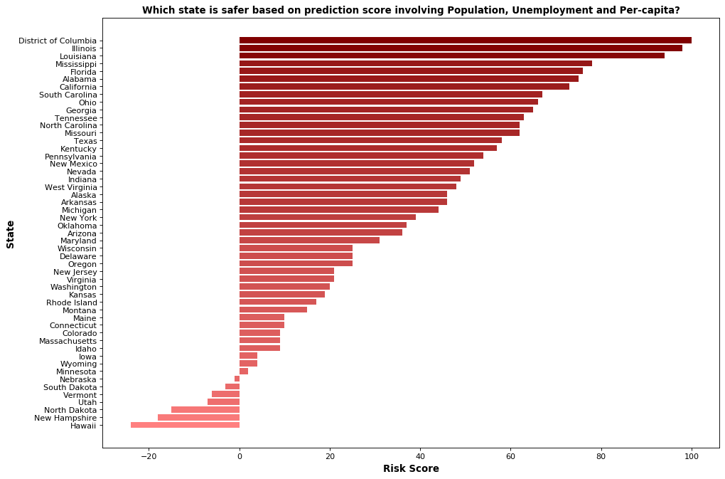

```python
# Bar chart to show which state is safer and dangerous based on involving Population, Per-Capita income and Unemployment rate
df_state_all.sort_values('risk_score', inplace=True,ascending=True)

likeability_scores = np.array(df_state_all.risk_score)

data_normalizer = mp.colors.Normalize()
color_map = mp.colors.LinearSegmentedColormap(
    "my_map",
    {
        "red": [(0, 1.0, 1.0),
                (1.0, .5, .5)],
        "green": [(0, 0.5, 0.5),
                  (1.0, 0, 0)],
        "blue": [(0, 0.50, 0.5),
                 (1.0, 0, 0)]
    }
)


plt.figure(figsize=(14,10), dpi= 80)
plt.barh(df_state_all.State, df_state_all.risk_score, align='center',color=color_map(data_normalizer(likeability_scores)))


plt.ylabel('State', fontsize = 12, weight = 'bold')
plt.xlabel('Risk Score', fontsize = 12, weight = 'bold')
plt.title('Which state is safer based on prediction score involving Population, Unemployment and Per-capita?', fontdict={'size':12},weight = 'bold')
plt.savefig("Risk_Rank_state_7.png",dpi='figure',quality=100)
plt.show()
```

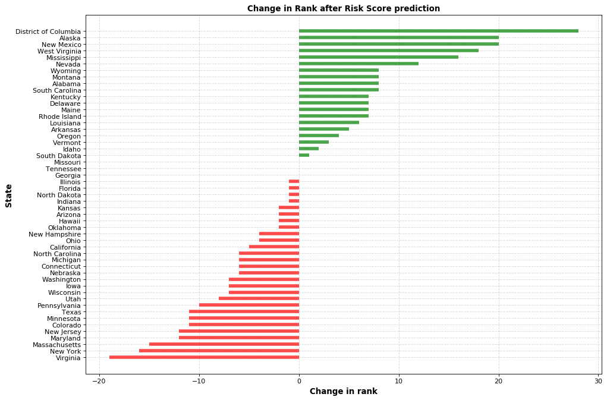

```python
# Safety ranking of USA state affect based on Risk score generated
# Prepare Data

df_state_all['colors'] = ['red' if x < 0 else 'green' for x in df_state_all['Rank_Change']]
df_state_all.sort_values('Rank_Change', inplace=True)
df_state_all.reset_index(inplace=True)
# Draw plot
plt.figure(figsize=(14,10), dpi= 80)
plt.hlines(y=df_state_all.State, xmin=0, xmax=df_state_all.Rank_Change, color=df_state_all['colors'], alpha=0.7, linewidth=5)

# Decorations
plt.gca().set(ylabel='State', xlabel='Change in Rank')
plt.yticks(df_state_all.State, fontsize=10)
plt.ylabel('State', fontsize = 12, weight = 'bold')
plt.xlabel('Change in rank', fontsize = 12, weight = 'bold')
plt.title('Change in Rank after Risk Score prediction', fontsize = 12, weight = 'bold')
plt.grid(linestyle='--', alpha=0.5)
plt.savefig("Risk_Rank_change_7.png")
plt.show()
```